# STAT364 Data Science Final Project

Removing X90 because it has the max p-value:

```r
#lmod without X90
lmod <- update(lmod, . ~ . - X90)

#lmod without X90 p-values
summary(lmod)$coefficients[,4]
```

```
##  (Intercept)          X15          X16          X17          X18          X19
## 1.910356e-04 1.066576e-03 3.905764e-05 1.645454e-04 1.762229e-03 1.512760e-01
##          X20          X22          X23          X24          X25          X26
## 6.257417e-04 3.816418e-04 1.546817e-03 5.101916e-07 3.287321e-08 1.546066e-03
##          X27          X28          X29          X30          X31          X32
## 5.464960e-08 1.239517e-05 3.477123e-07 4.620306e-05 8.674233e-05 1.096468e-07
##          X33          X34          X35          X36          X38          X40
## 4.763165e-05 7.650639e-04 1.115300e-06 7.484122e-07 7.905117e-06 2.252535e-07
##          X41          X43          X44          X45          X46           X1
## 9.149537e-06 5.707547e-06 1.768930e-02 2.653133e-03 9.402731e-06 1.734779e-04
##           X2           X3           X4           X5           X8          X10
## 1.161952e-04 7.536559e-04 3.368280e-04 5.334510e-03 1.041952e-07 1.811681e-02
##          X11          X13          X14        X16.1        X18.1        X19.1
## 3.310006e-08 5.326522e-07 4.403054e-08 1.083896e-05 1.413702e-05 5.939970e-07
##        X20.1        X21.1        X22.1        X25.1        X27.1        X28.1
## 1.709928e-06 3.179657e-05 1.891132e-06 2.327164e-03 2.881571e-05 2.116304e-04
##        X29.1        X31.1        X32.1        X33.1        X34.1        X35.1
## 8.868843e-03 1.309347e-03 9.343225e-05 7.405456e-05 1.296300e-03 6.187139e-05
##        X37.1        X38.1        X39.1        X41.1        X42.1        X43.1
## 3.854709e-03 2.287069e-07 7.515813e-05 4.859649e-05 3.224177e-02 3.512775e-02
##        X44.1          X47          X49          X50          X51          X53
## 1.501967e-02 5.970929e-02 9.453071e-03 9.002857e-03 2.831057e-08 4.805831e-03
##          X54          X56          X57          X60          X61          X63
## 6.372907e-04 6.348503e-03 1.306917e-06 1.788042e-01 4.927889e-04 1.334508e-01
##          X64          X65          X66          X68          X69          X70
## 4.904548e-04 9.556524e-03 1.219772e-01 3.800299e-03 3.054835e-01 6.671173e-02
##          X71          X72          X74          X75          X76          X78
## 1.545303e-02 4.795380e-03 1.757729e-02 1.571312e-03 1.292926e-04 1.333406e-03
##          X79          X80          X81          X84          X85          X86
## 3.727500e-04 1.035442e-02 1.273096e-03 8.596209e-02 1.596755e-04 1.942762e-02
##          X87          X89          X91          X93          X94          X99
## 9.557604e-02 2.323590e-04 4.201731e-04 5.062939e-05 5.200828e-04 5.803467e-06
##         X106         X109         X111         X112         X113         X114
## 2.141461e-06 4.793482e-03 6.111768e-06 6.461795e-05 9.624488e-04 2.407817e-05
##         X116         X119         X120         X123         X125         X126
## 3.222155e-02 1.434223e-02 1.332309e-04 2.285325e-01 2.004145e-03 8.020107e-02
##         X132         X135         X141         X142         X144         X145
## 2.254257e-08 1.143232e-03 8.206478e-02 8.429941e-01 5.666949e-02 4.397858e-01
##         X147         X148         X149         X150         X151         X154
## 5.962173e-02 9.248548e-09 1.573678e-02 7.889192e-02 3.474729e-09 2.787770e-07
```

[output cut: 15 more lines]

```
## 7.551962e-08 4.600156e-07 5.477720e-02 2.507442e-04 5.514138e-04 5.112290e-04
##         X300         X301         X302         X304         X307         X309
## 3.060022e-02 2.582549e-02 1.316752e-01 3.757717e-02 8.094338e-06 6.427995e-09
##         X310         X312         X330         X331         X334         X337
## 1.209111e-04 4.709212e-02 1.850148e-04 1.042779e-04 4.065924e-03 1.388988e-02
##         X340         X343         X344         X345         X346         X349
## 7.818334e-05 8.517896e-03 1.295181e-05 3.445555e-05 9.419321e-07 8.462103e-06
##         X352         X357         X358         X360         X376         X388
## 2.435727e-05 6.080436e-08 1.226592e-05 1.479520e-04 2.293055e-03 1.127619e-04
##         X391         X396         X397         X399         X421         X426
## 6.704790e-05 2.087775e-07 1.488148e-04 1.146168e-03 7.199586e-05 8.789463e-07
##         X427         X429         X445         X458         X459         X462
## 4.327199e-04 2.726342e-03 1.268327e-04 1.998302e-03 1.752683e-03 1.485782e-02
##         X464         X465
## 1.805078e-04 3.449709e-03
```

Finding max p-value:

```r
which.max(summary(lmod)$coefficients[,4])
```

```
## X142
##  112
```

Removing X142 because it has the max p-value:

```r
#lmod without X142
lmod <- update(lmod, . ~ . - X142)

#lmod without X142 p-values
summary(lmod)$coefficients[,4]
```

```
##  (Intercept)          X15          X16          X17          X18          X19
## 1.884289e-04 9.692476e-04 3.648119e-05 1.564071e-04 1.762935e-03 1.317438e-01
##          X20          X22          X23          X24          X25          X26
## 5.949835e-04 4.254697e-05 1.484206e-03 4.940581e-07 8.940073e-09 1.457726e-03
##          X27          X28          X29          X30          X31          X32
## 4.878385e-08 1.128700e-05 3.364115e-07 4.491375e-05 8.516791e-05 1.057453e-07
##          X33          X34          X35          X36          X38          X40
## 3.719420e-05 7.419012e-04 1.079872e-06 4.632569e-07 7.428644e-06 1.897197e-07
##          X41          X43          X44          X45          X46           X1
## 8.983126e-06 3.617512e-06 1.766121e-02 2.537393e-03 9.189485e-06 1.628574e-04
##           X2           X3           X4           X5           X8          X10
## 1.123414e-04 6.103350e-04 3.178122e-04 5.106590e-03 9.177431e-08 1.812873e-02
##          X11          X13          X14        X16.1        X18.1        X19.1
## 2.717553e-08 5.177703e-07 3.190251e-08 1.049660e-05 1.250721e-05 5.771136e-07
##        X20.1        X21.1        X22.1        X25.1        X27.1        X28.1
## 1.401958e-06 3.104126e-05 1.746057e-06 2.307654e-03 1.915409e-05 2.018971e-04
##        X29.1        X31.1        X32.1        X33.1        X34.1        X35.1
## 8.772651e-03 1.205133e-03 4.459990e-05 7.216503e-05 1.210825e-03 3.474260e-05
##        X37.1        X38.1        X39.1        X41.1        X42.1        X43.1
## 3.644881e-03 1.230822e-07 7.431761e-05 3.500295e-05 3.265693e-02 3.405209e-02
##        X44.1          X47          X49          X50          X51          X53
## 1.474926e-02 5.966946e-02 8.809987e-03 8.914408e-03 2.677032e-08 4.728170e-03
##          X54          X56          X57          X60          X61          X63
## 6.349751e-04 5.379661e-03 1.264029e-06 1.773365e-01 2.815046e-04 1.320407e-01
##          X64          X65          X66          X68          X69          X70
## 2.071857e-04 7.474251e-03 1.206800e-01 3.204513e-03 3.060292e-01 6.154759e-02
##          X71          X72          X74          X75          X76          X78
## 1.518986e-02 4.745214e-03 1.723763e-02 1.457543e-03 1.114869e-04 1.216396e-03
##          X79          X80          X81          X84          X85          X86
## 3.208524e-04 9.997492e-03 1.153455e-03 8.668824e-02 1.510585e-04 1.817090e-02
##          X87          X89          X91          X93          X94          X99
## 9.271711e-02 2.269977e-04 4.021869e-04 1.840062e-05 5.126700e-04 5.655031e-06
##         X106         X109         X111         X112         X113         X114
## 1.961332e-06 4.754067e-03 4.366597e-06 6.184372e-05 9.459184e-04 2.369595e-05
##         X116         X119         X120         X123         X125         X126
## 2.797650e-02 1.347058e-02 1.317828e-04 2.316026e-01 1.901778e-03 7.561945e-02
##         X132         X135         X141         X144         X145         X147
## 2.051494e-08 1.137742e-03 8.067124e-02 5.553119e-02 2.240055e-01 5.982099e-02
##         X148         X149         X150         X151         X154         X157
## 3.927380e-09 1.000034e-02 7.554036e-02 8.019895e-10 1.467165e-07 4.432516e-07
```

[output cut: 15 more lines]

```
## 4.384700e-07 5.428697e-02 1.771953e-04 4.081824e-04 4.997292e-04 3.086489e-02
##         X301         X302         X304         X307         X309         X310
## 2.584509e-02 1.338583e-01 3.792520e-02 7.734335e-06 1.334535e-09 1.196255e-04
##         X312         X330         X331         X334         X337         X340
## 4.698180e-02 1.837253e-04 9.862711e-05 3.735597e-03 1.339680e-02 7.739901e-05
##         X343         X344         X345         X346         X349         X352
## 7.450581e-03 1.110687e-05 3.365229e-05 7.828090e-07 7.860882e-06 2.226940e-05
##         X357         X358         X360         X376         X388         X391
## 1.944831e-08 9.725857e-06 1.463529e-04 2.294402e-03 1.104073e-04 6.562426e-05
##         X396         X397         X399         X421         X426         X427
## 1.192918e-07 1.047394e-04 1.081918e-03 7.065255e-05 6.772285e-07 2.949809e-04
##         X429         X445         X458         X459         X462         X464
## 2.440550e-03 1.195930e-04 1.803793e-03 1.513797e-03 1.495930e-02 1.791188e-04
##         X465
## 3.462400e-03
```

Finding max p-value:

```r
which.max(summary(lmod)$coefficients[,4])
```

```
## X69
##  77
```

Removing X69 because it has the max p-value:

```r
#lmod without X69
lmod <- update(lmod, . ~ . - X69)

#lmod without X69 p-values
summary(lmod)$coefficients[,4]
```

```
##  (Intercept)          X15          X16          X17          X18          X19
## 2.611216e-04 6.510985e-04 2.189376e-05 2.234168e-04 2.010182e-03 4.326354e-02
##          X20          X22          X23          X24          X25          X26
## 8.417742e-04 7.081570e-05 1.966675e-03 4.741033e-07 3.334675e-09 1.538874e-03
##          X27          X28          X29          X30          X31          X32
## 4.129635e-08 1.763888e-05 4.209031e-07 2.073433e-05 1.143496e-04 7.724101e-08
##          X33          X34          X35          X36          X38          X40
## 4.862335e-05 1.222479e-03 6.828275e-07 4.779913e-07 4.164337e-06 2.948326e-07
##          X41          X43          X44          X45          X46           X1
## 8.092029e-06 2.997250e-06 1.812504e-02 4.368334e-03 1.527839e-05 2.342716e-04
##           X2           X3           X4           X5           X8          X10
## 1.414449e-04 1.050075e-03 4.529548e-04 6.142224e-03 7.612968e-08 2.259781e-02
##          X11          X13          X14        X16.1        X18.1        X19.1
## 2.205484e-08 4.442229e-07 2.052839e-08 7.728466e-06 1.741165e-05 3.594798e-07
##        X20.1        X21.1        X22.1        X25.1        X27.1        X28.1
## 7.488444e-07 2.896759e-05 1.006295e-06 1.453038e-03 2.399916e-05 1.833494e-04
##        X29.1        X31.1        X32.1        X33.1        X34.1        X35.1
## 4.549403e-03 9.383362e-04 4.800679e-05 9.093904e-05 9.780667e-04 3.970799e-05
##        X37.1        X38.1        X39.1        X41.1        X42.1        X43.1
## 3.047671e-03 6.893593e-08 9.068344e-05 5.845783e-05 3.436529e-02 3.627245e-02
##        X44.1          X47          X49          X50          X51          X53
## 1.062056e-02 4.107218e-02 1.136530e-02 6.427761e-03 1.646981e-08 3.810683e-03
##          X54          X56          X57          X60          X61          X63
## 6.427677e-04 8.587151e-03 1.311310e-06 3.763277e-01 4.554153e-04 2.669381e-01
##          X64          X65          X66          X68          X70          X71
## 2.947378e-04 1.328708e-02 2.229102e-01 5.615106e-03 9.026528e-02 2.526060e-02
##          X72          X74          X75          X76          X78          X79
## 5.528329e-03 2.884012e-02 1.209582e-03 9.018927e-05 9.482544e-04 2.455416e-04
##          X80          X81          X84          X85          X86          X87
## 1.722637e-02 8.356730e-04 8.954789e-02 1.582083e-04 1.955544e-02 8.972033e-02
##          X89          X91          X93          X94          X99         X106
## 2.723665e-04 5.440602e-04 2.767622e-05 6.725181e-04 7.487693e-06 1.158433e-06
##         X109         X111         X112         X113         X114         X116
## 2.843108e-03 4.885407e-06 5.497328e-05 5.454418e-04 3.837711e-05 4.826074e-02
##         X119         X120         X123         X125         X126         X132
## 2.312423e-02 1.539622e-04 2.589688e-01 2.005736e-03 8.621296e-02 9.583772e-09
##         X135         X141         X144         X145         X147         X148
## 1.122724e-03 1.521140e-01 9.776824e-02 2.972303e-01 8.326047e-02 6.225731e-09
##         X149         X150         X151         X154         X157         X160
## 1.761756e-02 1.441919e-01 8.404201e-10 1.285075e-07 3.462527e-07 5.876056e-06
```

[output cut: 13 more lines]

```
## 9.404044e-03 2.814417e-10 1.823972e-09 9.545407e-09 3.985599e-08 6.018181e-07
##         X291         X293         X294         X295         X300         X301
## 9.358669e-02 2.946965e-04 6.708194e-04 5.522566e-04 3.854628e-02 2.208591e-02
##         X302         X304         X307         X309         X310         X312
## 1.458774e-01 3.232826e-02 7.922354e-06 2.123419e-09 1.204252e-04 5.636808e-02
##         X330         X331         X334         X337         X340         X343
## 1.215078e-04 7.386121e-05 2.983243e-03 1.063435e-02 1.021649e-04 6.545431e-03
##         X344         X345         X346         X349         X352         X357
## 1.736150e-05 5.522017e-05 8.168042e-07 9.568883e-06 2.607385e-05 2.729480e-08
##         X358         X360         X376         X388         X391         X396
## 6.634300e-06 1.393801e-04 2.217262e-03 1.629686e-04 9.682892e-05 1.251550e-07
##         X397         X399         X421         X426         X427         X429
## 6.630183e-05 7.935511e-04 1.042969e-04 6.162312e-07 1.874137e-04 1.621593e-03
##         X445         X458         X459         X462         X464         X465
## 1.220996e-04 3.093433e-03 2.595854e-03 1.827566e-02 2.950705e-04 5.523619e-03
```

Finding max p-value:

```r
which.max(summary(lmod)$coefficients[,4])
```

```
## X60
##  70
```

Removing X60 because it has the max p-value:

```r
#lmod without X60
lmod <- update(lmod, . ~ . - X60)

#lmod without X60 p-values
summary(lmod)$coefficients[,4]
```

```
##  (Intercept)          X15          X16          X17          X18          X19
## 2.014946e-05 7.806943e-04 3.164986e-05 5.187890e-05 8.402714e-04 4.491077e-02
##          X20          X22          X23          X24          X25          X26
## 2.690671e-04 1.211628e-05 1.062265e-03 1.906996e-07 1.564263e-11 1.353546e-03
##          X27          X28          X29          X30          X31          X32
## 3.333210e-08 1.230515e-05 5.987490e-07 2.989429e-05 1.741645e-05 9.949180e-08
##          X33          X34          X35          X36          X38          X40
## 4.377679e-05 1.724356e-04 9.788873e-07 6.105790e-07 5.985420e-06 3.095880e-08
##          X41          X43          X44          X45          X46           X1
## 8.881963e-06 3.994194e-07 1.888926e-02 2.316444e-03 3.407579e-06 1.046346e-04
##           X2           X3           X4           X5           X8          X10
## 2.128685e-05 1.562079e-03 2.317794e-04 1.272298e-03 6.287317e-08 2.360743e-02
##          X11          X13          X14        X16.1        X18.1        X19.1
## 2.130225e-08 6.206933e-07 2.685603e-08 8.716977e-06 1.008962e-05 4.964553e-07
##        X20.1        X21.1        X22.1        X25.1        X27.1        X28.1
## 1.045288e-06 3.643890e-05 1.383885e-06 1.392930e-03 8.887792e-06 2.707186e-04
##        X29.1        X31.1        X32.1        X33.1        X34.1        X35.1
## 6.382019e-03 1.387927e-03 1.593227e-05 1.477975e-05 1.432651e-03 1.332521e-05
##        X37.1        X38.1        X39.1        X41.1        X42.1        X43.1
## 4.351243e-03 9.622156e-08 3.012196e-05 1.138486e-05 2.992216e-02 4.504102e-02
##        X44.1          X47          X49          X50          X51          X53
## 1.236158e-02 5.781208e-02 1.433338e-02 9.080874e-03 1.810507e-08 5.180571e-03
##          X54          X56          X57          X61          X63          X64
## 4.718106e-04 7.723606e-03 1.038778e-06 6.611695e-04 1.914249e-03 4.335677e-04
##          X65          X66          X68          X70          X71          X72
## 2.940786e-04 3.924481e-02 9.259505e-05 7.813837e-02 3.378927e-03 6.762984e-03
##          X74          X75          X76          X78          X79          X80
## 3.937501e-03 1.200181e-03 8.511889e-05 9.595657e-04 2.690618e-04 1.648926e-03
##          X81          X84          X85          X86          X87          X89
## 8.266937e-04 1.437837e-01 1.185275e-04 5.346791e-03 8.420794e-02 4.804630e-05
##          X91          X93          X94          X99         X106         X109
## 3.781763e-04 3.453989e-05 7.063014e-04 1.498746e-06 1.549270e-06 2.673807e-03
##         X111         X112         X113         X114         X116         X119
## 2.809173e-06 7.876507e-05 7.721956e-04 1.214734e-05 4.640079e-03 1.514853e-03
##         X120         X123         X125         X126         X132         X135
## 5.615291e-05 2.250763e-01 1.181374e-03 7.209793e-02 1.109523e-08 8.621750e-04
##         X141         X144         X145         X147         X148         X149
## 7.681641e-04 5.475784e-03 3.871912e-01 1.139413e-01 7.127199e-09 3.284862e-03
##         X150         X151         X154         X157         X160         X163
## 1.307344e-01 8.633731e-10 1.327126e-07 3.902120e-07 8.431982e-06 2.389799e-04
```

[output cut: 13 more lines]

```
## 3.649749e-10 1.973393e-09 1.033358e-08 4.304202e-08 8.242873e-07 1.455253e-01
##         X293         X294         X295         X300         X301         X302
## 3.059798e-05 4.112085e-05 5.062800e-04 5.225713e-02 2.240864e-02 1.259028e-01
##         X304         X307         X309         X310         X312         X330
## 2.981737e-02 7.579611e-06 2.470000e-09 8.312229e-05 5.804962e-02 6.417706e-05
##         X331         X334         X337         X340         X343         X344
## 1.080979e-04 4.296527e-03 1.476349e-02 1.118358e-04 9.590109e-03 1.104557e-05
##         X345         X346         X349         X352         X357         X358
## 1.266400e-05 1.142988e-06 1.254759e-05 3.361021e-05 2.493910e-08 6.685915e-06
##         X360         X376         X388         X391         X396         X397
## 1.690267e-04 2.907479e-03 1.866241e-04 1.101676e-04 1.165873e-07 6.926345e-05
##         X399         X421         X426         X427         X429         X445
## 1.012206e-03 1.163709e-04 5.693181e-07 1.971707e-04 2.057172e-03 1.297589e-04
##         X458         X459         X462         X464         X465
## 3.059558e-03 1.448150e-03 1.559004e-02 1.779276e-04 3.091177e-03
```

Finding max p-value:

```r
which.max(summary(lmod)$coefficients[,4])
```

```
## X145
##  111
```

Removing X145 because it has the max p-value:

```r
#lmod without X145
lmod <- update(lmod, . ~ . - X145)

#lmod without X145 p-values
summary(lmod)$coefficients[,4]
```

```
##  (Intercept)          X15          X16          X17          X18          X19
## 2.109556e-05 1.143864e-03 4.274882e-05 5.880287e-05 1.116146e-03 6.490513e-02
##          X20          X22          X23          X24          X25          X26
## 3.039481e-04 5.974679e-06 1.168921e-03 2.577668e-07 3.902848e-12 1.137050e-03
##          X27          X28          X29          X30          X31          X32
## 4.542368e-08 1.664105e-05 5.776657e-07 3.472198e-05 2.282896e-05 1.177676e-07
##          X33          X34          X35          X36          X38          X40
## 5.089420e-05 2.330863e-04 1.325726e-06 6.731749e-07 8.096065e-06 3.517162e-08
##          X41          X43          X44          X45          X46           X1
## 6.644608e-06 1.762864e-07 1.940582e-02 2.425968e-03 4.549256e-06 1.168804e-04
##           X2           X3           X4           X5           X8          X10
## 2.012377e-05 1.968719e-03 2.586039e-04 1.154339e-03 8.609082e-08 2.739241e-02
##          X11          X13          X14        X16.1        X18.1        X19.1
## 2.905714e-08 5.934260e-07 3.328513e-08 1.080720e-05 1.405530e-05 6.834171e-07
##        X20.1        X21.1        X22.1        X25.1        X27.1        X28.1
## 9.441817e-07 4.400186e-05 1.934459e-06 1.059003e-03 1.789900e-06 3.564591e-04
##        X29.1        X31.1        X32.1        X33.1        X34.1        X35.1
## 8.601137e-03 1.770244e-03 8.403767e-06 1.319131e-05 1.790117e-03 7.646327e-06
##        X37.1        X38.1        X39.1        X41.1        X42.1        X43.1
## 5.165036e-03 9.534679e-08 2.350430e-05 1.588855e-05 1.950833e-02 5.055383e-02
##        X44.1          X47          X49          X50          X51          X53
## 1.462682e-02 5.755820e-02 1.721885e-02 9.207963e-03 2.325878e-08 5.211755e-03
##          X54          X56          X57          X61          X63          X64
## 3.513808e-04 1.105784e-02 7.381965e-07 8.168282e-04 2.173441e-03 3.553181e-04
##          X65          X66          X68          X70          X71          X72
## 1.957929e-04 4.165021e-02 8.167649e-05 2.159458e-02 3.862336e-03 7.999642e-03
##          X74          X75          X76          X78          X79          X80
## 4.673099e-03 1.636218e-03 6.569371e-05 1.338736e-03 3.035974e-04 2.047018e-03
##          X81          X84          X85          X86          X87          X89
## 1.162676e-03 1.462202e-01 2.982924e-05 6.175191e-03 8.069882e-02 4.646328e-05
##          X91          X93          X94          X99         X106         X109
## 4.096312e-04 3.378654e-05 7.786456e-04 1.986387e-06 2.169118e-06 2.038871e-03
##         X111         X112         X113         X114         X116         X119
## 4.461051e-07 1.071448e-04 1.036055e-03 9.788840e-06 2.720681e-03 7.820484e-04
##         X120         X123         X125         X126         X132         X135
## 4.639922e-05 1.599922e-01 1.602800e-03 5.336424e-02 1.493709e-08 6.402544e-04
##         X141         X144         X147         X148         X149         X150
## 6.973226e-04 4.827053e-03 1.004051e-01 4.974716e-09 3.359085e-03 8.457685e-02
##         X151         X154         X157         X160         X163         X164
## 9.375756e-10 1.320118e-07 4.770461e-07 6.577910e-06 6.237800e-05 9.073768e-04
```

[output cut: 13 more lines]

```
## 2.428270e-09 1.311375e-08 5.465633e-08 6.767525e-07 1.319725e-01 4.390553e-05
##         X294         X295         X300         X301         X302         X304
## 5.750622e-05 1.108922e-04 4.524969e-02 3.315205e-02 9.821295e-02 4.300019e-02
##         X307         X309         X310         X312         X330         X331
## 1.073913e-06 3.366248e-09 8.084323e-05 6.745198e-02 7.793305e-05 7.649254e-05
##         X334         X337         X340         X343         X344         X345
## 4.401935e-03 1.588199e-02 1.012019e-04 1.379616e-02 1.568251e-05 1.754807e-05
##         X346         X349         X352         X357         X358         X360
## 3.887612e-07 5.791956e-06 1.581048e-05 3.413827e-08 3.022848e-06 2.146416e-04
##         X376         X388         X391         X396         X397         X399
## 3.877179e-03 1.519796e-04 7.925709e-05 1.530249e-07 2.786526e-05 8.451699e-04
##         X421         X426         X427         X429         X445         X458
## 6.672347e-05 7.065531e-07 8.308047e-05 1.692668e-03 3.438555e-05 3.821724e-03
##         X459         X462         X464         X465
## 1.831679e-03 1.993009e-02 2.266743e-04 3.967960e-03
```

Finding max p-value:

```r
which.max(summary(lmod)$coefficients[,4])
```

```
## X195
##  130
```

Removing X195 because it has the max p-value:

```r
#lmod without X195
lmod <- update(lmod, . ~ . - X195)

#lmod without X195 p-values
summary(lmod)$coefficients[,4]
```

```
##  (Intercept)          X15          X16          X17          X18          X19
## 3.364370e-05 1.890213e-03 8.372526e-05 5.170250e-05 1.298711e-03 5.129099e-02
##          X20          X22          X23          X24          X25          X26
## 2.224241e-04 1.172045e-05 8.242660e-04 2.733982e-07 6.455435e-12 1.213836e-03
##          X27          X28          X29          X30          X31          X32
## 3.916282e-08 3.276497e-05 9.388291e-07 2.765133e-06 3.980425e-05 1.735148e-07
##          X33          X34          X35          X36          X38          X40
## 9.574776e-05 4.624911e-04 1.326047e-06 1.299966e-06 3.862201e-06 6.347238e-08
##          X41          X43          X44          X45          X46           X1
## 1.258369e-05 2.086192e-07 6.671489e-03 5.006875e-03 7.701669e-06 1.030470e-04
##           X2           X3           X4           X5           X8          X10
## 3.398666e-05 3.158643e-03 2.170991e-04 1.530181e-03 1.083762e-07 2.933001e-02
##          X11          X13          X14        X16.1        X18.1        X19.1
## 3.281875e-08 1.144590e-06 3.934181e-08 6.939819e-06 2.038090e-05 4.284845e-07
##        X20.1        X21.1        X22.1        X25.1        X27.1        X28.1
## 1.353484e-06 5.417843e-05 4.148326e-07 1.845439e-03 3.321754e-06 1.579109e-04
##        X29.1        X31.1        X32.1        X33.1        X34.1        X35.1
## 4.293035e-03 1.289523e-03 1.226555e-05 2.215999e-05 2.041076e-03 1.357492e-05
##        X37.1        X38.1        X39.1        X41.1        X42.1        X43.1
## 7.234300e-03 1.621741e-07 3.162593e-05 2.982630e-05 4.251977e-02 5.952853e-02
##        X44.1          X47          X49          X50          X51          X53
## 1.293733e-02 4.437459e-02 1.539624e-02 8.576576e-03 1.454630e-08 5.357936e-03
##          X54          X56          X57          X61          X63          X64
## 3.100460e-04 1.490454e-02 1.035811e-06 1.334250e-03 3.577432e-03 6.063745e-04
##          X65          X66          X68          X70          X71          X72
## 1.705300e-04 5.512475e-02 9.590972e-05 1.363072e-02 6.773969e-03 9.033953e-03
##          X74          X75          X76          X78          X79          X80
## 8.716198e-03 2.061830e-03 1.272935e-04 1.641565e-03 6.137010e-04 4.115908e-03
##          X81          X84          X85          X86          X87          X89
## 1.385901e-03 1.357915e-01 5.897907e-05 1.092400e-02 1.123065e-01 6.471685e-05
##          X91          X93          X94          X99         X106         X109
## 3.702364e-04 5.724969e-05 9.832139e-04 3.253523e-06 3.796921e-07 3.395860e-03
##         X111         X112         X113         X114         X116         X119
## 7.698080e-07 7.133636e-05 7.903442e-04 1.913036e-05 2.978072e-03 1.090873e-03
##         X120         X123         X125         X126         X132         X135
## 5.265425e-05 4.271805e-01 2.754218e-03 1.079700e-01 7.716733e-09 4.525728e-04
##         X141         X144         X147         X148         X149         X150
## 1.105903e-03 6.611489e-03 9.784991e-02 9.361033e-09 1.969697e-03 6.765306e-02
##         X151         X154         X157         X160         X163         X164
## 1.577501e-09 2.159528e-07 8.240231e-07 1.286192e-05 1.239896e-04 1.719776e-03
```

[output cut: 13 more lines]

```
## 2.433916e-08 1.031094e-07 1.258700e-06 8.420247e-02 8.311856e-05 1.119050e-04
##         X295         X300         X301         X302         X304         X307
## 1.302239e-04 8.842360e-02 1.676000e-02 2.389945e-01 2.059009e-02 1.652350e-06
##         X309         X310         X312         X330         X331         X334
## 6.340447e-09 3.324671e-05 1.337744e-01 7.322699e-05 1.357347e-04 6.162243e-03
##         X337         X340         X343         X344         X345         X346
## 1.429971e-02 1.951699e-04 1.876315e-02 2.542693e-05 2.248258e-05 6.742282e-07
##         X349         X352         X357         X358         X360         X376
## 1.006561e-05 2.437750e-05 6.265771e-08 1.035966e-06 3.978653e-04 2.316125e-03
##         X388         X391         X396         X397         X399         X421
## 2.928900e-04 1.542662e-04 2.889877e-07 1.059760e-05 1.270580e-03 1.325446e-04
##         X426         X427         X429         X445         X458         X459
## 1.330232e-06 3.164164e-05 1.586840e-03 4.985324e-05 4.783700e-03 2.629431e-03
##         X462         X464         X465
## 2.662574e-02 2.131499e-04 3.300147e-03
```

Finding max p-value:

```r
which.max(summary(lmod)$coefficients[,4])
```

```
## X123
##  104
```

Removing X123 because it has the max p-value:

```r
#lmod without X123
lmod <- update(lmod, . ~ . - X123)

#lmod without X123 p-values
summary(lmod)$coefficients[,4]
```

```
##  (Intercept)          X15          X16          X17          X18          X19
## 4.219631e-05 2.588182e-03 1.107582e-04 6.358827e-05 1.768843e-03 7.454436e-02
##          X20          X22          X23          X24          X25          X26
## 2.991258e-04 1.563029e-05 1.092040e-03 4.517568e-08 7.628898e-12 1.262971e-03
##          X27          X28          X29          X30          X31          X32
## 1.118603e-08 4.188734e-05 1.245688e-06 2.735041e-06 5.378379e-05 1.375747e-07
##          X33          X34          X35          X36          X38          X40
## 1.296556e-04 4.756876e-04 1.283690e-06 1.233875e-06 4.378123e-06 6.754632e-08
##          X41          X43          X44          X45          X46           X1
## 1.689270e-05 8.146709e-08 8.037430e-03 2.540582e-03 9.394210e-06 1.392155e-04
##           X2           X3           X4           X5           X8          X10
## 1.059750e-05 3.346600e-03 2.961782e-04 8.784906e-04 4.949668e-08 3.621256e-02
##          X11          X13          X14        X16.1        X18.1        X19.1
## 1.466172e-08 1.054988e-06 1.842253e-08 5.836443e-06 2.703116e-05 4.288586e-07
##        X20.1        X21.1        X22.1        X25.1        X27.1        X28.1
## 8.280118e-07 7.237230e-05 4.902984e-07 2.519444e-03 4.051670e-06 1.460992e-04
##        X29.1        X31.1        X32.1        X33.1        X34.1        X35.1
## 5.855729e-03 1.388051e-03 1.272409e-05 5.341812e-06 1.989015e-03 1.344011e-05
##        X37.1        X38.1        X39.1        X41.1        X42.1        X43.1
## 6.008755e-03 2.126680e-07 6.204623e-06 3.169035e-05 1.537186e-04 4.064643e-02
##        X44.1          X47          X49          X50          X51          X53
## 1.779736e-02 5.741473e-02 1.165727e-02 1.161699e-02 1.639618e-08 7.318189e-03
##          X54          X56          X57          X61          X63          X64
## 4.084637e-05 2.095675e-02 2.807597e-07 1.575831e-03 4.462174e-03 7.456181e-04
##          X65          X66          X68          X70          X71          X72
## 1.378116e-04 7.168508e-02 9.261860e-05 1.694654e-02 7.503371e-03 1.214791e-02
##          X74          X75          X76          X78          X79          X80
## 9.628662e-03 2.854597e-03 1.485713e-04 2.271466e-03 7.144234e-04 4.524697e-03
##          X81          X84          X85          X86          X87          X89
## 1.912713e-03 1.591153e-01 6.983995e-05 1.533114e-02 1.529810e-01 1.129513e-05
##          X91          X93          X94          X99         X106         X109
## 5.037827e-04 3.751789e-05 1.335157e-03 4.122236e-06 4.734542e-07 4.658312e-03
##         X111         X112         X113         X114         X116         X119
## 9.391307e-07 7.605454e-05 1.060637e-03 2.502690e-05 2.142948e-03 8.182763e-04
##         X120         X125         X126         X132         X135         X141
## 6.356683e-06 3.825209e-03 8.676996e-02 9.085611e-09 2.211346e-05 1.394827e-03
##         X144         X147         X148         X149         X150         X151
## 8.465054e-03 1.074781e-01 1.217012e-08 1.292965e-03 6.934872e-02 1.904552e-09
##         X154         X157         X160         X163         X164         X165
## 2.546101e-07 9.530424e-07 1.697324e-05 1.511281e-04 2.345265e-03 2.494656e-02
```

[output cut: 13 more lines]

```
## 7.403101e-08 1.385491e-06 7.873387e-02 9.504607e-05 1.297257e-04 1.638328e-04
##         X300         X301         X302         X304         X307         X309
## 1.005468e-01 2.045344e-02 2.805162e-01 2.643175e-02 1.654777e-06 2.319854e-09
##         X310         X312         X330         X331         X334         X337
## 3.083245e-05 7.585670e-02 9.762520e-05 1.190223e-04 8.619952e-03 2.019355e-02
##         X340         X343         X344         X345         X346         X349
## 2.621055e-04 2.157268e-02 2.974189e-05 2.511285e-05 8.859176e-07 1.279904e-05
##         X352         X357         X358         X360         X376         X388
## 2.895124e-05 1.885358e-08 1.344192e-06 3.596062e-04 2.766111e-03 3.398755e-04
##         X391         X396         X397         X399         X421         X426
## 1.791067e-04 1.108462e-07 1.415464e-05 1.520780e-03 1.593313e-04 6.119823e-07
##         X427         X429         X445         X458         X459         X462
## 4.232846e-05 2.078129e-03 3.028371e-05 6.684443e-03 3.652301e-03 2.750766e-02
##         X464         X465
## 1.896051e-04 2.241294e-03
```

Finding max p-value:

```r
which.max(summary(lmod)$coefficients[,4])
```

```
## X302
##  165
```

Removing X302 because it has the max p-value:

```r
#lmod without X302
lmod <- update(lmod, . ~ . - X302)

#lmod without X302 p-values
summary(lmod)$coefficients[,4]
```

```
##  (Intercept)          X15          X16          X17          X18          X19
## 5.354970e-05 1.882721e-03 1.858625e-04 4.550772e-05 1.962159e-03 6.843492e-02
##          X20          X22          X23          X24          X25          X26
## 1.801121e-04 2.750895e-05 7.082905e-04 7.229448e-08 1.264230e-11 1.176864e-03
##          X27          X28          X29          X30          X31          X32
## 1.750633e-08 7.325804e-05 2.135303e-06 2.861230e-06 8.784407e-05 1.529638e-07
##          X33          X34          X35          X36          X38          X40
## 2.344493e-04 8.700762e-04 8.785891e-07 2.040833e-06 2.391297e-06 8.828503e-08
##          X41          X43          X44          X45          X46           X1
## 2.962208e-05 9.904945e-08 4.872483e-03 4.277837e-03 1.481874e-05 9.708016e-05
##           X2           X3           X4           X5           X8          X10
## 1.804041e-05 1.951576e-03 2.026461e-04 1.613536e-03 7.443673e-08 4.043039e-02
##          X11          X13          X14        X16.1        X18.1        X19.1
## 2.160286e-08 1.819917e-06 3.067284e-08 5.582224e-06 4.720334e-05 3.779933e-07
##        X20.1        X21.1        X22.1        X25.1        X27.1        X28.1
## 1.437918e-06 1.299281e-04 3.792797e-07 3.648786e-03 1.364049e-06 1.025042e-04
##        X29.1        X31.1        X32.1        X33.1        X34.1        X35.1
## 3.524788e-03 1.747248e-03 2.021513e-05 8.196616e-06 2.457983e-03 2.283359e-05
##        X37.1        X38.1        X39.1        X41.1        X42.1        X43.1
## 7.651056e-03 3.239659e-07 4.524818e-06 5.670509e-05 2.604041e-04 4.681006e-02
##        X44.1          X47          X49          X50          X51          X53
## 1.877739e-02 8.358738e-02 1.069003e-02 1.905303e-02 8.897188e-09 1.194932e-02
##          X54          X56          X57          X61          X63          X64
## 2.671833e-05 2.804201e-02 1.990499e-08 9.043700e-04 4.194124e-03 4.528115e-04
##          X65          X66          X68          X70          X71          X72
## 1.986156e-04 5.274318e-02 1.591014e-04 1.627359e-02 1.333851e-02 6.801706e-03
##          X74          X75          X76          X78          X79          X80
## 1.707638e-02 1.854686e-03 2.041882e-04 1.519780e-03 9.986612e-04 8.165471e-03
##          X81          X84          X85          X86          X87          X89
## 1.287616e-03 9.335875e-02 8.641160e-05 2.093827e-02 1.844989e-01 1.852024e-05
##          X91          X93          X94          X99         X106         X109
## 4.116696e-04 1.753348e-05 1.643593e-03 6.693538e-06 3.940435e-07 6.144533e-03
##         X111         X112         X113         X114         X116         X119
## 2.783222e-07 5.958543e-05 7.371429e-04 4.196221e-05 2.683076e-03 1.248303e-03
##         X120         X125         X126         X132         X135         X141
## 5.134540e-06 2.929656e-03 8.837975e-03 3.962154e-09 9.772062e-06 1.116723e-03
##         X144         X147         X148         X149         X150         X151
## 5.524184e-03 6.548183e-02 1.881299e-08 8.610559e-04 3.644905e-02 3.171133e-09
##         X154         X157         X160         X163         X164         X165
## 4.055334e-07 1.532091e-06 1.646131e-05 1.800299e-04 3.650543e-03 3.519862e-02
```

[output cut: 13 more lines]

```
## 1.264704e-07 9.569978e-07 5.215269e-02 1.497481e-04 2.113666e-04 1.861443e-04
##         X300         X301         X304         X307         X309         X310
## 2.060160e-01 2.187149e-02 3.179157e-02 2.165971e-06 3.665625e-09 3.619293e-05
##         X312         X330         X331         X334         X337         X340
## 1.149523e-01 1.626598e-04 1.549285e-04 6.687617e-03 1.187481e-02 1.975050e-04
##         X343         X344         X345         X346         X349         X352
## 2.559243e-02 4.067967e-05 3.832721e-05 4.777663e-07 9.966069e-06 2.049822e-05
##         X357         X358         X360         X376         X388         X391
## 3.126649e-08 6.140762e-07 5.036517e-04 1.582849e-03 4.691761e-04 2.431722e-04
##         X396         X397         X399         X421         X426         X427
## 1.923165e-07 3.927993e-06 8.537465e-04 2.058751e-04 1.039962e-06 9.820520e-06
##         X429         X445         X458         X459         X462         X464
## 8.011607e-04 4.272386e-05 8.436712e-03 5.222015e-03 3.876074e-02 3.014203e-04
##         X465
## 3.612120e-03
```

Finding max p-value:

```r
which.max(summary(lmod)$coefficients[,4])
```

```
## X300
##  163
```

Removing X300 because it has the max p-value:

```r
#lmod without X300
lmod <- update(lmod, . ~ . - X300)

#lmod without X300 p-values
summary(lmod)$coefficients[,4]
```

```
##  (Intercept)          X15          X16          X17          X18          X19
## 2.670722e-06 3.167980e-03 2.968770e-04 3.077482e-06 1.002875e-03 9.444368e-02
##          X20          X22          X23          X24          X25          X26
## 1.174005e-05 1.366898e-06 5.926250e-05 8.863557e-08 5.490432e-12 9.726419e-06
##          X27          X28          X29          X30          X31          X32
## 2.603757e-08 1.013006e-05 9.304422e-08 3.712996e-06 1.479592e-04 2.802112e-07
##          X33          X34          X35          X36          X38          X40
## 4.132070e-04 1.079395e-03 1.265643e-06 3.978698e-06 4.042584e-06 7.029946e-08
##          X41          X43          X44          X45          X46           X1
## 1.850819e-05 1.177369e-07 2.670668e-03 9.221976e-03 2.908369e-05 1.017751e-05
##           X2           X3           X4           X5           X8          X10
## 3.412317e-05 4.596118e-03 2.561716e-05 3.025225e-03 9.641927e-08 8.318158e-02
##          X11          X13          X14        X16.1        X18.1        X19.1
## 3.253371e-08 3.834615e-06 4.825284e-08 7.785997e-06 9.769320e-05 6.146149e-07
##        X20.1        X21.1        X22.1        X25.1        X27.1        X28.1
## 1.970489e-06 2.779963e-04 7.567346e-07 8.649067e-04 2.983421e-06 1.463628e-04
##        X29.1        X31.1        X32.1        X33.1        X34.1        X35.1
## 2.638517e-03 1.451273e-03 3.784534e-05 1.657184e-05 2.875794e-03 3.971514e-05
##        X37.1        X38.1        X39.1        X41.1        X42.1        X43.1
## 1.091108e-02 3.299682e-07 9.974781e-06 1.004709e-05 5.449032e-04 7.418318e-02
##        X44.1          X47          X49          X50          X51          X53
## 2.067760e-02 1.394698e-01 2.031176e-02 3.817987e-02 1.758411e-08 2.491814e-02
##          X54          X56          X57          X61          X63          X64
## 5.982814e-05 1.166589e-02 3.721625e-08 2.104678e-03 7.439001e-03 1.025230e-03
##          X65          X66          X68          X70          X71          X72
## 4.242227e-04 1.033482e-01 3.098907e-04 2.412753e-02 1.628599e-02 1.565314e-02
##          X74          X75          X76          X78          X79          X80
## 2.010454e-02 3.834891e-03 3.566913e-04 3.187682e-03 1.343282e-03 9.798303e-03
##          X81          X84          X85          X86          X87          X89
## 2.728270e-03 2.462880e-01 1.835269e-04 6.200006e-03 1.080644e-01 3.781617e-05
##          X91          X93          X94          X99         X106         X109
## 8.271276e-05 3.700206e-05 2.703749e-03 1.118543e-05 7.986334e-07 1.336245e-03
##         X111         X112         X113         X114         X116         X119
## 6.065611e-07 1.018686e-04 6.201601e-04 6.064698e-05 5.224367e-03 2.316844e-03
##         X120         X125         X126         X132         X135         X141
## 1.124583e-05 8.939420e-04 1.077430e-02 7.901062e-09 2.053378e-05 2.543200e-03
##         X144         X147         X148         X149         X150         X151
## 1.311904e-02 1.648902e-01 3.587166e-08 1.687236e-03 8.565683e-02 5.721986e-09
##         X154         X157         X160         X163         X164         X165
## 8.819616e-07 3.046197e-06 3.657820e-05 3.863264e-04 7.040980e-04 1.643295e-02
```

[output cut: 11 more lines]

```
## 9.208056e-03 2.180092e-03 2.363102e-02 1.927676e-09 1.005220e-08 6.429020e-08
##         X286         X289         X291         X293         X294         X295
## 2.680419e-07 2.058905e-06 1.267321e-01 4.394665e-05 1.478945e-04 1.505085e-04
##         X301         X304         X307         X309         X310         X312
## 2.161386e-02 3.388104e-02 1.756316e-06 6.613266e-09 6.142053e-06 2.535389e-01
##         X330         X331         X334         X337         X340         X343
## 3.491942e-04 2.089152e-04 9.355857e-03 1.164393e-02 2.096670e-04 5.758043e-02
##         X344         X345         X346         X349         X352         X357
## 9.117899e-05 7.771264e-05 1.015885e-06 2.220178e-05 4.516592e-05 6.054585e-08
##         X358         X360         X376         X388         X391         X396
## 8.758724e-08 1.153168e-03 3.268800e-04 1.040959e-03 5.505581e-04 4.168432e-07
##         X397         X399         X421         X426         X427         X429
## 9.142370e-07 9.001727e-04 4.719269e-04 2.025826e-06 3.125247e-06 6.583472e-04
##         X445         X458         X459         X462         X464         X465
## 3.282606e-05 3.936773e-03 4.058047e-03 7.821563e-02 5.843301e-04 6.688624e-03
```

Finding max p-value:

```r
which.max(summary(lmod)$coefficients[,4])
```

```
## X312
##  168
```

Removing X312 because it has the max p-value:

```r
#lmod without X312
lmod <- update(lmod, . ~ . - X312)

#lmod without X312 p-values
summary(lmod)$coefficients[,4]
```

```
##  (Intercept)          X15          X16          X17          X18          X19
## 3.800289e-06 3.915037e-03 5.080566e-04 3.652523e-06 1.491802e-03 1.805710e-02
##          X20          X22          X23          X24          X25          X26
## 1.366493e-05 4.494880e-07 6.679184e-05 1.638419e-07 9.103835e-12 4.431697e-06
##          X27          X28          X29          X30          X31          X32
## 4.754729e-08 1.894134e-06 1.486864e-07 7.057466e-06 1.738176e-04 3.901753e-07
##          X33          X34          X35          X36          X38          X40
## 1.822768e-04 1.833633e-03 2.390884e-06 2.858233e-06 7.616952e-06 1.307397e-07
##          X41          X43          X44          X45          X46           X1
## 8.282051e-06 1.342025e-07 8.044475e-04 1.906455e-02 5.596681e-05 1.305886e-05
##           X2           X3           X4           X5           X8          X10
## 6.422431e-05 9.029159e-03 3.285609e-05 4.792394e-03 1.342211e-07 1.276573e-01
##          X11          X13          X14        X16.1        X18.1        X19.1
## 4.814255e-08 3.195072e-06 7.461206e-08 5.271714e-06 1.494981e-04 1.150289e-06
##        X20.1        X21.1        X22.1        X25.1        X27.1        X28.1
## 2.955896e-06 3.703296e-04 1.407378e-06 4.026403e-04 5.638472e-06 1.658639e-04
##        X29.1        X31.1        X32.1        X33.1        X34.1        X35.1
## 2.137219e-03 1.080159e-03 6.445760e-05 3.106887e-05 2.055228e-03 7.168162e-05
##        X37.1        X38.1        X39.1        X41.1        X42.1        X43.1
## 6.232795e-03 5.541979e-07 1.863983e-05 1.911424e-06 4.878549e-04 2.773219e-02
##        X44.1          X47          X49          X50          X51          X53
## 3.230585e-02 1.517682e-01 6.951989e-03 4.593273e-02 3.015732e-08 3.158996e-02
##          X54          X56          X57          X61          X63          X64
## 1.145066e-04 1.636409e-03 6.807549e-08 4.012194e-03 3.861955e-03 1.938961e-03
##          X65          X66          X68          X70          X71          X72
## 7.639508e-04 5.772394e-02 4.804365e-04 2.796338e-02 1.528761e-02 1.890169e-02
##          X74          X75          X76          X78          X79          X80
## 1.795528e-02 4.038477e-03 6.110043e-04 3.019629e-03 1.932995e-03 8.597733e-03
##          X81          X84          X85          X86          X87          X89
## 2.306999e-03 2.829791e-01 3.446150e-04 1.794579e-03 4.112105e-02 6.289736e-05
##          X91          X93          X94          X99         X106         X109
## 1.048389e-04 2.704781e-05 4.317055e-03 9.929789e-06 1.471299e-06 6.691320e-04
##         X111         X112         X113         X114         X116         X119
## 1.122047e-06 1.681134e-04 7.387206e-04 1.168813e-04 9.577779e-03 4.487913e-03
##         X120         X125         X126         X132         X135         X141
## 1.890637e-05 1.761757e-03 4.198864e-03 1.353768e-08 3.690164e-05 2.003286e-03
##         X144         X147         X148         X149         X150         X151
## 1.159398e-02 2.049481e-01 6.610102e-08 3.099419e-03 1.382333e-01 1.029354e-08
##         X154         X157         X160         X163         X164         X165
## 1.532813e-06 4.635784e-06 6.963427e-05 7.238655e-04 1.455561e-04 4.669292e-03
```

[output cut: 11 more lines]

```
## 1.897900e-02 3.923235e-03 4.923331e-02 1.639869e-09 1.733176e-08 1.130203e-07
##         X286         X289         X291         X293         X294         X295
## 4.052918e-07 2.630604e-06 1.485478e-01 7.372671e-06 4.969529e-05 2.329355e-04
##         X301         X304         X307         X309         X310         X330
## 3.587256e-02 4.960811e-02 3.279348e-06 1.974814e-09 7.653877e-06 3.622794e-04
##         X331         X334         X337         X340         X343         X344
## 2.921905e-04 1.556734e-02 1.748919e-02 4.514995e-05 1.004332e-01 1.760826e-04
##         X345         X346         X349         X352         X357         X358
## 1.498385e-04 1.854944e-06 3.166351e-05 5.323721e-05 9.852203e-08 8.635330e-08
##         X360         X376         X388         X391         X396         X397
## 4.406428e-04 3.620560e-04 1.576310e-03 8.138335e-04 7.152019e-07 6.207941e-07
##         X399         X421         X426         X427         X429         X445
## 1.766220e-03 6.891379e-04 2.777445e-06 1.963265e-06 1.194398e-03 6.323082e-05
##         X458         X459         X462         X464         X465
## 1.018743e-03 1.823555e-03 1.639271e-01 1.100846e-03 1.328779e-02
```

Finding max p-value:

```r
which.max(summary(lmod)$coefficients[,4])
```

```
## X84
##  86
```

Removing X84 because it has the max p-value:

```r
#lmod without X84
lmod <- update(lmod, . ~ . - X84)

#lmod without X84 p-values
summary(lmod)$coefficients[,4]
```

```
##  (Intercept)          X15          X16          X17          X18          X19
## 1.497207e-06 5.874608e-03 2.283827e-04 6.017021e-06 7.104492e-04 2.123280e-02
##          X20          X22          X23          X24          X25          X26
## 2.366206e-05 2.556914e-09 1.192694e-04 2.397548e-07 1.403947e-11 7.349017e-06
##          X27          X28          X29          X30          X31          X32
## 5.504571e-08 7.222485e-07 2.281785e-07 8.153464e-06 2.571180e-05 5.458288e-07
##          X33          X34          X35          X36          X38          X40
## 1.711140e-04 1.883367e-04 2.439173e-06 3.011125e-06 7.845831e-06 3.957612e-08
##          X41          X43          X44          X45          X46           X1
## 1.461202e-05 2.311369e-07 1.329763e-03 5.180735e-03 7.021351e-05 2.297626e-05
##           X2           X3           X4           X5           X8          X10
## 7.358214e-05 7.560153e-03 5.754057e-05 5.005848e-03 1.976738e-07 2.231090e-01
##          X11          X13          X14        X16.1        X18.1        X19.1
## 5.630741e-08 5.221736e-06 6.795670e-08 8.889723e-06 2.618666e-04 1.514232e-06
##        X20.1        X21.1        X22.1        X25.1        X27.1        X28.1
## 2.436881e-06 6.042612e-04 2.130844e-06 7.309036e-04 6.141652e-06 2.578054e-04
##        X29.1        X31.1        X32.1        X33.1        X34.1        X35.1
## 3.877778e-03 1.343932e-03 1.152192e-04 3.720235e-05 2.456136e-03 1.260046e-04
##        X37.1        X38.1        X39.1        X41.1        X42.1        X43.1
## 7.407333e-03 8.043220e-07 1.456692e-05 6.032091e-07 3.355821e-04 3.726815e-02
##        X44.1          X47          X49          X50          X51          X53
## 6.355237e-02 2.926598e-01 1.118930e-02 9.065507e-02 5.085844e-08 6.180110e-02
##          X54          X56          X57          X61          X63          X64
## 4.732958e-05 8.940064e-04 6.752232e-08 2.243566e-03 6.572368e-03 9.655561e-04
##          X65          X66          X68          X70          X71          X72
## 1.388443e-03 1.081661e-01 8.566320e-04 4.951652e-02 1.899695e-02 1.111130e-04
##          X74          X75          X76          X78          X79          X80
## 2.177839e-02 2.240602e-04 4.577608e-04 3.878423e-04 1.042817e-03 1.081815e-02
##          X81          X85          X86          X87          X89          X91
## 4.157824e-04 4.438468e-04 2.282401e-04 1.327387e-02 7.431952e-05 1.810848e-04
##          X93          X94          X99         X106         X109         X111
## 1.135589e-05 8.069337e-03 4.145786e-06 2.449849e-06 1.221166e-03 9.408507e-07
##         X112         X113         X114         X116         X119         X120
## 2.596245e-04 1.301242e-03 2.051335e-04 1.762254e-02 8.130684e-03 1.535590e-05
##         X125         X126         X132         X135         X141         X144
## 3.105445e-03 1.007551e-03 2.258410e-08 1.883842e-05 2.261083e-03 1.060087e-02
##         X147         X148         X149         X150         X151         X154
## 4.195993e-01 9.914574e-08 5.419414e-03 2.811928e-01 1.735292e-08 1.600936e-06
##         X157         X160         X163         X164         X165         X168
## 3.497976e-06 1.146334e-04 9.033223e-04 1.462182e-05 1.158491e-03 1.177627e-05
```

[output cut: 11 more lines]

```
## 7.321544e-03 7.615657e-02 2.653095e-09 2.023544e-08 7.639717e-08 1.958611e-07
##         X289         X291         X293         X294         X295         X301
## 4.293263e-06 3.204345e-01 7.592004e-06 5.208857e-05 8.954585e-05 6.361825e-02
##         X304         X307         X309         X310         X330         X331
## 7.964455e-02 4.072955e-06 2.725333e-09 5.506766e-06 1.419425e-04 4.143067e-04
##         X334         X337         X340         X343         X344         X345
## 2.969415e-02 3.307182e-02 3.590546e-05 7.518691e-02 1.247727e-04 1.276192e-04
##         X346         X349         X352         X357         X358         X360
## 2.900302e-06 4.160998e-05 6.608064e-05 6.862945e-08 1.026551e-07 6.480556e-04
##         X376         X388         X391         X396         X397         X399
## 5.848664e-04 1.688696e-03 8.044199e-04 2.341197e-07 8.329191e-07 2.892865e-03
##         X421         X426         X427         X429         X445         X458
## 6.495325e-04 6.726493e-07 2.937189e-06 2.107134e-03 1.075590e-04 1.489543e-03
##         X459         X462         X464         X465
## 2.636312e-03 2.068095e-01 8.662977e-04 1.296681e-02
```

Finding max p-value:

```r
which.max(summary(lmod)$coefficients[,4])
```

```
## X147
##  109
```

Removing X147 because it has the max p-value:

```r
#lmod without X147
lmod <- update(lmod, . ~ . - X147)

#lmod without X147 p-values
summary(lmod)$coefficients[,4]
```

```
##  (Intercept)          X15          X16          X17          X18          X19
## 2.528555e-07 2.086561e-03 8.381647e-05 7.003704e-07 7.632106e-04 6.594168e-03
##          X20          X22          X23          X24          X25          X26
## 3.785695e-06 3.967750e-10 2.788248e-05 3.034341e-08 4.113481e-12 9.175005e-07
##          X27          X28          X29          X30          X31          X32
## 8.370492e-09 5.197403e-07 5.221292e-09 3.287796e-06 4.267253e-06 2.371748e-08
##          X33          X34          X35          X36          X38          X40
## 9.410476e-05 1.203506e-04 2.255686e-07 9.140517e-07 1.288296e-06 2.979549e-09
##          X41          X43          X44          X45          X46           X1
## 1.044290e-06 1.119985e-08 1.002664e-04 4.130183e-03 8.405798e-06 3.011113e-06
##           X2           X3           X4           X5           X8          X10
## 3.234791e-05 2.660096e-03 9.101838e-06 2.875453e-03 3.162306e-08 1.807539e-01
##          X11          X13          X14        X16.1        X18.1        X19.1
## 1.034891e-08 1.243713e-07 1.355546e-08 5.216958e-07 1.167213e-04 1.222880e-07
##        X20.1        X21.1        X22.1        X25.1        X27.1        X28.1
## 5.697423e-07 1.466235e-04 3.042556e-07 1.128149e-04 7.167275e-07 1.122819e-05
##        X29.1        X31.1        X32.1        X33.1        X34.1        X35.1
## 5.436185e-04 8.689718e-04 6.277820e-05 1.425033e-05 1.643559e-03 9.067825e-05
##        X37.1        X38.1        X39.1        X41.1        X42.1        X43.1
## 5.977050e-03 5.052979e-07 8.286960e-06 5.868529e-07 4.533901e-04 4.018362e-02
##        X44.1          X47          X49          X50          X51          X53
## 3.649907e-02 2.158753e-01 1.108832e-02 4.582108e-02 9.420096e-09 2.505843e-02
##          X54          X56          X57          X61          X63          X64
## 5.358513e-05 1.227412e-03 2.955257e-08 4.864141e-04 7.656651e-03 1.835978e-04
##          X65          X66          X68          X70          X71          X72
## 9.630167e-04 1.600019e-01 5.059930e-04 1.696465e-02 1.364293e-02 2.406437e-08
##          X74          X75          X76          X78          X79          X80
## 1.592240e-02 2.894712e-07 4.235071e-04 1.313671e-06 1.078742e-03 7.948802e-03
##          X81          X85          X86          X87          X89          X91
## 2.477673e-06 2.986357e-04 1.266986e-04 1.111794e-02 2.378821e-05 3.466295e-05
##          X93          X94          X99         X106         X109         X111
## 1.007380e-05 3.597786e-03 4.107243e-07 3.810168e-07 2.094209e-04 1.166476e-07
##         X112         X113         X114         X116         X119         X120
## 1.175825e-05 1.410872e-04 4.706809e-05 1.661418e-02 7.517892e-03 6.348161e-06
##         X125         X126         X132         X135         X141         X144
## 1.038591e-03 1.051526e-03 4.253558e-09 1.598654e-05 7.069185e-04 5.511211e-03
##         X148         X149         X150         X151         X154         X157
## 8.736758e-09 4.734499e-03 2.262516e-01 7.237535e-09 1.145277e-06 2.985585e-06
##         X160         X163         X164         X165         X168         X172
## 3.486818e-05 5.547243e-04 1.087317e-05 1.188850e-03 1.029109e-05 8.814338e-08
```

[output cut: 11 more lines]

```
## 6.227638e-02 7.697495e-10 1.151108e-08 5.564086e-08 1.588351e-07 1.738665e-06
##         X291         X293         X294         X295         X301         X304
## 5.470222e-01 9.833312e-06 6.419165e-05 1.039756e-04 3.501727e-02 4.892432e-02
##         X307         X309         X310         X330         X331         X334
## 2.461411e-06 1.526189e-09 5.996935e-06 1.440111e-05 7.342519e-05 2.168034e-02
##         X337         X340         X343         X344         X345         X346
## 1.940427e-02 3.282383e-06 7.737376e-02 1.395199e-05 1.505783e-05 1.103328e-06
##         X349         X352         X357         X358         X360         X376
## 2.456252e-05 4.536974e-05 5.587099e-08 5.847777e-08 2.103876e-04 4.744014e-05
##         X388         X391         X396         X397         X399         X421
## 1.293116e-03 6.302455e-04 2.068001e-07 4.286134e-07 1.887768e-03 5.179265e-04
##         X426         X427         X429         X445         X458         X459
## 6.111696e-07 1.409040e-06 1.331517e-03 4.545031e-05 1.914419e-03 3.137741e-03
##         X462         X464         X465
## 1.507077e-01 7.998071e-04 1.211627e-02
```

Finding max p-value:

```r
which.max(summary(lmod)$coefficients[,4])
```

```
## X291
##  157
```

Removing X291 because it has the max p-value:

```r
#lmod without X291
lmod <- update(lmod, . ~ . - X291)

#lmod without X291 p-values
summary(lmod)$coefficients[,4]
```

```
##  (Intercept)          X15          X16          X17          X18          X19
## 2.107959e-08 2.491947e-03 9.682681e-05 1.304141e-08 8.981512e-04 5.206778e-03
##          X20          X22          X23          X24          X25          X26
## 4.476365e-08 1.857213e-10 1.903554e-07 3.013981e-08 3.178215e-12 1.884720e-08
##          X27          X28          X29          X30          X31          X32
## 9.141203e-09 8.981544e-08 5.494309e-10 2.650725e-06 4.536350e-06 7.753065e-09
##          X33          X34          X35          X36          X38          X40
## 8.932128e-05 7.555939e-05 6.034867e-08 8.371914e-07 4.457224e-07 5.292237e-11
##          X41          X43          X44          X45          X46           X1
## 1.804804e-07 1.147062e-11 4.511533e-05 1.726214e-03 4.762218e-07 1.868044e-08
##           X2           X3           X4           X5           X8          X10
## 2.110447e-05 4.332242e-04 4.344030e-08 2.079367e-03 3.458996e-08 6.361536e-02
##          X11          X13          X14        X16.1        X18.1        X19.1
## 1.147205e-08 1.545123e-08 1.533356e-08 1.989961e-07 2.769655e-05 3.280035e-08
##        X20.1        X21.1        X22.1        X25.1        X27.1        X28.1
## 6.468871e-07 1.263386e-05 1.174017e-07 4.772079e-05 8.771935e-14 2.269312e-06
##        X29.1        X31.1        X32.1        X33.1        X34.1        X35.1
## 6.140645e-05 9.592253e-04 6.639646e-05 9.442849e-06 1.851115e-03 9.802074e-05
##        X37.1        X38.1        X39.1        X41.1        X42.1        X43.1
## 6.878529e-03 5.718913e-07 6.242081e-06 4.214720e-07 4.912612e-04 4.817423e-02
##        X44.1          X47          X49          X50          X51          X53
## 2.292945e-02 1.520670e-01 1.221573e-02 1.982183e-02 8.111618e-09 7.939648e-03
##          X54          X56          X57          X61          X63          X64
## 4.930015e-05 5.267833e-04 2.826013e-08 8.987765e-05 7.670733e-03 3.540917e-05
##          X65          X66          X68          X70          X71          X72
## 7.922416e-04 2.000060e-01 3.177428e-04 2.058303e-02 9.468834e-03 2.195803e-08
##          X74          X75          X76          X78          X79          X80
## 1.151058e-02 3.299346e-07 3.901707e-04 1.519412e-06 8.505424e-04 5.883765e-03
##          X81          X85          X86          X87          X89          X91
## 2.850543e-06 3.298089e-04 1.381551e-04 1.068726e-02 2.107156e-05 1.165207e-07
##          X93          X94          X99         X106         X109         X111
## 2.307541e-06 1.116700e-04 4.012896e-07 1.637754e-07 9.069412e-05 4.631245e-14
##         X112         X113         X114         X116         X119         X120
## 1.628711e-06 3.327131e-06 1.055243e-07 1.710960e-02 7.593958e-03 5.731904e-06
##         X125         X126         X132         X135         X141         X144
## 6.759278e-04 1.147153e-03 3.799750e-09 1.331466e-05 8.367093e-04 6.351646e-03
##         X148         X149         X150         X151         X154         X157
## 6.640667e-09 4.787832e-03 1.099374e-01 4.095319e-09 7.609133e-07 1.666571e-06
##         X160         X163         X164         X165         X168         X172
## 3.882678e-06 5.990069e-04 1.083170e-05 9.480082e-04 2.303685e-06 5.768014e-09
```

[output cut: 11 more lines]

```
## 8.188317e-03 5.131049e-10 8.173245e-09 3.469665e-08 9.063791e-08 3.427334e-07
##         X293         X294         X295         X301         X304         X307
## 6.895183e-06 7.085163e-05 7.817833e-05 3.463158e-02 5.220489e-02 3.929186e-07
##         X309         X310         X330         X331         X334         X337
## 1.292567e-09 4.454151e-06 1.365627e-05 2.993556e-05 1.385663e-02 1.231818e-02
##         X340         X343         X344         X345         X346         X349
## 2.440276e-06 7.547354e-02 1.054456e-06 2.987425e-06 4.734211e-07 1.372058e-05
##         X352         X357         X358         X360         X376         X388
## 2.143869e-05 4.702535e-08 2.700729e-08 2.364179e-04 2.923494e-05 1.033524e-03
##         X391         X396         X397         X399         X421         X426
## 4.514363e-04 1.538661e-07 1.965998e-07 1.585253e-03 3.293015e-04 4.151952e-07
##         X427         X429         X445         X458         X459         X462
## 5.149446e-07 1.145746e-03 3.580783e-06 9.261303e-04 2.358742e-03 1.783491e-01
##         X464         X465
## 3.796448e-04 1.084896e-02
```

Finding max p-value:

```r
which.max(summary(lmod)$coefficients[,4])
```

```
## X66
##  74
```

Removing X66 because it has the max p-value:

```r
#lmod without X66
lmod <- update(lmod, . ~ . - X66)

#lmod without X66 p-values
summary(lmod)$coefficients[,4]
```

```
##  (Intercept)          X15          X16          X17          X18          X19
## 4.337890e-08 5.751819e-03 2.012011e-04 2.523408e-08 1.569927e-03 1.240150e-02
##          X20          X22          X23          X24          X25          X26
## 8.578132e-08 9.985273e-11 3.091046e-07 3.298990e-08 6.193361e-12 2.259347e-08
##          X27          X28          X29          X30          X31          X32
## 1.271015e-08 1.906790e-07 2.368424e-10 3.817313e-06 8.812884e-06 3.767638e-09
##          X33          X34          X35          X36          X38          X40
## 1.155809e-04 1.630063e-04 4.326064e-08 1.220902e-06 2.374601e-07 1.051153e-10
##          X41          X43          X44          X45          X46           X1
## 8.128702e-08 1.846555e-11 2.189502e-05 2.221364e-03 5.431845e-07 2.836291e-08
##           X2           X3           X4           X5           X8          X10
## 2.505465e-05 2.137783e-04 6.112926e-08 2.415940e-03 4.028705e-08 6.103454e-02
##          X11          X13          X14        X16.1        X18.1        X19.1
## 1.572149e-08 9.487836e-09 2.383705e-08 1.346974e-07 1.943310e-05 3.209984e-08
##        X20.1        X21.1        X22.1        X25.1        X27.1        X28.1
## 9.344640e-07 3.766589e-06 8.864477e-08 2.685173e-05 9.151700e-14 1.703266e-06
##        X29.1        X31.1        X32.1        X33.1        X34.1        X35.1
## 9.872164e-05 1.244961e-03 4.414894e-06 1.105237e-05 2.262237e-03 2.097683e-06
##        X37.1        X38.1        X39.1        X41.1        X42.1        X43.1
## 7.786288e-03 1.835180e-07 7.533076e-06 2.562176e-07 2.608233e-04 5.218627e-02
##        X44.1          X47          X49          X50          X51          X53
## 3.192855e-03 4.768722e-02 1.343379e-02 3.947977e-03 6.711767e-09 1.458167e-03
##          X54          X56          X57          X61          X63          X64
## 5.617533e-05 8.654212e-04 2.712548e-08 6.259304e-05 3.338820e-08 3.056494e-05
##          X65          X68          X70          X71          X72          X74
## 2.999266e-05 2.008572e-04 1.145496e-02 1.877643e-02 1.370781e-08 2.296149e-02
##          X75          X76          X78          X79          X80          X81
## 3.027181e-07 4.483908e-04 1.676997e-06 1.096109e-03 1.162979e-02 3.770812e-06
##          X85          X86          X87          X89          X91          X93
## 2.829416e-04 1.708946e-07 3.036647e-03 2.668047e-05 1.266927e-07 1.128179e-07
##          X94          X99         X106         X109         X111         X112
## 1.002172e-04 7.316058e-07 1.371230e-07 5.246689e-05 5.520046e-14 1.525094e-06
##         X113         X114         X116         X119         X120         X125
## 5.425436e-06 1.859472e-08 6.035543e-05 2.573322e-05 7.749876e-06 9.973108e-05
##         X126         X132         X135         X141         X144         X148
## 1.622044e-03 3.010716e-09 1.711856e-05 2.798758e-07 3.970169e-05 5.641406e-09
##         X149         X150         X151         X154         X157         X160
## 7.906352e-05 3.160302e-02 4.136610e-09 8.667470e-07 2.141964e-06 7.099757e-06
##         X163         X164         X165         X168         X172         X175
## 4.697345e-04 4.503909e-09 3.189686e-05 3.517940e-07 3.824710e-09 8.523855e-07
```

[output cut: 11 more lines]

```
## 5.023432e-10 8.068890e-09 4.241078e-08 1.209582e-07 6.686528e-07 8.301349e-06
##         X294         X295         X301         X304         X307         X309
## 8.164444e-05 1.256580e-04 1.936440e-02 4.252934e-02 4.838312e-07 9.647113e-10
##         X310         X330         X331         X334         X337         X340
## 2.351913e-06 1.676984e-05 1.350836e-05 8.315731e-03 7.436515e-03 3.086129e-06
##         X343         X344         X345         X346         X349         X352
## 7.587242e-02 2.098974e-06 4.642769e-06 6.002890e-07 2.095283e-05 3.092783e-05
##         X357         X358         X360         X376         X388         X391
## 4.323220e-08 2.266439e-08 3.039629e-04 4.008901e-05 1.628296e-03 7.117190e-04
##         X396         X397         X399         X421         X426         X427
## 1.888788e-07 1.865914e-07 1.961220e-03 5.266945e-04 5.611463e-07 5.129748e-07
##         X429         X445         X458         X459         X462         X464
## 1.304867e-03 3.514230e-06 2.078469e-03 5.594752e-03 1.811837e-01 3.417435e-04
##         X465
## 7.767997e-03
```

Finding max p-value:

```r
which.max(summary(lmod)$coefficients[,4])
```

```
## X462
##  191
```

Removing X462 because it has the max p-value:

```r
#lmod without X462
lmod <- update(lmod, . ~ . - X462)

#lmod without X462 p-values
summary(lmod)$coefficients[,4]
```

```
##  (Intercept)          X15          X16          X17          X18          X19
## 4.941704e-08 1.036655e-02 2.179120e-04 2.450193e-08 3.123861e-03 2.571870e-02
##          X20          X22          X23          X24          X25          X26
## 7.429481e-08 1.954442e-10 2.678466e-07 7.405654e-08 1.376219e-11 3.031211e-09
##          X27          X28          X29          X30          X31          X32
## 2.714090e-08 4.557225e-07 2.510686e-10 9.055648e-06 2.156458e-05 7.763902e-09
##          X33          X34          X35          X36          X38          X40
## 2.375906e-04 3.493470e-04 9.059754e-08 2.803125e-06 4.989427e-07 2.263518e-10
##          X41          X43          X44          X45          X46           X1
## 2.205080e-08 4.139919e-11 5.441420e-05 2.932886e-03 1.261948e-06 2.329060e-08
##           X2           X3           X4           X5           X8          X10
## 5.906681e-05 2.629829e-04 5.042643e-08 4.443215e-03 8.762204e-08 1.182482e-01
##          X11          X13          X14        X16.1        X18.1        X19.1
## 3.288157e-08 9.279980e-09 5.573232e-08 2.115860e-07 4.817136e-05 7.342291e-08
##        X20.1        X21.1        X22.1        X25.1        X27.1        X28.1
## 2.006541e-06 9.190232e-06 2.045125e-07 1.361375e-05 1.133573e-13 3.560121e-06
##        X29.1        X31.1        X32.1        X33.1        X34.1        X35.1
## 1.563693e-04 2.548012e-03 5.580908e-06 2.652758e-05 4.380851e-03 3.092976e-06
##        X37.1        X38.1        X39.1        X41.1        X42.1        X43.1
## 1.431086e-02 3.662959e-07 1.720130e-05 5.972915e-07 3.195544e-04 8.826743e-02
##        X44.1          X47          X49          X50          X51          X53
## 4.970193e-03 7.133443e-02 2.461367e-02 7.071453e-03 1.587757e-08 2.626387e-03
##          X54          X56          X57          X61          X63          X64
## 1.220333e-04 2.046205e-03 5.388440e-08 8.982330e-05 7.650641e-08 4.672420e-05
##          X65          X68          X70          X71          X72          X74
## 3.663802e-05 2.621687e-04 1.125890e-02 2.200999e-02 2.931406e-08 2.523591e-02
##          X75          X76          X78          X79          X80          X81
## 6.799667e-07 8.074681e-04 3.991323e-06 1.709524e-03 1.210125e-02 9.172919e-06
##          X85          X86          X87          X89          X91          X93
## 5.406914e-04 2.272768e-07 1.837836e-03 6.294220e-05 1.158508e-07 2.860090e-08
##          X94          X99         X106         X109         X111         X112
## 2.052140e-04 1.755684e-06 3.177423e-07 3.240002e-05 5.266149e-14 3.293972e-06
##         X113         X114         X116         X119         X120         X125
## 9.198534e-06 4.317870e-08 7.808558e-05 4.486491e-05 1.722326e-05 1.772081e-04
##         X126         X132         X135         X141         X144         X148
## 4.159887e-03 6.912509e-09 3.759118e-05 6.720317e-07 7.384605e-05 7.231221e-09
##         X149         X150         X151         X154         X157         X160
## 5.253382e-05 1.747749e-02 6.116912e-09 1.524605e-06 3.434505e-06 7.237520e-06
##         X163         X164         X165         X168         X172         X175
## 8.808974e-04 5.785768e-09 1.454918e-05 6.026145e-08 3.830187e-09 1.154189e-06
```

[output cut: 9 more lines]

```
## 9.526285e-06 6.743275e-10 6.779140e-10 7.367715e-03 8.443971e-06 1.539314e-03
##         X277         X280         X283         X286         X289         X293
## 4.329330e-10 7.705704e-09 4.610662e-08 1.348880e-07 3.271742e-07 1.755187e-05
##         X294         X295         X301         X304         X307         X309
## 1.116022e-04 1.773575e-04 3.150231e-02 6.617259e-02 9.214460e-07 6.664796e-10
##         X310         X330         X331         X334         X337         X340
## 3.639001e-06 3.600285e-05 3.198975e-05 9.491542e-03 1.039441e-02 1.352675e-06
##         X343         X344         X345         X346         X349         X352
## 3.832739e-02 3.546785e-06 1.136845e-05 1.266273e-06 3.874370e-05 5.001520e-05
##         X357         X358         X360         X376         X388         X391
## 3.187512e-08 4.664606e-08 5.756646e-04 9.894689e-05 2.763340e-03 1.179886e-03
##         X396         X397         X399         X421         X426         X427
## 1.724032e-07 3.612831e-07 1.481854e-03 8.681622e-04 5.569996e-07 9.571599e-07
##         X429         X445         X458         X459         X464         X465
## 1.522033e-03 7.337510e-06 4.108621e-03 8.609496e-03 5.153804e-04 2.019982e-02
```

Finding max p-value:

```r
which.max(summary(lmod)$coefficients[,4])
```

```
## X10
##  36
```

Removing X10 because it has the max p-value:

```r
#lmod without X10
lmod <- update(lmod, . ~ . - X10)

#lmod without X10 p-values
summary(lmod)$coefficients[,4]
```

```
##  (Intercept)          X15          X16          X17          X18          X19
## 1.054601e-07 1.336737e-02 2.159053e-05 2.407603e-08 4.198732e-03 1.744292e-02
##          X20          X22          X23          X24          X25          X26
## 4.736335e-08 2.320914e-10 9.160678e-08 1.349025e-07 5.144178e-12 8.550325e-09
##          X27          X28          X29          X30          X31          X32
## 2.968550e-08 3.017244e-07 8.160807e-11 6.651543e-06 1.210850e-05 1.631792e-08
##          X33          X34          X35          X36          X38          X40
## 5.258993e-05 5.376149e-04 3.025522e-07 1.291421e-07 1.670071e-06 6.970588e-10
##          X41          X43          X44          X45          X46           X1
## 1.136395e-09 1.293630e-10 3.045808e-05 2.080284e-03 2.598681e-06 1.666764e-08
##           X2           X3           X4           X5           X8          X11
## 1.309971e-04 1.176641e-04 2.177091e-08 8.164370e-03 9.385967e-08 2.618674e-08
##          X13          X14        X16.1        X18.1        X19.1        X20.1
## 1.597323e-09 9.634698e-09 1.548272e-07 1.577688e-04 1.865953e-07 4.159798e-08
##        X21.1        X22.1        X25.1        X27.1        X28.1        X29.1
## 2.638100e-05 4.541828e-07 7.759053e-08 3.173591e-13 4.761261e-06 5.368206e-04
##        X31.1        X32.1        X33.1        X34.1        X35.1        X37.1
## 1.990971e-03 1.355008e-05 6.005499e-05 2.411257e-03 8.230261e-06 8.129141e-03
##        X38.1        X39.1        X41.1        X42.1        X43.1        X44.1
## 9.878123e-07 3.743247e-05 4.101593e-07 4.160119e-04 9.440718e-02 1.457680e-02
##          X47          X49          X50          X51          X53          X54
## 1.393251e-01 2.754469e-02 1.594758e-02 2.443534e-08 5.820790e-03 2.010360e-04
##          X56          X57          X61          X63          X64          X65
## 3.377536e-04 1.706431e-07 3.979928e-05 3.714047e-09 2.459119e-05 9.536489e-05
##          X68          X70          X71          X72          X74          X75
## 6.773358e-04 1.546053e-02 4.662705e-02 1.392276e-08 5.357005e-02 4.877753e-07
##          X76          X78          X79          X80          X81          X85
## 1.370015e-03 2.436471e-06 2.320787e-03 2.713750e-02 5.046856e-06 1.125089e-03
##          X86          X87          X89          X91          X93          X94
## 2.742357e-07 2.640553e-03 1.275852e-04 1.814180e-08 3.299933e-09 9.419485e-10
##          X99         X106         X109         X111         X112         X113
## 2.300724e-06 5.493626e-07 2.238966e-07 1.158761e-13 6.062071e-06 3.190335e-05
##         X114         X116         X119         X120         X125         X126
## 1.433979e-07 1.977876e-04 1.331314e-04 3.584433e-05 5.497319e-04 8.558339e-03
##         X132         X135         X141         X144         X148         X149
## 5.971751e-09 7.088057e-05 4.779606e-09 6.541886e-06 1.600955e-08 8.315842e-05
##         X150         X151         X154         X157         X160         X163
## 7.668930e-03 1.237624e-08 2.779378e-06 5.142058e-06 8.684967e-06 1.821496e-03
##         X164         X165         X168         X172         X175         X178
## 8.829983e-09 3.148641e-05 9.759720e-09 9.937496e-10 5.497202e-07 6.915842e-07
```

[output cut: 9 more lines]

```
## 1.757969e-09 1.796407e-10 1.768271e-02 2.408576e-05 5.138704e-03 8.106231e-10
##         X280         X283         X286         X289         X293         X294
## 1.158686e-08 4.687345e-08 1.077601e-07 1.520013e-07 2.192687e-05 2.173717e-04
##         X295         X301         X304         X307         X309         X310
## 3.317919e-04 5.151529e-02 9.464197e-02 3.150783e-06 1.206454e-09 7.271411e-06
##         X330         X331         X334         X337         X340         X343
## 1.744277e-05 1.044461e-04 3.548273e-02 3.681607e-02 3.707604e-07 6.090561e-02
##         X344         X345         X346         X349         X352         X357
## 3.374489e-06 1.036346e-05 2.695752e-06 5.925413e-05 6.791494e-05 3.542027e-08
##         X358         X360         X376         X388         X391         X396
## 9.384076e-08 1.025409e-03 1.205173e-04 4.492806e-03 1.978607e-03 9.923185e-08
##         X397         X399         X421         X426         X427         X429
## 4.793000e-07 3.273517e-03 1.488379e-03 2.315658e-07 1.066638e-06 3.037574e-03
##         X445         X458         X459         X464         X465
## 1.690333e-05 5.551740e-03 1.462468e-02 7.708400e-04 2.373349e-02
```

Finding max p-value:

```r
which.max(summary(lmod)$coefficients[,4])
```

```
## X47
##  61
```

Removing X47 because it has the max p-value:

```r
#lmod without X47
lmod <- update(lmod, . ~ . - X47)

#lmod without X47 p-values
summary(lmod)$coefficients[,4]
```

```
##  (Intercept)          X15          X16          X17          X18          X19
## 5.525273e-08 6.463921e-03 3.882673e-07 1.897754e-08 3.948476e-05 1.567738e-02
##          X20          X22          X23          X24          X25          X26
## 2.772359e-08 5.646849e-10 1.077461e-07 3.032009e-07 1.359525e-11 2.483696e-08
##          X27          X28          X29          X30          X31          X32
## 6.733746e-08 6.001615e-07 1.312703e-10 1.647978e-05 3.327466e-06 4.462082e-08
##          X33          X34          X35          X36          X38          X40
## 7.400773e-05 3.235185e-06 8.495123e-07 3.399643e-07 4.162905e-06 1.589490e-09
##          X41          X43          X44          X45          X46           X1
## 2.841784e-10 1.156578e-10 9.360992e-05 2.064483e-03 1.196261e-06 3.256600e-08
##           X2           X3           X4           X5           X8          X11
## 7.426098e-05 2.427874e-05 4.794540e-08 8.417596e-03 1.604403e-07 5.064853e-08
##          X13          X14        X16.1        X18.1        X19.1        X20.1
## 3.233374e-09 2.451514e-08 4.546317e-07 4.944566e-04 4.310839e-07 1.221397e-07
##        X21.1        X22.1        X25.1        X27.1        X28.1        X29.1
## 1.348584e-06 9.989350e-07 7.265397e-08 1.903960e-14 1.442496e-05 6.733779e-05
##        X31.1        X32.1        X33.1        X34.1        X35.1        X37.1
## 1.510973e-03 2.763013e-05 3.837795e-05 1.909426e-03 2.332896e-05 6.571678e-03
##        X38.1        X39.1        X41.1        X42.1        X43.1        X44.1
## 2.795898e-06 1.356905e-05 8.917481e-07 2.194495e-04 6.569287e-02 1.282116e-02
##          X49          X50          X51          X53          X54          X56
## 2.215140e-02 1.432833e-06 6.813275e-08 2.136928e-05 2.164929e-05 4.216572e-04
##          X57          X61          X63          X64          X65          X68
## 4.751452e-07 4.546422e-06 5.860287e-10 2.326143e-06 6.790347e-05 7.551613e-05
##          X70          X71          X72          X74          X75          X76
## 1.865440e-02 2.430842e-03 2.858778e-08 3.053941e-03 5.871964e-07 8.957453e-04
##          X78          X79          X80          X81          X85          X86
## 1.944651e-06 1.961637e-03 1.408683e-03 2.771978e-06 6.428209e-04 5.892667e-07
##          X87          X89          X91          X93          X94          X99
## 5.475119e-03 1.217856e-04 5.302178e-08 6.706937e-09 1.480484e-09 2.161399e-06
##         X106         X109         X111         X112         X113         X114
## 1.133486e-06 2.909850e-07 3.300093e-15 1.743093e-05 1.866032e-06 2.902530e-07
##         X116         X119         X120         X125         X126         X132
## 5.429490e-04 3.655752e-04 1.663144e-05 1.624720e-03 8.111382e-03 1.662161e-08
##         X135         X141         X144         X148         X149         X150
## 7.703877e-06 5.833248e-09 1.495653e-05 1.496882e-08 2.499434e-04 1.527897e-02
##         X151         X154         X157         X160         X163         X164
## 1.251779e-08 2.336692e-06 5.082039e-06 1.047834e-06 1.263022e-03 2.475700e-08
##         X165         X168         X172         X175         X178         X186
## 8.836939e-05 1.030246e-08 2.057259e-09 1.639227e-06 1.152832e-06 4.760306e-15
```

[output cut: 9 more lines]

```
## 6.519967e-12 6.058175e-03 6.667643e-07 1.214676e-02 1.094506e-09 1.791186e-08
##         X283         X286         X289         X293         X294         X295
## 7.094436e-08 1.649497e-07 2.513268e-08 6.655950e-05 6.657761e-04 3.767251e-04
##         X301         X304         X307         X309         X310         X330
## 1.127022e-01 1.344648e-01 7.577095e-06 1.919693e-09 2.207660e-05 5.336265e-05
##         X331         X334         X337         X340         X343         X344
## 3.150880e-04 6.027975e-02 5.724023e-02 9.580046e-07 9.752608e-02 1.527200e-06
##         X345         X346         X349         X352         X357         X358
## 3.276960e-06 6.540354e-06 8.071750e-05 8.043756e-05 6.132803e-08 2.581071e-07
##         X360         X376         X388         X391         X396         X397
## 2.537552e-03 2.929247e-04 4.763833e-03 2.161061e-03 1.689183e-07 1.027702e-06
##         X399         X421         X426         X427         X429         X445
## 5.564219e-03 1.588821e-03 3.884619e-07 1.709153e-06 4.623801e-03 4.881273e-05
##         X458         X459         X464         X465
## 1.542246e-02 4.205252e-02 3.685107e-04 1.622994e-02
```

Finding max p-value:

```r
which.max(summary(lmod)$coefficients[,4])
```

```
## X304
##  158
```

Removing X304 because it has the max p-value:

```r
#lmod without X304
lmod <- update(lmod, . ~ . - X304)

#lmod without X304 p-values
summary(lmod)$coefficients[,4]
```

```
##  (Intercept)          X15          X16          X17          X18          X19
## 1.266029e-07 9.663135e-03 9.998037e-07 4.847432e-08 1.250619e-04 1.133080e-02
##          X20          X22          X23          X24          X25          X26
## 6.801438e-08 1.380947e-09 2.334419e-07 7.837376e-07 3.023606e-11 3.636423e-08
##          X27          X28          X29          X30          X31          X32
## 1.517223e-07 1.407591e-06 1.941839e-10 4.797925e-05 9.299557e-06 6.086408e-08
##          X33          X34          X35          X36          X38          X40
## 2.118725e-04 8.875296e-06 8.573194e-07 1.035048e-06 7.593429e-06 4.398161e-09
##          X41          X43          X44          X45          X46           X1
## 7.183383e-10 1.525515e-10 2.990004e-04 3.631066e-03 3.680453e-06 7.222491e-08
##           X2           X3           X4           X5           X8          X11
## 2.216698e-04 6.909947e-05 9.963664e-08 1.908643e-02 4.728103e-07 1.326921e-07
##          X13          X14        X16.1        X18.1        X19.1        X20.1
## 6.356345e-09 6.774167e-08 4.942451e-07 1.531925e-03 1.763156e-07 3.698823e-07
##        X21.1        X22.1        X25.1        X27.1        X28.1        X29.1
## 3.999592e-06 1.153884e-06 1.810640e-07 5.868414e-15 2.402520e-05 2.081291e-04
##        X31.1        X32.1        X33.1        X34.1        X35.1        X37.1
## 3.067234e-03 4.288274e-05 1.149206e-04 3.282147e-03 3.257562e-05 8.873830e-03
##        X38.1        X39.1        X41.1        X42.1        X43.1        X44.1
## 5.614544e-06 4.049703e-05 2.324077e-06 4.040093e-04 7.761308e-02 1.997266e-02
##          X49          X50          X51          X53          X54          X56
## 3.614116e-02 4.371640e-06 6.717057e-08 6.154948e-05 4.511927e-05 6.091818e-04
##          X57          X61          X63          X64          X65          X68
## 9.721940e-07 1.330313e-05 1.311342e-10 6.843929e-06 1.469840e-04 2.198235e-04
##          X70          X71          X72          X74          X75          X76
## 2.849242e-02 7.524675e-03 5.953620e-08 9.440886e-03 1.420174e-06 1.435891e-03
##          X78          X79          X80          X81          X85          X86
## 4.850324e-06 2.649393e-03 4.419350e-03 6.875780e-06 1.262453e-03 1.640738e-06
##          X87          X89          X91          X93          X94          X99
## 1.226422e-02 3.647722e-04 9.389851e-08 1.125401e-08 1.555505e-09 6.422307e-06
##         X106         X109         X111         X112         X113         X114
## 1.481867e-06 6.922033e-07 1.211210e-15 2.784664e-05 4.429435e-06 8.258576e-07
##         X116         X119         X120         X125         X126         X132
## 5.795443e-04 4.667801e-04 5.058307e-05 2.851588e-03 8.134954e-03 2.831308e-08
##         X135         X141         X144         X148         X149         X150
## 1.904016e-05 7.234384e-09 2.591559e-05 4.325700e-08 2.829655e-04 1.244473e-02
##         X151         X154         X157         X160         X163         X164
## 3.262795e-08 5.244430e-06 9.627104e-06 3.186821e-06 2.942353e-03 7.458366e-08
##         X165         X168         X172         X175         X178         X186
## 2.609575e-04 2.360707e-08 4.496776e-09 1.740285e-06 5.114993e-07 3.285221e-15
```

[output cut: 9 more lines]

```
## 1.221320e-11 1.987665e-02 1.998923e-06 1.090635e-02 3.120644e-09 5.366176e-08
##         X283         X286         X289         X293         X294         X295
## 1.874291e-07 3.671297e-07 7.571876e-08 1.501689e-04 1.517815e-03 4.831761e-07
##         X301         X307         X309         X310         X330         X331
## 5.892111e-01 3.302998e-08 5.534620e-09 2.315237e-06 1.697878e-04 6.635335e-04
##         X334         X337         X340         X343         X344         X345
## 1.150093e-01 1.397514e-01 2.771759e-06 2.666197e-01 4.342156e-06 1.018736e-05
##         X346         X349         X352         X357         X358         X360
## 1.145276e-06 9.302258e-06 2.303561e-06 1.829896e-07 1.665396e-07 6.306056e-03
##         X376         X388         X391         X396         X397         X399
## 7.155444e-04 1.861030e-03 4.396215e-04 4.047405e-07 1.035067e-06 7.551458e-03
##         X421         X426         X427         X429         X445         X458
## 2.038168e-04 7.290053e-07 2.125968e-06 6.700264e-03 2.330005e-07 2.270837e-02
##         X459         X464         X465
## 6.180307e-02 1.096977e-03 3.410744e-02
```

Finding max p-value:

```r
which.max(summary(lmod)$coefficients[,4])
```

```
## X301
##  157
```

Removing X301 because it has the max p-value:

```r
#lmod without X301
lmod <- update(lmod, . ~ . - X301)

#lmod without X301 p-values
summary(lmod)$coefficients[,4]
```

```
##  (Intercept)          X15          X16          X17          X18          X19
## 1.289252e-07 1.098245e-02 8.976686e-07 4.554571e-08 1.144541e-04 1.028513e-02
##          X20          X22          X23          X24          X25          X26
## 5.939729e-08 1.345644e-09 1.471700e-07 7.809444e-07 2.307310e-11 1.326330e-08
##          X27          X28          X29          X30          X31          X32
## 1.145469e-07 1.394481e-06 9.761244e-11 2.829587e-05 4.700341e-06 5.784940e-08
##          X33          X34          X35          X36          X38          X40
## 1.831684e-04 2.450851e-06 9.399229e-07 6.922044e-07 8.417003e-06 2.518062e-09
##          X41          X43          X44          X45          X46           X1
## 2.726912e-10 1.510458e-10 3.032066e-04 3.209954e-03 3.363673e-06 6.027379e-08
##           X2           X3           X4           X5           X8          X11
## 2.328202e-04 6.723573e-05 8.036811e-08 2.125406e-02 3.751890e-07 8.997746e-08
##          X13          X14        X16.1        X18.1        X19.1        X20.1
## 3.156053e-09 3.867878e-08 3.938879e-07 5.352612e-04 1.141187e-07 2.403374e-07
##        X21.1        X22.1        X25.1        X27.1        X28.1        X29.1
## 1.061176e-06 1.013161e-06 5.361557e-08 5.753459e-15 2.090700e-05 1.962228e-04
##        X31.1        X32.1        X33.1        X34.1        X35.1        X37.1
## 2.030424e-03 4.013363e-05 1.198754e-04 2.184890e-03 3.596412e-05 5.914202e-03
##        X38.1        X39.1        X41.1        X42.1        X43.1        X44.1
## 6.150217e-06 4.335304e-05 2.340289e-06 4.492829e-04 5.606710e-02 2.320680e-02
##          X49          X50          X51          X53          X54          X56
## 2.669309e-02 3.474551e-06 4.211058e-08 5.951018e-05 5.087588e-05 6.192960e-04
##          X57          X61          X63          X64          X65          X68
## 5.580081e-07 1.217697e-05 1.411959e-10 5.949069e-06 1.031119e-04 1.102377e-04
##          X70          X71          X72          X74          X75          X76
## 3.291371e-02 3.696983e-03 4.651540e-08 4.690233e-03 9.799350e-07 1.066862e-03
##          X78          X79          X80          X81          X85          X86
## 2.977419e-06 1.861552e-03 2.076738e-03 3.866799e-06 1.099638e-03 1.381164e-06
##          X87          X89          X91          X93          X94          X99
## 8.583030e-03 3.996759e-04 6.509014e-08 1.052030e-08 8.351787e-10 2.567464e-06
##         X106         X109         X111         X112         X113         X114
## 1.196899e-06 1.956438e-07 1.137260e-15 2.764620e-05 3.679196e-06 8.966816e-07
##         X116         X119         X120         X125         X126         X132
## 6.173926e-04 5.289106e-04 5.541003e-05 3.242885e-03 7.384815e-03 1.985637e-08
##         X135         X141         X144         X148         X149         X150
## 2.130917e-05 7.414150e-09 2.684423e-05 3.171438e-08 2.781334e-04 1.116714e-02
##         X151         X154         X157         X160         X163         X164
## 1.203203e-08 2.499876e-06 4.357774e-06 2.248239e-06 2.554084e-03 7.837934e-08
##         X165         X168         X172         X175         X178         X186
## 2.081078e-04 2.220927e-08 2.358556e-09 1.379488e-06 1.633766e-07 2.996315e-15
```

[output cut: 9 more lines]

```
## 1.285049e-11 1.552298e-02 1.067043e-06 1.269422e-02 1.285392e-09 1.498243e-08
##         X283         X286         X289         X293         X294         X295
## 5.280739e-08 1.124009e-07 6.089083e-08 1.704575e-04 1.675283e-03 7.830418e-08
##         X307         X309         X310         X330         X331         X334
## 7.017613e-09 2.335852e-09 1.838055e-06 1.235614e-04 7.171531e-04 1.360152e-01
##         X337         X340         X343         X344         X345         X346
## 1.658310e-01 2.299953e-06 2.827827e-01 3.859459e-06 8.559001e-06 7.295294e-07
##         X349         X352         X357         X358         X360         X376
## 1.535848e-06 5.817293e-07 5.316917e-08 1.638518e-07 6.616017e-03 8.125616e-04
##         X388         X391         X396         X397         X399         X421
## 1.003156e-04 2.758420e-05 1.244755e-07 1.131614e-06 8.673109e-03 1.448679e-05
##         X426         X427         X429         X445         X458         X459
## 2.584192e-07 2.376039e-06 7.715495e-03 1.061753e-07 2.590750e-02 6.780494e-02
##         X464         X465
## 1.148604e-03 3.608141e-02
```

Finding max p-value:

```r
which.max(summary(lmod)$coefficients[,4])
```

```
## X343
##  165
```

Removing X343 because it has the max p-value:

```r
#lmod without X343
lmod <- update(lmod, . ~ . - X343)

#lmod without X343 p-values
summary(lmod)$coefficients[,4]
```

```
##  (Intercept)          X15          X16          X17          X18          X19
## 1.119205e-07 1.663186e-02 3.491641e-07 3.035985e-08 2.055031e-04 1.780785e-02
##          X20          X22          X23          X24          X25          X26
## 4.096845e-08 1.981687e-09 1.139494e-07 1.246487e-06 3.308426e-11 1.134655e-08
##          X27          X28          X29          X30          X31          X32
## 1.891943e-07 2.369165e-06 1.490225e-10 4.249359e-05 2.580723e-06 9.478767e-08
##          X33          X34          X35          X36          X38          X40
## 1.960484e-04 2.309820e-06 3.006974e-07 9.175284e-07 8.583101e-06 2.497441e-09
##          X41          X43          X44          X45          X46           X1
## 1.768837e-10 1.980608e-10 4.327708e-05 5.947222e-03 4.309207e-06 3.890362e-08
##           X2           X3           X4           X5           X8          X11
## 2.801200e-04 9.336997e-05 5.621387e-08 2.003655e-02 5.383254e-07 1.386650e-07
##          X13          X14        X16.1        X18.1        X19.1        X20.1
## 5.268010e-09 6.135425e-08 6.590312e-07 4.546933e-04 1.061542e-07 3.923612e-07
##        X21.1        X22.1        X25.1        X27.1        X28.1        X29.1
## 1.807834e-06 1.198993e-06 8.884834e-08 9.209497e-15 3.296102e-05 2.763811e-04
##        X31.1        X32.1        X33.1        X34.1        X35.1        X37.1
## 2.194119e-03 5.271892e-05 1.312510e-04 2.256413e-03 5.266995e-05 5.310265e-03
##        X38.1        X39.1        X41.1        X42.1        X43.1        X44.1
## 1.061229e-05 4.874018e-05 4.077695e-06 6.918530e-04 3.419879e-02 3.679867e-02
##          X49          X50          X51          X53          X54          X56
## 1.462668e-02 4.747400e-06 3.204032e-08 4.913279e-05 7.341883e-05 6.765499e-04
##          X57          X61          X63          X64          X65          X68
## 5.151762e-07 1.990701e-05 9.626417e-11 1.008123e-05 1.410267e-04 1.543890e-04
##          X70          X71          X72          X74          X75          X76
## 4.883462e-02 4.765372e-03 4.788438e-08 5.661546e-03 1.237954e-06 1.307199e-03
##          X78          X79          X80          X81          X85          X86
## 3.924598e-06 2.276754e-03 2.280722e-03 5.553948e-06 1.315179e-03 7.045439e-08
##          X87          X89          X91          X93          X94          X99
## 1.031008e-03 3.806191e-04 4.974362e-08 1.669301e-08 6.097443e-10 1.387728e-06
##         X106         X109         X111         X112         X113         X114
## 1.624199e-06 3.388413e-07 1.274321e-15 3.312152e-05 6.233905e-06 1.093774e-06
##         X116         X119         X120         X125         X126         X132
## 8.524967e-04 8.381390e-04 5.634020e-05 5.357319e-03 1.321908e-02 1.602868e-08
##         X135         X141         X144         X148         X149         X150
## 2.846354e-05 9.078767e-09 1.754185e-05 4.298525e-08 2.084218e-04 2.241653e-03
##         X151         X154         X157         X160         X163         X164
## 1.907233e-08 4.145602e-06 7.237449e-06 3.740811e-06 2.678250e-03 9.900154e-09
##         X165         X168         X172         X175         X178         X186
## 3.593417e-05 2.490979e-08 3.879010e-09 2.068833e-06 2.725990e-07 6.458742e-16
```

[output cut: 9 more lines]

```
## 7.657711e-13 2.754775e-02 1.864036e-06 1.492855e-02 1.466280e-09 2.487229e-08
##         X283         X286         X289         X293         X294         X295
## 8.959146e-08 1.904205e-07 3.402117e-08 1.689224e-04 2.131020e-03 3.038798e-08
##         X307         X309         X310         X330         X331         X334
## 2.098637e-09 3.678472e-09 3.084514e-06 1.221362e-04 1.284427e-03 2.663949e-01
##         X337         X340         X344         X345         X346         X349
## 2.717976e-01 3.526862e-06 5.700809e-06 9.193719e-06 3.954552e-07 1.391789e-06
##         X352         X357         X358         X360         X376         X388
## 6.038410e-07 9.092491e-08 1.600270e-07 1.222257e-02 1.484272e-03 1.671496e-04
##         X391         X396         X397         X399         X421         X426
## 4.326317e-05 2.153221e-07 1.444171e-06 1.643849e-02 2.250213e-05 4.453108e-07
##         X427         X429         X445         X458         X459         X464
## 3.581024e-06 1.455640e-02 6.308286e-08 2.094272e-02 7.529779e-02 2.000474e-03
##         X465
## 4.660359e-02
```

Finding max p-value:

```r
which.max(summary(lmod)$coefficients[,4])
```

```
## X337
##  163
```

Removing X337 because it has the max p-value:

```r
#lmod without X337
lmod <- update(lmod, . ~ . - X337)

#lmod without X337 p-values
summary(lmod)$coefficients[,4]
```

```
##  (Intercept)          X15          X16          X17          X18          X19
## 1.645916e-07 1.003938e-02 3.477902e-07 4.107775e-08 4.402711e-05 2.248118e-02
##          X20          X22          X23          X24          X25          X26
## 5.484234e-08 1.202993e-09 1.337983e-07 4.385877e-07 1.917301e-11 1.099748e-08
##          X27          X28          X29          X30          X31          X32
## 6.342249e-08 1.656323e-06 2.569477e-10 2.793478e-05 2.365273e-06 6.903969e-08
##          X33          X34          X35          X36          X38          X40
## 1.842893e-04 2.280075e-06 6.905177e-09 9.273287e-07 4.282153e-07 3.909787e-09
##          X41          X43          X44          X45          X46           X1
## 2.110307e-10 2.490709e-10 7.425080e-05 6.842612e-03 5.628000e-06 4.713491e-08
##           X2           X3           X4           X5           X8          X11
## 8.665581e-05 3.250250e-05 6.851156e-08 1.224762e-02 2.637025e-07 5.857523e-08
##          X13          X14        X16.1        X18.1        X19.1        X20.1
## 9.237650e-09 3.842667e-08 1.032964e-06 3.489606e-04 1.255138e-07 4.294924e-07
##        X21.1        X22.1        X25.1        X27.1        X28.1        X29.1
## 1.555253e-06 2.120736e-06 1.298071e-07 1.460522e-14 4.377123e-05 1.501986e-04
##        X31.1        X32.1        X33.1        X34.1        X35.1        X37.1
## 1.791562e-03 1.900824e-05 3.632071e-05 2.061039e-03 2.042844e-05 5.220990e-03
##        X38.1        X39.1        X41.1        X42.1        X43.1        X44.1
## 3.815902e-06 7.429452e-06 2.142222e-06 5.694028e-04 3.279067e-02 4.307147e-02
##          X49          X50          X51          X53          X54          X56
## 1.348182e-02 5.766394e-06 3.639059e-08 6.994305e-05 1.632803e-05 6.784909e-04
##          X57          X61          X63          X64          X65          X68
## 3.314588e-07 6.654547e-06 7.036861e-11 3.310654e-06 4.097212e-05 4.685166e-05
##          X70          X71          X72          X74          X75          X76
## 5.006821e-02 2.670520e-03 3.036995e-08 3.409694e-03 7.912263e-07 7.067339e-04
##          X78          X79          X80          X81          X85          X86
## 2.632770e-06 1.119110e-03 1.438768e-03 3.993064e-06 8.325802e-04 6.630749e-08
##          X87          X89          X91          X93          X94          X99
## 8.726042e-04 1.595035e-04 5.962016e-08 1.044833e-08 6.246471e-10 9.588152e-07
##         X106         X109         X111         X112         X113         X114
## 2.739946e-06 5.115323e-07 1.985773e-15 3.508987e-05 2.139295e-06 1.005922e-06
##         X116         X119         X120         X125         X126         X132
## 3.665565e-04 3.495991e-04 1.030916e-05 5.501668e-03 9.411596e-03 1.817984e-08
##         X135         X141         X144         X148         X149         X150
## 4.257534e-06 3.685302e-09 8.792311e-06 2.004058e-08 9.707259e-05 2.761896e-03
##         X151         X154         X157         X160         X163         X164
## 9.562293e-09 1.937303e-06 3.059885e-06 1.389913e-06 1.673511e-03 7.615142e-09
##         X165         X168         X172         X175         X178         X186
## 2.327419e-05 1.148482e-08 6.790629e-09 3.637201e-06 4.865107e-07 9.196198e-16
##         X187         X188         X189         X198         X201         X209
## 1.510056e-04 7.445574e-08 1.629875e-05 4.133785e-05 5.526280e-07 4.640333e-02
##         X210         X213         X214         X216         X217         X220
## 8.372996e-08 2.957805e-04 1.126834e-08 9.224620e-03 7.702932e-10 5.236213e-09
##         X223         X224         X226         X229         X232         X233
## 8.176570e-08 1.956228e-08 1.516227e-07 6.031798e-08 4.099173e-03 2.219507e-07
##         X234         X238         X240         X241         X244         X250
## 3.505079e-05 4.900294e-10 1.681920e-08 1.148783e-05 1.044605e-06 2.816417e-10
##         X252         X253         X254         X255         X277         X280
## 6.963353e-13 1.473484e-02 1.865265e-07 1.314138e-02 1.983000e-10 4.666062e-09
##         X283         X286         X289         X293         X294         X295
## 2.010994e-08 4.201491e-08 1.454651e-08 1.416418e-04 1.368357e-03 4.377293e-08
##         X307         X309         X310         X330         X331         X334
## 2.844415e-09 1.410633e-10 5.113425e-06 1.278487e-04 1.138865e-04 8.399905e-01
##         X340         X344         X345         X346         X349         X352
## 3.872174e-07 7.263894e-06 1.269117e-05 6.594156e-07 2.294753e-06 1.058548e-06
##         X357         X358         X360         X376         X388         X391
## 5.876667e-09 2.769679e-07 2.408172e-02 1.828313e-03 1.719887e-04 5.068751e-05
##         X396         X397         X399         X421         X426         X427
## 2.093565e-08 2.480980e-06 2.331814e-02 2.805183e-05 5.034396e-08 6.266048e-06
##         X429         X445         X458         X459         X464         X465
## 1.804832e-02 6.320579e-08 2.307167e-02 6.599979e-02 3.199178e-03 6.610234e-02
```

Finding max p-value:

```r
which.max(summary(lmod)$coefficients[,4])
```

```
## X334
##  162
```

Removing X334 because it has the max p-value:

```r
#lmod without X334
lmod <- update(lmod, . ~ . - X334)

#lmod without X334 p-values
summary(lmod)$coefficients[,4]
```

```
##  (Intercept)          X15          X16          X17          X18          X19
## 1.566371e-07 1.013161e-02 2.359120e-07 3.729500e-08 2.382023e-05 2.255382e-02
##          X20          X22          X23          X24          X25          X26
## 5.005910e-08 8.141330e-10 1.224596e-07 4.061397e-07 1.773867e-11 1.035414e-08
##          X27          X28          X29          X30          X31          X32
## 4.559849e-08 1.602741e-06 2.169985e-10 2.260011e-05 4.864920e-07 6.373517e-08
##          X33          X34          X35          X36          X38          X40
## 1.119500e-04 6.828606e-07 3.473276e-09 2.044810e-07 3.074390e-07 1.089406e-09
##          X41          X43          X44          X45          X46           X1
## 1.990203e-10 2.305827e-10 1.616693e-05 6.729132e-03 5.107071e-06 3.903704e-08
##           X2           X3           X4           X5           X8          X11
## 8.251082e-05 2.950682e-05 5.656680e-08 1.237909e-02 1.948651e-07 3.670244e-08
##          X13          X14        X16.1        X18.1        X19.1        X20.1
## 6.857148e-09 1.228026e-08 6.304378e-07 3.347429e-04 5.996776e-08 4.299933e-08
##        X21.1        X22.1        X25.1        X27.1        X28.1        X29.1
## 1.390061e-06 1.599960e-06 1.256838e-07 1.249394e-14 2.160904e-06 1.296281e-04
##        X31.1        X32.1        X33.1        X34.1        X35.1        X37.1
## 1.337959e-03 1.730985e-05 3.520345e-05 1.526335e-03 1.675964e-05 4.441115e-03
##        X38.1        X39.1        X41.1        X42.1        X43.1        X44.1
## 3.101984e-06 6.279471e-06 2.084729e-06 3.398294e-04 3.327374e-02 2.054820e-02
##          X49          X50          X51          X53          X54          X56
## 1.362862e-02 2.563310e-07 3.510300e-08 5.401215e-06 8.193556e-06 3.916356e-04
##          X57          X61          X63          X64          X65          X68
## 1.609471e-07 5.819242e-06 4.549493e-11 2.897462e-06 4.058228e-05 4.426635e-05
##          X70          X71          X72          X74          X75          X76
## 5.080557e-02 2.410770e-03 2.916736e-08 3.162501e-03 7.569991e-07 6.946195e-04
##          X78          X79          X80          X81          X85          X86
## 2.488172e-06 1.120337e-03 1.337630e-03 3.729115e-06 7.985858e-04 4.905013e-08
##          X87          X89          X91          X93          X94          X99
## 8.624952e-04 1.581923e-04 5.114201e-08 6.656687e-09 5.813562e-10 5.770126e-07
##         X106         X109         X111         X112         X113         X114
## 2.090830e-06 4.979478e-07 1.587040e-15 1.094356e-06 1.958456e-06 5.872121e-07
##         X116         X119         X120         X125         X126         X132
## 3.258902e-04 2.971827e-04 9.698805e-06 2.843173e-03 8.167333e-03 1.712225e-08
##         X135         X141         X144         X148         X149         X150
## 2.328126e-06 2.311184e-09 7.283232e-06 1.513543e-08 8.524638e-05 2.696947e-03
##         X151         X154         X157         X160         X163         X164
## 8.417214e-09 1.833510e-06 2.981435e-06 9.701578e-07 1.628971e-03 6.684483e-09
##         X165         X168         X172         X175         X178         X186
## 2.301436e-05 4.374507e-09 4.827250e-09 1.792438e-06 2.047194e-07 5.628286e-16
##         X187         X188         X189         X198         X201         X209
## 7.626701e-06 7.139902e-08 5.269285e-06 1.604138e-05 5.177329e-07 4.269586e-02
##         X210         X213         X214         X216         X217         X220
## 2.031918e-09 2.730545e-04 3.138643e-09 9.199226e-03 4.816738e-10 4.557543e-09
##         X223         X224         X226         X229         X232         X233
## 7.734626e-08 1.814689e-08 1.467597e-07 2.832955e-08 4.058343e-03 2.151317e-07
##         X234         X238         X240         X241         X244         X250
## 3.420297e-05 3.392640e-10 1.621050e-08 4.635678e-06 2.281837e-07 2.677080e-10
##         X252         X253         X254         X255         X277         X280
## 2.512315e-13 4.994671e-03 1.330409e-07 8.347734e-03 1.023719e-10 3.970145e-09
##         X283         X286         X289         X293         X294         X295
## 1.917488e-08 4.065652e-08 5.966319e-09 1.408622e-04 1.348030e-03 1.446434e-08
##         X307         X309         X310         X330         X331         X340
## 1.552352e-09 5.889264e-11 1.818037e-06 2.595482e-05 4.505839e-05 3.765190e-07
##         X344         X345         X346         X349         X352         X357
## 3.808485e-06 8.456423e-06 5.806010e-07 2.038856e-06 1.005984e-06 4.835572e-09
##         X358         X360         X376         X388         X391         X396
## 2.548194e-07 2.377498e-02 1.075751e-05 1.040303e-04 2.929705e-05 2.012003e-08
##         X397         X399         X421         X426         X427         X429
## 2.296649e-06 2.348482e-02 1.533800e-05 4.832128e-08 5.035664e-06 1.650101e-02
##         X445         X458         X459         X464         X465
## 5.634551e-08 2.335195e-02 6.632131e-02 3.077220e-03 6.384171e-02
```

Finding max p-value:

```r
which.max(summary(lmod)$coefficients[,4])
```

```
## X459
##  183
```

Removing X459 because it has the max p-value:

```r
#lmod without X459
lmod <- update(lmod, . ~ . - X459)

#lmod without X459 p-values
summary(lmod)$coefficients[,4]
```

```
##  (Intercept)          X15          X16          X17          X18          X19
## 2.140482e-07 3.719764e-02 4.230879e-07 6.050071e-08 1.108588e-04 5.830635e-02
##          X20          X22          X23          X24          X25          X26
## 6.748197e-08 3.992866e-09 1.157751e-07 1.628928e-06 7.539534e-11 1.072229e-08
##          X27          X28          X29          X30          X31          X32
## 1.719387e-07 7.919148e-06 9.223534e-10 3.124210e-05 1.646044e-06 2.132087e-07
##          X33          X34          X35          X36          X38          X40
## 4.467292e-04 1.009190e-06 1.434787e-08 9.594795e-07 8.697786e-07 1.056948e-09
##          X41          X43          X44          X45          X46           X1
## 7.421502e-10 1.122036e-09 7.639849e-05 2.432741e-03 2.367405e-06 5.248625e-08
##           X2           X3           X4           X5           X8          X11
## 2.983042e-04 1.507534e-04 6.956836e-08 3.027007e-02 7.398972e-07 1.457891e-07
##          X13          X14        X16.1        X18.1        X19.1        X20.1
## 2.743208e-08 4.518901e-08 1.850563e-06 6.322662e-04 1.835705e-07 1.041126e-07
##        X21.1        X22.1        X25.1        X27.1        X28.1        X29.1
## 2.378599e-06 3.984344e-06 4.127575e-07 5.445231e-14 1.089000e-05 1.865346e-04
##        X31.1        X32.1        X33.1        X34.1        X35.1        X37.1
## 1.749703e-03 8.183667e-05 1.333550e-04 2.026193e-03 9.014833e-05 6.492081e-03
##        X38.1        X39.1        X41.1        X42.1        X43.1        X44.1
## 1.710081e-05 2.607655e-05 2.202070e-06 5.609601e-04 7.419736e-02 4.622050e-02
##          X49          X50          X51          X53          X54          X56
## 4.341961e-02 2.467173e-07 8.712503e-08 5.029279e-06 2.983297e-05 4.650760e-04
##          X57          X61          X63          X64          X65          X68
## 4.099154e-07 3.283686e-05 1.562846e-11 1.627022e-05 1.436924e-04 1.237967e-04
##          X70          X71          X72          X74          X75          X76
## 1.173369e-01 4.261153e-03 8.894062e-08 5.904552e-03 3.117688e-06 1.351587e-03
##          X78          X79          X80          X81          X85          X86
## 1.250739e-05 1.922335e-03 3.210672e-03 1.988302e-05 1.985933e-03 2.220840e-07
##          X87          X89          X91          X93          X94          X99
## 5.029467e-03 5.852627e-04 6.004146e-08 1.951237e-08 1.047477e-09 2.300994e-06
##         X106         X109         X111         X112         X113         X114
## 5.051033e-06 1.570715e-06 7.373879e-15 5.317772e-06 2.408865e-06 6.800288e-07
##         X116         X119         X120         X125         X126         X132
## 1.297522e-03 1.174398e-03 4.131749e-05 8.369439e-03 9.965165e-03 4.260615e-08
##         X135         X141         X144         X148         X149         X150
## 9.487341e-06 1.174950e-08 2.710895e-05 8.020346e-08 2.726670e-04 2.344150e-04
##         X151         X154         X157         X160         X163         X164
## 4.461770e-08 6.877731e-06 1.024480e-05 5.401595e-06 3.929847e-03 1.193157e-09
##         X165         X168         X172         X175         X178         X186
## 3.083980e-05 1.855867e-08 1.992223e-08 5.072850e-06 5.122377e-07 2.784185e-15
##         X187         X188         X189         X198         X201         X209
## 2.335320e-05 6.277429e-08 7.730942e-06 3.243285e-05 9.592705e-07 6.222887e-02
##         X210         X213         X214         X216         X217         X220
## 1.024146e-08 8.681598e-04 1.658361e-08 5.484732e-02 2.374369e-09 2.425294e-08
##         X223         X224         X226         X229         X232         X233
## 3.624744e-07 9.207015e-08 6.505500e-07 1.532780e-07 8.966132e-03 3.869322e-10
##         X234         X238         X240         X241         X244         X250
## 5.968379e-07 1.490404e-09 6.787149e-08 1.300709e-05 4.705904e-07 1.101488e-09
##         X252         X253         X254         X255         X277         X280
## 1.280250e-12 3.754321e-03 4.926532e-08 1.006879e-02 4.946110e-10 2.102599e-08
##         X283         X286         X289         X293         X294         X295
## 9.348639e-08 1.879846e-07 3.199715e-08 1.240270e-06 2.747482e-06 5.656589e-08
##         X307         X309         X310         X330         X331         X340
## 6.447567e-09 2.827589e-10 5.549191e-06 5.347784e-05 1.188092e-04 1.657630e-06
##         X344         X345         X346         X349         X352         X357
## 5.093218e-07 2.294823e-06 1.766071e-06 6.646218e-06 3.171313e-06 2.527510e-08
##         X358         X360         X376         X388         X391         X396
## 5.894809e-07 3.302459e-02 4.880423e-05 3.575310e-04 1.023874e-04 9.374868e-08
##         X397         X399         X421         X426         X427         X429
## 4.123970e-06 3.666688e-02 5.285444e-05 2.080948e-07 8.148644e-06 2.454102e-02
##         X445         X458         X464         X465
## 1.903953e-07 1.325546e-01 1.472875e-03 3.371419e-02
```

Finding max p-value:

```r
which.max(summary(lmod)$coefficients[,4])
```

```
## X458
##  182
```

Removing X458 because it has the max p-value:

```r
#lmod without X458
lmod <- update(lmod, . ~ . - X458)

#lmod without X458 p-values
summary(lmod)$coefficients[,4]
```

```
##  (Intercept)          X15          X16          X17          X18          X19
## 3.487316e-07 1.145169e-01 9.797839e-07 7.945093e-08 2.581537e-04 1.121394e-01
##          X20          X22          X23          X24          X25          X26
## 1.196010e-07 1.548098e-10 3.192676e-07 4.918889e-06 7.506195e-13 3.092737e-08
##          X27          X28          X29          X30          X31          X32
## 4.336999e-07 1.913328e-07 2.692156e-09 6.236960e-05 5.108869e-06 6.358549e-07
##          X33          X34          X35          X36          X38          X40
## 2.827266e-04 8.689712e-07 4.181423e-08 9.561727e-07 2.623863e-06 3.165278e-09
##          X41          X43          X44          X45          X46           X1
## 1.856871e-09 3.014013e-13 2.341224e-04 6.411483e-03 3.501906e-06 7.059424e-08
##           X2           X3           X4           X5           X8          X11
## 9.392697e-04 4.788456e-04 1.101255e-07 8.709422e-02 7.971298e-07 1.904766e-07
##          X13          X14        X16.1        X18.1        X19.1        X20.1
## 8.313384e-08 6.391131e-08 5.799127e-06 3.688314e-04 5.564044e-07 1.650299e-07
##        X21.1        X22.1        X25.1        X27.1        X28.1        X29.1
## 5.135828e-06 1.166193e-05 1.278647e-06 1.384558e-14 3.108773e-05 5.156714e-04
##        X31.1        X32.1        X33.1        X34.1        X35.1        X37.1
## 1.970096e-04 2.621536e-04 4.126456e-04 2.002071e-04 1.887559e-04 6.251951e-04
##        X38.1        X39.1        X41.1        X42.1        X43.1        X44.1
## 5.480728e-06 7.875784e-05 2.299323e-07 2.590028e-04 2.276734e-02 1.294229e-01
##          X49          X50          X51          X53          X54          X56
## 2.576481e-02 6.459692e-07 2.656041e-07 1.465928e-05 5.182215e-05 1.140418e-03
##          X57          X61          X63          X64          X65          X68
## 1.271688e-06 1.054885e-04 1.765967e-11 5.133638e-05 3.175645e-04 1.338693e-04
##          X70          X71          X72          X74          X75          X76
## 9.143306e-02 2.460174e-03 1.859061e-08 3.874098e-03 3.833235e-06 4.569283e-03
##          X78          X79          X80          X81          X85          X86
## 2.720093e-05 6.502541e-03 2.481755e-03 5.443797e-05 6.514575e-03 4.412780e-07
##          X87          X89          X91          X93          X94          X99
## 2.515728e-03 1.787348e-03 1.215234e-07 3.565166e-08 1.555363e-09 6.983835e-06
##         X106         X109         X111         X112         X113         X114
## 1.461908e-05 4.896857e-06 4.559821e-15 1.610512e-05 7.563500e-06 1.130710e-06
##         X116         X119         X120         X125         X126         X132
## 4.385451e-03 3.204422e-03 1.307732e-04 2.676242e-02 1.819685e-02 1.253567e-07
##         X135         X141         X144         X148         X149         X150
## 2.491637e-05 1.810170e-08 8.688491e-05 2.461909e-07 7.399770e-04 5.292251e-04
##         X151         X154         X157         X160         X163         X164
## 1.178015e-07 1.913333e-05 2.919312e-05 1.693399e-05 1.283345e-02 1.930108e-09
##         X165         X168         X172         X175         X178         X186
## 7.843340e-07 2.733844e-08 5.803264e-08 1.592937e-05 1.468747e-06 6.155568e-15
##         X187         X188         X189         X198         X201         X209
## 6.455479e-05 1.749906e-07 2.256774e-05 7.187684e-05 2.054936e-06 2.589977e-01
##         X210         X213         X214         X216         X217         X220
## 3.047978e-08 2.780983e-03 3.812911e-08 1.963466e-01 6.315922e-09 6.263670e-08
##         X223         X224         X226         X229         X232         X233
## 9.493624e-07 2.813846e-07 1.758070e-06 4.722095e-07 2.832749e-02 2.313464e-10
##         X234         X238         X240         X241         X244         X250
## 1.227122e-09 3.008962e-09 1.322295e-07 4.140871e-05 1.303401e-06 1.478508e-09
##         X252         X253         X254         X255         X277         X280
## 3.316861e-12 3.632987e-03 1.465357e-07 2.253678e-02 1.240217e-09 5.653792e-08
##         X283         X286         X289         X293         X294         X295
## 2.610701e-07 5.427749e-07 9.588649e-08 1.994578e-08 7.243522e-08 1.531447e-07
##         X307         X309         X310         X330         X331         X340
## 1.217367e-08 7.297710e-10 1.594243e-05 1.706382e-04 3.872338e-04 4.462984e-06
##         X344         X345         X346         X349         X352         X357
## 1.277961e-06 3.449433e-06 5.522185e-06 2.069333e-05 9.895421e-06 7.262425e-08
##         X358         X360         X376         X388         X391         X396
## 1.471129e-06 7.406986e-02 1.569467e-04 1.165956e-03 3.201471e-04 2.807047e-07
##         X397         X399         X421         X426         X427         X429
## 8.819733e-06 6.592744e-02 1.632966e-04 6.378878e-07 1.679366e-05 4.074370e-02
##         X445         X464         X465
## 3.644097e-07 4.887657e-03 1.042588e-01
```

Finding max p-value:

```r
which.max(summary(lmod)$coefficients[,4])
```

```
## X209
##  126
```

Removing X209 because it has the max p-value:

```r
#lmod without X209
lmod <- update(lmod, . ~ . - X209)

#lmod without X209 p-values
summary(lmod)$coefficients[,4]
```

```
##  (Intercept)          X15          X16          X17          X18          X19
## 6.093914e-07 2.432859e-01 1.803190e-06 1.460675e-07 4.883571e-04 9.805881e-02
##          X20          X22          X23          X24          X25          X26
## 2.104718e-07 1.140743e-10 4.334060e-07 7.833889e-06 8.342003e-13 2.884755e-08
##          X27          X28          X29          X30          X31          X32
## 7.825211e-07 1.463520e-07 4.504820e-09 9.795467e-05 9.579184e-06 1.179508e-06
##          X33          X34          X35          X36          X38          X40
## 3.169483e-04 1.399422e-06 7.582177e-08 1.208375e-06 4.881074e-06 5.434680e-09
##          X41          X43          X44          X45          X46           X1
## 1.857350e-09 3.371244e-14 3.533355e-04 8.837760e-03 6.566815e-06 1.269785e-07
##           X2           X3           X4           X5           X8          X11
## 1.468771e-03 9.295481e-04 1.881171e-07 1.909776e-01 1.359621e-06 3.430532e-07
##          X13          X14        X16.1        X18.1        X19.1        X20.1
## 1.404922e-07 1.127257e-07 1.090649e-05 4.728697e-04 1.029456e-06 2.682690e-07
##        X21.1        X22.1        X25.1        X27.1        X28.1        X29.1
## 9.645146e-06 2.176408e-05 1.465304e-06 2.388589e-14 4.066080e-05 8.916181e-04
##        X31.1        X32.1        X33.1        X34.1        X35.1        X37.1
## 3.621257e-05 2.546335e-04 6.127588e-04 3.870161e-05 5.288472e-05 1.206373e-04
##        X38.1        X39.1        X41.1        X42.1        X43.1        X44.1
## 2.251528e-09 1.169775e-04 1.562533e-07 3.416599e-04 7.936667e-03 2.082083e-01
##          X49          X50          X51          X53          X54          X56
## 1.243527e-02 4.212499e-07 4.892722e-07 1.611181e-05 9.881033e-05 6.864904e-05
##          X57          X61          X63          X64          X65          X68
## 1.970816e-06 2.019837e-04 3.099907e-11 9.759538e-05 4.322890e-04 2.019636e-04
##          X70          X71          X72          X74          X75          X76
## 8.218913e-02 4.878754e-03 2.649409e-08 7.715298e-03 6.860008e-06 7.237364e-03
##          X78          X79          X80          X81          X85          X86
## 5.158642e-05 9.926790e-03 4.916927e-03 1.031831e-04 9.972005e-03 7.779508e-07
##          X87          X89          X91          X93          X94          X99
## 3.880349e-03 3.148286e-03 1.640365e-07 5.017358e-08 1.259969e-09 1.295060e-05
##         X106         X109         X111         X112         X113         X114
## 2.727966e-05 5.813572e-06 7.633338e-15 2.383635e-05 1.398507e-05 2.096622e-06
##         X116         X119         X120         X125         X126         X132
## 5.660089e-03 9.560914e-04 2.130856e-04 5.038889e-02 1.957216e-02 2.309555e-07
##         X135         X141         X144         X148         X149         X150
## 4.726388e-05 3.117991e-08 1.155214e-04 4.234022e-07 1.401710e-03 6.080790e-04
##         X151         X154         X157         X160         X163         X164
## 2.165722e-07 3.515845e-05 5.309439e-05 3.132229e-05 1.949658e-02 3.318104e-09
##         X165         X168         X172         X175         X178         X186
## 1.321659e-06 4.463615e-08 9.831936e-08 3.005971e-05 2.739955e-06 9.551293e-15
##         X187         X188         X189         X198         X201         X210
## 1.230878e-04 3.196002e-07 3.798458e-05 9.825562e-05 3.593754e-06 4.913401e-08
##         X213         X214         X216         X217         X220         X223
## 3.431427e-03 6.916084e-08 2.811954e-01 1.147891e-08 1.150396e-07 1.766162e-06
##         X224         X226         X229         X232         X233         X234
## 4.299430e-07 3.271078e-06 8.677444e-07 4.300452e-02 4.088983e-10 2.201092e-09
##         X238         X240         X241         X244         X250         X252
## 4.836192e-09 2.426768e-07 7.649249e-05 2.396108e-06 1.378961e-09 5.030522e-12
##         X253         X254         X255         X277         X280         X283
## 4.601445e-03 2.499694e-07 2.684211e-02 2.177629e-09 1.033521e-07 4.828427e-07
##         X286         X289         X293         X294         X295         X307
## 1.007263e-06 1.691396e-07 3.640151e-08 1.323323e-07 2.818801e-07 2.109602e-08
##         X309         X310         X330         X331         X340         X344
## 1.146530e-09 2.953278e-05 3.285946e-04 6.791271e-04 7.402872e-06 2.277969e-06
##         X345         X346         X349         X352         X357         X358
## 6.468092e-06 1.027195e-05 3.907662e-05 1.814595e-05 1.323221e-07 2.630144e-06
##         X360         X376         X388         X391         X396         X397
## 1.003250e-01 2.638998e-04 2.269404e-03 6.195695e-04 5.193181e-07 1.574898e-05
##         X399         X421         X426         X427         X429         X445
## 8.974801e-02 3.130438e-04 1.183195e-06 3.083788e-05 5.859893e-02 4.006599e-07
##         X464         X465
## 4.354521e-03 7.789499e-02
```

Finding max p-value:

```r
which.max(summary(lmod)$coefficients[,4])
```

```
## X216
##  129
```

Removing X216 because it has the max p-value:

```r
#lmod without X216
lmod <- update(lmod, . ~ . - X216)

#lmod without X216 p-values
summary(lmod)$coefficients[,4]
```

```
##  (Intercept)          X15          X16          X17          X18          X19
## 4.926120e-07 4.768988e-01 2.325513e-06 1.771736e-07 7.844954e-04 7.454669e-02
##          X20          X22          X23          X24          X25          X26
## 2.639425e-07 1.900700e-10 5.818158e-07 1.389860e-05 2.263027e-13 4.563145e-08
##          X27          X28          X29          X30          X31          X32
## 1.318677e-06 2.533348e-07 2.661370e-09 1.724042e-04 1.113809e-05 1.256449e-06
##          X33          X34          X35          X36          X38          X40
## 5.333748e-04 9.629305e-07 1.178219e-07 2.030723e-06 5.818136e-06 6.714951e-09
##          X41          X43          X44          X45          X46           X1
## 8.226863e-10 3.879135e-14 5.950858e-04 1.410203e-02 1.164747e-05 1.815789e-07
##           X2           X3           X4           X5           X8          X11
## 2.041376e-03 1.563207e-03 2.590946e-07 1.735582e-01 2.296489e-06 5.481048e-07
##          X13          X14        X16.1        X18.1        X19.1        X20.1
## 5.458287e-08 1.609293e-07 7.693703e-06 2.070425e-04 1.111382e-06 3.701780e-07
##        X21.1        X22.1        X25.1        X27.1        X28.1        X29.1
## 9.199835e-06 2.395531e-05 2.507196e-07 1.703095e-14 7.200883e-05 1.455341e-03
##        X31.1        X32.1        X33.1        X34.1        X35.1        X37.1
## 6.457167e-05 2.176887e-04 8.997344e-04 6.933367e-05 5.078823e-05 2.130669e-04
##        X38.1        X39.1        X41.1        X42.1        X43.1        X44.1
## 3.595142e-09 1.853950e-04 6.362618e-08 6.182933e-04 9.507770e-03 2.275580e-01
##          X49          X50          X51          X53          X54          X56
## 1.458474e-02 6.379501e-07 8.192390e-07 2.864622e-05 1.607302e-04 1.170222e-04
##          X57          X61          X63          X64          X65          X68
## 2.519162e-06 3.024490e-04 1.378165e-11 1.457621e-04 4.222644e-04 2.445566e-04
##          X70          X71          X72          X74          X75          X76
## 1.075572e-01 5.852573e-03 4.295240e-08 8.404011e-03 8.273783e-06 6.468400e-03
##          X78          X79          X80          X81          X85          X86
## 6.348009e-05 9.391162e-03 4.934245e-03 1.321940e-04 8.493153e-03 4.245994e-07
##          X87          X89          X91          X93          X94          X99
## 4.390712e-04 3.862251e-03 1.949463e-07 3.325178e-09 1.408504e-09 1.365595e-05
##         X106         X109         X111         X112         X113         X114
## 3.021552e-05 9.384223e-07 1.661957e-15 4.005831e-05 2.487341e-05 3.538965e-06
##         X116         X119         X120         X125         X126         X132
## 4.056140e-03 8.352323e-04 3.018544e-04 6.048763e-02 1.371885e-02 3.988139e-07
##         X135         X141         X144         X148         X149         X150
## 7.258124e-05 8.923906e-10 3.363932e-05 7.296980e-07 8.085308e-04 8.422495e-04
##         X151         X154         X157         X160         X163         X164
## 2.868309e-07 3.464076e-05 5.378065e-05 5.243996e-05 1.552408e-02 5.473197e-09
##         X165         X168         X172         X175         X178         X186
## 3.695591e-07 1.416930e-09 3.830305e-08 1.821558e-05 2.604566e-06 1.312723e-16
##         X187         X188         X189         X198         X201         X210
## 2.160511e-04 4.429337e-07 5.538755e-05 9.737342e-05 6.348217e-06 4.891251e-08
##         X213         X214         X217         X220         X223         X224
## 8.658977e-04 1.162452e-09 1.968789e-08 1.512811e-07 1.887636e-06 4.315589e-07
##         X226         X229         X232         X233         X234         X238
## 3.446754e-06 5.740611e-07 3.293312e-02 3.569014e-10 3.214353e-09 2.647372e-09
##         X240         X241         X244         X250         X252         X253
## 4.215771e-07 4.310393e-05 2.017987e-06 3.949467e-10 4.114289e-15 8.417700e-03
##         X254         X255         X277         X280         X283         X286
## 2.435971e-07 2.947067e-02 3.658679e-09 1.285891e-07 5.102529e-07 1.029399e-06
##         X289         X293         X294         X295         X307         X309
## 4.942738e-08 1.793808e-08 2.242120e-07 4.407207e-07 2.746945e-08 1.935105e-09
##         X310         X330         X331         X340         X344         X345
## 2.614778e-05 4.935630e-04 1.217828e-03 1.166653e-05 3.304409e-06 1.135098e-05
##         X346         X349         X352         X357         X358         X360
## 1.626731e-05 6.072941e-05 2.685454e-05 1.491960e-07 2.670240e-06 1.106593e-01
##         X376         X388         X391         X396         X397         X399
## 4.557272e-04 3.493838e-03 9.287208e-04 4.997105e-07 1.613053e-05 9.439014e-02
##         X421         X426         X427         X429         X445         X464
## 4.658684e-04 1.119021e-06 3.387981e-05 5.884353e-02 3.266798e-07 4.942497e-03
##         X465
## 8.058800e-02
```

Finding max p-value:

```r
which.max(summary(lmod)$coefficients[,4])
```

```
## X15
##   2
```

Removing X15 because it has the max p-value:

```r
#lmod without X15
lmod <- update(lmod, . ~ . - X15)

#lmod without X15 p-values
summary(lmod)$coefficients[,4]
```

```
##  (Intercept)          X16          X17          X18          X19          X20
## 2.030507e-07 2.518642e-07 1.130639e-07 8.821273e-04 9.767562e-02 2.432815e-07
##          X22          X23          X24          X25          X26          X27
## 7.934678e-11 7.088292e-07 7.455144e-06 1.329836e-13 5.476992e-08 5.701683e-07
##          X28          X29          X30          X31          X32          X33
## 3.091656e-07 2.550790e-09 2.086377e-04 9.509959e-06 1.145573e-06 6.447579e-04
##          X34          X35          X36          X38          X40          X41
## 1.194756e-06 1.328425e-07 1.308423e-06 7.299117e-06 4.595060e-09 9.554150e-10
##          X43          X44          X45          X46           X1           X2
## 4.447008e-14 7.423999e-04 1.185283e-02 1.285221e-05 1.736583e-07 2.362383e-03
##           X3           X4           X5           X8          X11          X13
## 1.914712e-03 2.810730e-07 2.296853e-01 9.294982e-07 1.798131e-07 5.719313e-08
##          X14        X16.1        X18.1        X19.1        X20.1        X21.1
## 4.944930e-08 8.522957e-06 2.573785e-04 1.383637e-06 1.843626e-07 1.115105e-05
##        X22.1        X25.1        X27.1        X28.1        X29.1        X31.1
## 2.992008e-05 3.099645e-07 1.728703e-14 9.062439e-05 1.870932e-03 7.124617e-05
##        X32.1        X33.1        X34.1        X35.1        X37.1        X38.1
## 1.528206e-04 9.237443e-04 7.763908e-05 1.848845e-05 2.566022e-04 3.106159e-10
##        X39.1        X41.1        X42.1        X43.1        X44.1          X49
## 1.329031e-04 7.584452e-08 7.546890e-04 1.217289e-02 2.638594e-01 1.812987e-02
##          X50          X51          X53          X54          X56          X57
## 7.416118e-07 1.001564e-06 3.615282e-05 1.300337e-04 5.194690e-05 2.895433e-06
##          X61          X63          X64          X65          X68          X70
## 3.791975e-04 1.593827e-11 1.671416e-04 3.711955e-04 2.494449e-04 8.277054e-02
##          X71          X72          X74          X75          X76          X78
## 6.392992e-03 1.615662e-09 9.042205e-03 6.855739e-07 8.458151e-03 9.728088e-06
##          X79          X80          X81          X85          X86          X87
## 1.226929e-02 5.205359e-03 2.351253e-05 1.099714e-02 4.620835e-07 4.910582e-04
##          X89          X91          X93          X94          X99         X106
## 4.192502e-03 2.343193e-07 3.597776e-09 1.469767e-09 1.228851e-05 3.768008e-05
##         X109         X111         X112         X113         X114         X116
## 1.159277e-06 1.813726e-15 5.026253e-05 3.134081e-05 2.172447e-06 2.438778e-03
##         X119         X120         X125         X126         X132         X135
## 3.183759e-04 2.105124e-04 7.814034e-02 1.806871e-02 4.359704e-07 5.297469e-05
##         X141         X144         X148         X149         X150         X151
## 1.083976e-09 3.496670e-05 7.683784e-07 6.442294e-04 8.554683e-04 3.528396e-07
##         X154         X157         X160         X163         X164         X165
## 4.356883e-05 6.791177e-05 6.646578e-05 1.997880e-02 2.849066e-09 2.153193e-07
##         X168         X172         X175         X178         X186         X187
## 1.675656e-09 3.828016e-08 2.074433e-05 3.260155e-06 1.508182e-16 2.050016e-04
##         X188         X189         X198         X201         X210         X213
## 4.810438e-07 2.166524e-05 9.342153e-05 5.051187e-06 5.853895e-08 6.674600e-04
##         X214         X217         X220         X223         X224         X226
## 1.318092e-09 2.354570e-08 1.870795e-07 2.345032e-06 2.428865e-07 4.289447e-06
##         X229         X232         X233         X234         X238         X240
## 6.976667e-07 4.175452e-02 9.432765e-11 1.160200e-09 2.497598e-09 1.810662e-07
##         X241         X244         X250         X252         X253         X254
## 4.884625e-05 2.484928e-06 4.370071e-10 4.161150e-15 5.479405e-03 1.106273e-07
##         X255         X277         X280         X283         X286         X289
## 1.361911e-02 4.462544e-09 1.586681e-07 6.240964e-07 1.261034e-06 5.899741e-08
##         X293         X294         X295         X307         X309         X310
## 1.002831e-08 1.855347e-07 4.317867e-07 2.924612e-08 2.211660e-09 2.410081e-05
##         X330         X331         X340         X344         X345         X346
## 5.202211e-04 1.417146e-03 1.301974e-05 4.123425e-06 1.381338e-05 1.930671e-05
##         X349         X352         X357         X358         X360         X376
## 7.216095e-05 3.348091e-05 1.801733e-07 3.098057e-06 1.454483e-01 5.669430e-04
##         X388         X391         X396         X397         X399         X421
## 3.651847e-03 1.038352e-03 5.965634e-07 2.026668e-05 1.211213e-01 5.162645e-04
##         X426         X427         X429         X445         X464         X465
## 1.348791e-06 4.290568e-05 7.595952e-02 3.991974e-07 3.523441e-03 5.404007e-02
```

Finding max p-value:

```r
which.max(summary(lmod)$coefficients[,4])
```

```
## X44.1
##    59
```

Removing X44.1 because it has the max p-value:

```r
#lmod without X44.1
lmod <- update(lmod, . ~ . - X44.1)

#lmod without X44.1 p-values
summary(lmod)$coefficients[,4]
```

```
##  (Intercept)          X16          X17          X18          X19          X20
## 2.236244e-07 3.871977e-07 8.920338e-08 1.625248e-03 9.216838e-02 1.396001e-07
##          X22          X23          X24          X25          X26          X27
## 1.226484e-10 1.772542e-07 7.006607e-06 1.665981e-13 1.391031e-08 8.943307e-07
##          X28          X29          X30          X31          X32          X33
## 3.249368e-07 3.164096e-09 2.629117e-04 1.435409e-05 1.383448e-06 1.198893e-03
##          X34          X35          X36          X38          X40          X41
## 4.431478e-07 2.010463e-07 2.377880e-06 9.280876e-06 2.034779e-09 9.196035e-10
##          X43          X44          X45          X46           X1           X2
## 6.654511e-14 1.051985e-03 6.479473e-03 6.625184e-06 7.886661e-08 4.211523e-03
##           X3           X4           X5           X8          X11          X13
## 1.118751e-03 1.064092e-07 4.184795e-01 9.199946e-07 2.532042e-07 6.184270e-08
##          X14        X16.1        X18.1        X19.1        X20.1        X21.1
## 8.652878e-08 7.357819e-06 5.229573e-05 1.318999e-06 3.357664e-07 8.770989e-07
##        X22.1        X25.1        X27.1        X28.1        X29.1        X31.1
## 2.901429e-05 2.230116e-07 2.444740e-14 1.447946e-04 1.730375e-03 1.148634e-04
##        X32.1        X33.1        X34.1        X35.1        X37.1        X38.1
## 2.361296e-04 1.485524e-03 1.372062e-04 3.331750e-05 4.495930e-04 5.345155e-10
##        X39.1        X41.1        X42.1        X43.1          X49          X50
## 2.456263e-04 7.884873e-08 1.312777e-03 1.543691e-02 2.319541e-02 9.807193e-07
##          X51          X53          X54          X56          X57          X61
## 1.181795e-06 5.699021e-05 2.256706e-04 5.676069e-05 2.058885e-06 1.478849e-04
##          X63          X64          X65          X68          X70          X71
## 2.690291e-11 4.787306e-05 4.511882e-04 1.574892e-04 6.408476e-02 2.053804e-03
##          X72          X74          X75          X76          X78          X79
## 2.735067e-09 3.472920e-03 7.629788e-07 7.076909e-03 9.605627e-06 1.276631e-02
##          X80          X81          X85          X86          X87          X89
## 2.543934e-03 2.191662e-05 7.113627e-03 4.931698e-07 6.454173e-04 7.471050e-03
##          X91          X93          X94          X99         X106         X109
## 6.327623e-08 4.637538e-09 7.817290e-10 1.381394e-05 3.472374e-05 8.078488e-07
##         X111         X112         X113         X114         X116         X119
## 2.341507e-15 8.214998e-05 2.380719e-05 2.425174e-06 4.510049e-03 6.010159e-04
##         X120         X125         X126         X132         X135         X141
## 3.908123e-04 3.958673e-02 8.172090e-03 6.631132e-07 9.214788e-05 4.522212e-10
##         X144         X148         X149         X150         X151         X154
## 1.018778e-05 1.836590e-07 1.225248e-03 1.617295e-03 1.060524e-07 2.594095e-05
##         X157         X160         X163         X164         X165         X168
## 5.540164e-05 1.143855e-05 1.308005e-02 1.833848e-09 1.763847e-07 2.614167e-09
##         X172         X175         X178         X186         X187         X188
## 4.338464e-08 1.529126e-05 2.292989e-06 1.654029e-16 3.159341e-04 3.022450e-07
##         X189         X198         X201         X210         X213         X214
## 3.112541e-05 6.173391e-05 8.970098e-06 5.014852e-08 2.653902e-04 2.350467e-09
##         X217         X220         X223         X224         X226         X229
## 9.172816e-09 8.015224e-08 1.395512e-06 1.420334e-07 3.392952e-06 3.897138e-07
##         X232         X233         X234         X238         X240         X241
## 2.643834e-02 9.070228e-11 1.236757e-09 3.542003e-09 2.994375e-07 3.619020e-05
##         X244         X250         X252         X253         X254         X255
## 1.087792e-06 6.620628e-10 5.341235e-15 6.865255e-03 5.691323e-08 1.962128e-02
##         X277         X280         X283         X286         X289         X293
## 3.050696e-09 9.274343e-08 4.600973e-07 1.163258e-06 6.918737e-08 1.798035e-08
##         X294         X295         X307         X309         X310         X330
## 3.323910e-07 2.582865e-07 2.711243e-08 2.092822e-09 6.086544e-06 8.079650e-04
##         X331         X340         X344         X345         X346         X349
## 2.493725e-03 2.329227e-05 1.304489e-06 6.455021e-06 1.877118e-05 5.357882e-05
##         X352         X357         X358         X360         X376         X388
## 2.093125e-05 1.277325e-07 1.570925e-06 1.279154e-01 1.036825e-03 2.112259e-03
##         X391         X396         X397         X399         X421         X426
## 5.157189e-04 5.102455e-07 1.349956e-05 9.008752e-02 2.264976e-04 1.399609e-06
##         X427         X429         X445         X464         X465
## 2.904243e-05 5.890528e-02 5.848790e-07 5.436946e-04 1.283144e-02
```

Finding max p-value:

```r
which.max(summary(lmod)$coefficients[,4])
```

```
## X5
## 33
```

Removing X5 because it has the max p-value:

```r
#lmod without X5
lmod <- update(lmod, . ~ . - X5)

#lmod without X5 p-values
summary(lmod)$coefficients[,4]
```

```
##  (Intercept)          X16          X17          X18          X19          X20
## 2.398220e-08 3.057490e-08 5.124428e-08 1.566304e-03 7.508665e-02 1.322883e-07
##          X22          X23          X24          X25          X26          X27
## 7.646470e-11 2.293099e-07 1.151178e-06 8.475961e-14 1.839313e-08 4.475886e-07
##          X28          X29          X30          X31          X32          X33
## 4.005005e-07 5.540115e-10 3.191583e-04 4.789157e-06 2.036344e-07 8.357386e-04
##          X34          X35          X36          X38          X40          X41
## 3.695615e-07 1.183811e-08 2.516633e-06 8.385468e-07 4.452811e-10 6.342688e-10
##          X43          X44          X45          X46           X1           X2
## 4.419843e-14 1.459465e-03 8.409509e-03 5.472835e-06 8.590737e-08 1.619833e-07
##           X3           X4           X8          X11          X13          X14
## 1.543152e-03 1.304262e-07 1.216132e-06 3.199848e-07 3.201702e-08 1.013381e-07
##        X16.1        X18.1        X19.1        X20.1        X21.1        X22.1
## 3.454512e-06 6.645576e-05 1.850942e-07 4.181503e-07 7.060514e-07 6.584435e-06
##        X25.1        X27.1        X28.1        X29.1        X31.1        X32.1
## 1.884041e-07 2.729666e-14 1.934367e-04 2.425214e-03 3.951181e-06 3.260173e-04
##        X33.1        X34.1        X35.1        X37.1        X38.1        X39.1
## 2.474933e-07 6.474363e-06 4.337769e-05 3.650255e-05 4.846597e-10 7.399134e-07
##        X41.1        X42.1        X43.1          X49          X50          X51
## 8.543227e-08 1.657251e-03 4.616269e-03 8.054076e-03 1.209676e-06 4.759459e-08
##          X53          X54          X56          X57          X61          X63
## 7.788178e-05 7.787540e-05 6.748967e-05 6.262724e-08 2.014636e-04 2.509037e-11
##          X64          X65          X68          X70          X71          X72
## 6.375419e-05 6.199724e-04 2.153742e-04 7.439602e-02 2.847989e-03 3.595903e-09
##          X74          X75          X76          X78          X79          X80
## 4.906377e-03 9.737352e-07 1.000892e-02 1.249501e-05 1.771395e-02 3.502862e-03
##          X81          X85          X86          X87          X89          X91
## 2.885144e-05 1.010316e-02 5.521259e-07 8.739663e-04 5.366832e-06 8.307536e-08
##          X93          X94          X99         X106         X109         X111
## 5.361505e-09 8.942566e-10 6.191613e-06 8.874332e-06 7.338725e-07 2.462418e-15
##         X112         X113         X114         X116         X119         X120
## 1.073192e-04 3.004111e-05 2.589320e-06 5.760941e-03 4.611154e-04 5.564704e-07
##         X125         X126         X132         X135         X141         X144
## 4.258702e-02 7.817424e-03 2.327638e-08 9.410680e-06 4.935611e-11 1.901951e-06
##         X148         X149         X150         X151         X154         X157
## 1.919033e-07 1.600048e-03 2.265545e-03 7.296810e-08 2.781937e-05 6.455227e-05
##         X160         X163         X164         X165         X168         X172
## 1.496958e-05 1.863426e-02 2.309269e-09 2.262246e-07 3.191444e-09 2.357691e-08
##         X175         X178         X186         X187         X188         X189
## 1.055543e-05 4.704342e-07 1.606961e-16 3.893144e-04 3.294722e-07 4.262621e-05
##         X198         X201         X210         X213         X214         X217
## 1.577325e-05 3.364729e-06 2.615630e-09 9.780557e-05 3.064591e-09 6.035462e-09
##         X220         X223         X224         X226         X229         X232
## 4.131424e-08 8.741338e-07 1.447151e-07 2.378754e-06 5.232801e-07 3.789930e-02
##         X233         X234         X238         X240         X241         X244
## 1.040289e-10 1.238446e-09 9.994354e-10 1.261943e-07 3.200666e-05 3.709071e-07
##         X250         X252         X253         X254         X255         X277
## 1.490608e-10 5.778323e-15 7.630382e-03 7.346082e-08 1.941230e-02 1.452688e-09
##         X280         X283         X286         X289         X293         X294
## 3.694587e-08 1.572526e-07 3.964139e-07 8.995710e-08 1.612820e-08 2.307395e-07
##         X295         X307         X309         X310         X330         X331
## 7.533696e-08 6.998920e-09 9.594889e-10 7.121489e-06 5.256249e-04 3.499588e-03
##         X340         X344         X345         X346         X349         X352
## 2.766597e-05 1.019686e-06 5.821533e-06 2.223493e-06 1.499566e-05 5.455385e-06
##         X357         X358         X360         X376         X388         X391
## 4.535970e-08 3.457307e-07 1.953216e-01 1.093270e-03 2.644958e-03 5.375459e-04
##         X396         X397         X399         X421         X426         X427
## 1.077931e-07 2.650766e-06 1.337408e-01 1.974165e-04 2.515451e-07 6.366359e-06
##         X429         X445         X464         X465
## 8.021358e-02 3.921842e-07 7.097362e-04 1.500085e-02
```

Finding max p-value:

```r
which.max(summary(lmod)$coefficients[,4])
```

```
## X360
##  165
```

Removing X360 because it has the max p-value:

```r
#lmod without X360
lmod <- update(lmod, . ~ . - X360)

#lmod without X360 p-values
summary(lmod)$coefficients[,4]
```

```
##  (Intercept)          X16          X17          X18          X19          X20
## 5.287680e-08 3.194239e-08 6.364812e-08 3.324100e-03 1.716010e-01 1.573813e-07
##          X22          X23          X24          X25          X26          X27
## 1.477756e-10 2.573201e-07 4.393039e-07 1.701241e-13 2.020854e-08 2.474931e-07
##          X28          X29          X30          X31          X32          X33
## 9.161821e-07 2.125071e-10 7.636572e-04 1.005737e-05 6.872128e-10 1.801080e-03
##          X34          X35          X36          X38          X40          X41
## 6.502549e-07 6.198426e-10 5.575813e-06 3.936510e-07 6.794252e-10 1.106447e-09
##          X43          X44          X45          X46           X1           X2
## 7.928480e-15 3.551932e-03 3.742151e-05 2.115161e-06 1.356307e-07 3.215848e-07
##           X3           X4           X8          X11          X13          X14
## 2.434287e-03 2.080797e-07 1.103900e-06 2.197302e-07 3.205116e-08 1.168929e-07
##        X16.1        X18.1        X19.1        X20.1        X21.1        X22.1
## 1.093077e-06 1.123777e-04 1.279747e-07 8.772358e-07 1.558854e-06 9.336706e-06
##        X25.1        X27.1        X28.1        X29.1        X31.1        X32.1
## 3.499819e-07 1.639784e-15 4.629435e-04 2.964996e-03 5.360506e-06 6.247010e-04
##        X33.1        X34.1        X35.1        X37.1        X38.1        X39.1
## 5.466348e-07 1.190081e-05 7.687148e-05 8.201445e-05 1.072621e-09 1.689441e-06
##        X41.1        X42.1        X43.1          X49          X50          X51
## 1.744779e-07 8.798390e-04 1.004228e-02 1.548840e-02 1.964797e-06 2.817723e-09
##          X53          X54          X56          X57          X61          X63
## 5.227257e-05 7.508286e-05 1.598605e-04 3.641279e-08 4.386129e-04 1.894153e-11
##          X64          X65          X68          X70          X71          X72
## 1.503207e-04 1.247624e-03 4.905776e-04 7.091198e-02 6.592762e-03 7.927130e-09
##          X74          X75          X76          X78          X79          X80
## 1.128247e-02 2.041350e-06 2.381430e-02 2.475963e-05 4.109368e-02 8.141001e-03
##          X81          X85          X86          X87          X89          X91
## 5.140734e-05 2.298292e-02 1.242698e-06 1.586465e-03 9.763091e-06 1.153616e-07
##          X93          X94          X99         X106         X109         X111
## 2.117908e-09 8.845277e-10 1.402441e-05 1.349238e-05 1.453193e-06 2.540657e-16
##         X112         X113         X114         X116         X119         X120
## 2.302169e-04 1.676104e-05 1.050072e-07 7.468350e-03 5.237859e-04 1.040925e-06
##         X125         X126         X132         X135         X141         X144
## 9.736853e-02 1.751234e-02 4.321086e-10 1.496312e-05 5.565813e-11 2.280336e-06
##         X148         X149         X150         X151         X154         X157
## 4.097643e-07 2.043013e-03 1.113997e-03 1.212847e-07 5.691983e-05 1.415382e-04
##         X160         X163         X164         X165         X168         X172
## 3.180948e-05 4.425524e-02 4.711604e-09 5.156283e-07 2.353747e-09 2.813481e-08
##         X175         X178         X186         X187         X188         X189
## 8.104129e-06 4.335931e-07 5.501458e-17 4.358145e-04 3.077500e-07 3.578359e-07
##         X198         X201         X210         X213         X214         X217
## 3.612538e-05 8.121303e-07 4.417956e-09 1.147095e-04 5.029240e-09 7.198164e-09
##         X220         X223         X224         X226         X229         X232
## 4.645873e-08 1.140827e-06 1.548261e-07 3.666008e-06 9.988690e-07 9.333868e-02
##         X233         X234         X238         X240         X241         X244
## 1.205556e-10 1.473532e-09 1.109376e-09 2.299351e-07 3.667100e-05 2.695718e-07
##         X250         X252         X253         X254         X255         X277
## 2.564760e-10 9.317938e-15 5.072721e-03 1.663139e-07 7.293368e-05 1.199920e-09
##         X280         X283         X286         X289         X293         X294
## 2.577513e-08 1.090981e-07 3.180624e-07 1.716634e-07 2.097242e-08 2.369005e-07
##         X295         X307         X309         X310         X330         X331
## 2.507237e-08 7.520885e-09 9.641088e-10 5.864764e-06 1.263188e-03 4.098619e-03
##         X340         X344         X345         X346         X349         X352
## 2.994448e-05 1.922208e-07 3.058662e-06 3.126012e-06 3.081336e-05 8.535466e-06
##         X357         X358         X376         X388         X391         X396
## 2.436668e-08 3.997545e-08 2.404991e-03 4.858822e-03 1.185589e-03 3.639842e-08
##         X397         X399         X421         X426         X427         X429
## 8.842751e-07 4.389442e-01 4.545316e-04 8.571378e-08 3.421183e-06 2.213290e-01
##         X445         X464         X465
## 8.973063e-07 2.340947e-05 2.895879e-03
```

Finding max p-value:

```r
which.max(summary(lmod)$coefficients[,4])
```

```
## X399
##  170
```

Removing X399 because it has the max p-value:

```r
#lmod without X399
lmod <- update(lmod, . ~ . - X399)

#lmod without X399 p-values
summary(lmod)$coefficients[,4]
```

```
##  (Intercept)          X16          X17          X18          X19          X20
## 2.469726e-08 3.688777e-08 2.373147e-08 3.863403e-03 2.232016e-01 5.993747e-08
##          X22          X23          X24          X25          X26          X27
## 8.703908e-12 7.592277e-08 5.085577e-07 4.766886e-15 4.051702e-09 2.762120e-07
##          X28          X29          X30          X31          X32          X33
## 3.519404e-07 1.976267e-10 5.113792e-04 6.711010e-06 7.079065e-10 2.426600e-03
##          X34          X35          X36          X38          X40          X41
## 7.994481e-07 2.856531e-10 6.763491e-06 4.626205e-07 8.501498e-10 1.393222e-09
##          X43          X44          X45          X46           X1           X2
## 8.405088e-15 4.799686e-03 4.365824e-05 2.777427e-06 4.734605e-08 4.181135e-07
##           X3           X4           X8          X11          X13          X14
## 1.875054e-03 7.952686e-08 1.419750e-06 2.858717e-07 3.277310e-08 1.510857e-07
##        X16.1        X18.1        X19.1        X20.1        X21.1        X22.1
## 1.166681e-06 1.495365e-04 1.211775e-07 1.103976e-06 2.044715e-06 1.211772e-05
##        X25.1        X27.1        X28.1        X29.1        X31.1        X32.1
## 4.067950e-07 1.418274e-15 5.554677e-04 3.319771e-04 6.873977e-06 3.280280e-04
##        X33.1        X34.1        X35.1        X37.1        X38.1        X39.1
## 7.126770e-07 1.516202e-05 2.230573e-05 1.054147e-04 1.723992e-10 2.185151e-06
##        X41.1        X42.1        X43.1          X49          X50          X51
## 3.274619e-08 8.290361e-04 1.391556e-02 2.156912e-02 2.128678e-06 3.549001e-09
##          X53          X54          X56          X57          X61          X63
## 5.972202e-05 9.004786e-05 8.205615e-05 4.684541e-08 4.086690e-04 2.359638e-11
##          X64          X65          X68          X70          X71          X72
## 1.598614e-04 1.148603e-03 6.100167e-04 7.295257e-02 8.848366e-03 1.013849e-08
##          X74          X75          X76          X78          X79          X80
## 1.459013e-02 2.535015e-06 2.294569e-02 3.211206e-05 4.468202e-02 9.913213e-03
##          X81          X85          X86          X87          X89          X91
## 6.672997e-05 1.913054e-02 4.857564e-07 8.259722e-04 1.252055e-05 4.897379e-08
##          X93          X94          X99         X106         X109         X111
## 3.034432e-10 3.210718e-10 9.306965e-06 1.756960e-05 1.676723e-06 2.390219e-16
##         X112         X113         X114         X116         X119         X120
## 2.394210e-04 7.286770e-07 1.075916e-07 3.785943e-03 3.401400e-04 1.361807e-06
##         X125         X126         X132         X135         X141         X144
## 6.881148e-02 2.409552e-02 5.395482e-10 1.792667e-05 6.563846e-11 1.954876e-06
##         X148         X149         X150         X151         X154         X157
## 4.744770e-07 5.278786e-04 5.332332e-04 1.342084e-07 6.106988e-05 1.719144e-04
##         X160         X163         X164         X165         X168         X172
## 3.980177e-05 3.608084e-02 8.991254e-10 1.177104e-07 4.259558e-10 3.162747e-08
##         X175         X178         X186         X187         X188         X189
## 9.250437e-06 4.468210e-07 6.200706e-17 3.057077e-04 1.032214e-08 2.593901e-07
##         X198         X201         X210         X213         X214         X217
## 3.808210e-05 1.054692e-06 3.965286e-09 7.597018e-05 1.542670e-09 7.644930e-09
##         X220         X223         X224         X226         X229         X232
## 4.853450e-08 1.332912e-06 1.599270e-08 4.702598e-06 1.059348e-06 8.009562e-02
##         X233         X234         X238         X240         X241         X244
## 7.984680e-12 9.863244e-11 1.415803e-09 1.879691e-08 4.822771e-05 2.709323e-07
##         X250         X252         X253         X254         X255         X277
## 3.160528e-10 1.047639e-14 2.469651e-03 1.466897e-08 3.892564e-05 1.064646e-09
##         X280         X283         X286         X289         X293         X294
## 2.617879e-08 1.371727e-07 4.115908e-07 1.636183e-07 1.407972e-09 1.844244e-08
##         X295         X307         X309         X310         X330         X331
## 2.770593e-08 9.179437e-09 6.685600e-10 5.332341e-06 4.293833e-04 1.211951e-03
##         X340         X344         X345         X346         X349         X352
## 2.478685e-05 2.485978e-07 3.949341e-06 4.116332e-06 4.019338e-05 1.128964e-05
##         X357         X358         X376         X388         X391         X396
## 2.507510e-08 7.620849e-09 3.230960e-03 4.481145e-03 1.201043e-03 4.703173e-08
##         X397         X421         X426         X427         X429         X445
## 1.953567e-07 5.141311e-04 9.170744e-08 1.059632e-06 1.702537e-01 1.174996e-06
##         X464         X465
## 1.708106e-05 3.872336e-03
```

Finding max p-value:

```r
which.max(summary(lmod)$coefficients[,4])
```

```
## X19
##   5
```

Removing X19 because it has the max p-value:

```r
#lmod without X19
lmod <- update(lmod, . ~ . - X19)

#lmod without X19 p-values
summary(lmod)$coefficients[,4]
```

```
##  (Intercept)          X16          X17          X18          X20          X22
## 1.567777e-08 6.364535e-08 2.798381e-08 5.209607e-03 8.474270e-08 1.668281e-11
##          X23          X24          X25          X26          X27          X28
## 1.076617e-07 1.035407e-06 1.499985e-15 7.034142e-09 5.262660e-07 6.665376e-07
##          X29          X30          X31          X32          X33          X34
## 2.524464e-10 9.922548e-04 5.203557e-06 8.981880e-10 1.623547e-03 4.244831e-07
##          X35          X36          X38          X40          X41          X43
## 2.812563e-10 1.258985e-05 9.300567e-07 7.123475e-10 2.804834e-09 6.493296e-15
##          X44          X45          X46           X1           X2           X3
## 5.673236e-03 8.432237e-06 3.073019e-07 4.993455e-08 4.623865e-07 9.232830e-07
##           X4           X8          X11          X13          X14        X16.1
## 8.945893e-08 2.863795e-06 5.897837e-07 5.469531e-08 2.365309e-07 2.261406e-06
##        X18.1        X19.1        X20.1        X21.1        X22.1        X25.1
## 6.405723e-05 1.897009e-07 1.046487e-06 9.257541e-07 2.558500e-05 8.331612e-07
##        X27.1        X28.1        X29.1        X31.1        X32.1        X33.1
## 5.951001e-16 9.966062e-04 3.773363e-04 1.225576e-05 4.740129e-04 7.581392e-07
##        X34.1        X35.1        X37.1        X38.1        X39.1        X41.1
## 2.673434e-05 3.179892e-05 1.685190e-04 3.306797e-10 1.791270e-06 6.321789e-08
##        X42.1        X43.1          X49          X50          X51          X53
## 4.699581e-04 1.030659e-02 1.042932e-02 1.388209e-06 6.632165e-09 3.386135e-05
##          X54          X56          X57          X61          X63          X64
## 9.258302e-05 1.748891e-04 8.890038e-08 2.094440e-06 1.369806e-11 2.566667e-06
##          X65          X68          X70          X71          X72          X74
## 1.546695e-03 7.428555e-04 3.796632e-02 7.111928e-03 9.614776e-09 9.334303e-03
##          X75          X76          X78          X79          X80          X81
## 4.927487e-06 3.908150e-02 6.312365e-05 7.509901e-02 4.150805e-03 1.402870e-04
##          X85          X86          X87          X89          X91          X93
## 2.785613e-02 1.344716e-08 1.788219e-05 2.007284e-05 6.538757e-08 1.201866e-13
##          X94          X99         X106         X109         X111         X112
## 6.282231e-10 5.675063e-06 3.712489e-05 3.437397e-06 1.333534e-16 4.697469e-04
##         X113         X114         X116         X119         X120         X125
## 5.188939e-07 2.055285e-09 4.526424e-03 4.136050e-04 1.458718e-06 9.074333e-02
##         X126         X132         X135         X141         X144         X148
## 5.238477e-02 9.781683e-10 1.815400e-05 5.918267e-11 1.175005e-07 3.421732e-07
##         X149         X150         X151         X154         X157         X160
## 1.545531e-04 1.738952e-06 2.617280e-07 1.265595e-04 3.614741e-04 1.425816e-05
##         X163         X164         X165         X168         X172         X175
## 4.892582e-02 5.903507e-11 1.477042e-09 1.010339e-12 5.195927e-08 1.935862e-05
##         X178         X186         X187         X188         X189         X198
## 7.773711e-07 5.365149e-17 6.253499e-04 3.173028e-09 4.129828e-09 7.472420e-05
##         X201         X210         X213         X214         X217         X220
## 1.181263e-06 7.975199e-09 1.706129e-06 1.641347e-11 7.139819e-09 9.255649e-08
##         X223         X224         X226         X229         X232         X233
## 2.773297e-06 1.082133e-10 9.866549e-06 4.897621e-07 9.912349e-02 3.605405e-12
##         X234         X238         X240         X241         X244         X250
## 1.709287e-11 1.703568e-09 1.639204e-08 1.017190e-04 4.571505e-07 4.025767e-10
##         X252         X253         X254         X255         X277         X280
## 1.296003e-14 4.905998e-03 1.698351e-09 1.186141e-06 8.691834e-10 4.621918e-08
##         X283         X286         X289         X293         X294         X295
## 2.823319e-07 8.396116e-07 1.599404e-07 2.442631e-09 2.743934e-08 5.513696e-08
##         X307         X309         X310         X330         X331         X340
## 1.238849e-08 2.652031e-10 6.286512e-06 4.991458e-04 2.508205e-03 7.169195e-06
##         X344         X345         X346         X349         X352         X357
## 8.200752e-08 1.021455e-06 8.254733e-06 8.322924e-05 2.300127e-05 3.672528e-08
##         X358         X376         X388         X391         X396         X397
## 1.360710e-08 4.794053e-03 6.529475e-03 1.878340e-03 9.626089e-08 3.661321e-07
##         X421         X426         X427         X429         X445         X464
## 8.586230e-04 1.816218e-07 2.169338e-06 2.251083e-01 2.251951e-06 4.828600e-06
##         X465
## 1.516377e-03
```

Finding max p-value:

```r
which.max(summary(lmod)$coefficients[,4])
```

```
## X429
##  172
```

Removing X429 because it has the max p-value:

```r
#lmod without X429
lmod <- update(lmod, . ~ . - X429)

#lmod without X429 p-values
summary(lmod)$coefficients[,4]
```

```
##  (Intercept)          X16          X17          X18          X20          X22
## 3.157120e-08 1.255964e-07 4.979185e-08 8.380088e-03 1.507573e-07 4.137597e-12
##          X23          X24          X25          X26          X27          X28
## 1.751940e-07 2.000730e-06 7.001650e-16 7.111593e-09 1.019518e-06 1.241738e-06
##          X29          X30          X31          X32          X33          X34
## 4.004053e-10 1.775806e-03 1.053340e-05 1.795404e-09 1.120784e-03 7.876025e-07
##          X35          X36          X38          X40          X41          X43
## 4.780137e-10 9.111885e-06 7.314689e-07 9.919639e-10 5.463813e-09 1.043516e-14
##          X44          X45          X46           X1           X2           X3
## 2.550513e-03 6.554410e-06 5.651449e-07 8.896301e-08 8.908469e-07 1.903733e-06
##           X4           X8          X11          X13          X14        X16.1
## 1.629775e-07 5.084682e-06 1.067149e-06 5.831161e-08 3.768045e-07 4.633156e-06
##        X18.1        X19.1        X20.1        X21.1        X22.1        X25.1
## 1.096395e-04 3.521341e-07 1.269602e-06 1.578304e-06 2.451012e-05 5.032643e-07
##        X27.1        X28.1        X29.1        X31.1        X32.1        X33.1
## 5.114076e-16 2.697233e-04 8.145267e-04 2.233544e-05 8.883692e-04 1.395023e-06
##        X34.1        X35.1        X37.1        X38.1        X39.1        X41.1
## 4.635219e-05 5.398104e-05 2.723409e-04 6.440050e-10 3.003015e-06 9.540529e-08
##        X42.1        X43.1          X49          X50          X51          X53
## 9.213422e-04 1.290796e-02 1.040018e-02 2.176106e-06 2.464004e-09 3.803263e-05
##          X54          X56          X57          X61          X63          X64
## 1.177284e-04 3.636203e-04 1.602432e-07 4.339607e-06 1.298308e-11 5.314571e-06
##          X65          X68          X70          X71          X72          X74
## 2.931977e-03 1.526007e-03 4.872471e-02 1.415695e-02 1.646521e-08 1.862481e-02
##          X75          X76          X78          X79          X80          X81
## 8.430630e-06 9.017275e-02 1.085999e-04 1.447123e-01 8.482344e-03 2.424657e-04
##          X85          X86          X87          X89          X91          X93
## 6.605559e-02 1.667800e-08 3.690917e-05 3.307905e-05 1.207996e-07 2.316986e-13
##          X94          X99         X106         X109         X111         X112
## 1.068785e-09 1.127661e-05 3.406254e-05 1.465392e-06 1.250550e-16 1.133276e-04
##         X113         X114         X116         X119         X120         X125
## 1.020052e-06 2.267762e-09 6.041831e-03 3.987060e-04 2.282470e-06 7.542054e-02
##         X126         X132         X135         X141         X144         X148
## 7.368766e-02 1.793631e-10 1.674559e-05 3.118682e-11 7.098195e-08 6.998270e-07
##         X149         X150         X151         X154         X157         X160
## 3.140589e-04 2.641351e-06 5.319875e-07 2.583641e-04 7.749705e-04 2.541722e-05
##         X163         X164         X165         X168         X172         X175
## 1.198379e-01 4.923092e-11 2.685353e-09 1.955367e-12 4.079771e-08 3.695917e-05
##         X178         X186         X187         X188         X189         X198
## 1.281504e-06 6.538942e-17 2.349050e-04 6.361610e-09 2.239221e-09 1.281676e-04
##         X201         X210         X213         X214         X217         X220
## 2.075968e-06 5.435261e-09 1.363051e-06 2.940047e-11 1.416359e-08 1.876328e-07
##         X223         X224         X226         X229         X232         X233
## 5.704913e-06 2.005645e-10 2.052615e-05 9.529085e-07 2.500396e-01 1.011677e-12
##         X234         X238         X240         X241         X244         X250
## 1.207031e-11 7.159950e-10 1.971742e-08 1.169842e-04 9.406942e-07 6.744276e-11
##         X252         X253         X254         X255         X277         X280
## 2.370474e-14 3.965947e-03 2.817264e-09 1.430787e-07 1.569143e-09 9.367221e-08
##         X283         X286         X289         X293         X294         X295
## 5.779256e-07 1.708986e-06 3.069518e-07 7.314652e-10 1.088177e-08 4.708488e-08
##         X307         X309         X310         X330         X331         X340
## 2.504901e-08 3.775617e-10 9.341337e-06 1.065994e-03 6.393678e-04 1.495477e-05
##         X344         X345         X346         X349         X352         X357
## 1.673119e-07 2.058439e-06 1.162129e-05 1.453065e-04 2.797235e-05 7.453691e-08
##         X358         X376         X388         X391         X396         X397
## 1.024098e-09 3.862566e-06 1.245528e-02 3.806616e-03 1.958980e-07 8.609706e-09
##         X421         X426         X427         X445         X464         X465
## 1.737301e-03 3.719762e-07 3.468042e-08 1.783587e-06 3.796788e-06 1.528325e-03
```

Finding max p-value:

```r
which.max(summary(lmod)$coefficients[,4])
```

```
## X232
##  131
```

Removing X232 because it has the max p-value:

```r
#lmod without X232
lmod <- update(lmod, . ~ . - X232)

#lmod without X232 p-values
summary(lmod)$coefficients[,4]
```

```
##  (Intercept)          X16          X17          X18          X20          X22
## 5.892462e-08 7.172862e-08 8.927911e-08 1.410094e-02 2.803409e-07 4.249431e-12
##          X23          X24          X25          X26          X27          X28
## 3.285308e-07 1.454044e-06 5.437632e-16 1.328078e-08 9.298828e-07 8.825468e-07
##          X29          X30          X31          X32          X33          X34
## 5.031665e-10 1.674760e-03 8.915391e-06 1.501509e-09 1.256088e-03 1.207473e-06
##          X35          X36          X38          X40          X41          X43
## 7.797532e-10 8.556030e-06 1.346664e-06 1.665351e-09 1.015897e-08 5.997057e-15
##          X44          X45          X46           X1           X2           X3
## 1.274683e-03 3.731827e-06 2.515457e-07 1.638735e-07 8.367810e-07 3.654314e-06
##           X4           X8          X11          X13          X14        X16.1
## 3.048407e-07 3.419630e-06 9.064080e-07 6.503568e-08 2.574974e-07 4.025624e-06
##        X18.1        X19.1        X20.1        X21.1        X22.1        X25.1
## 2.139680e-04 5.650283e-07 3.507811e-07 2.922830e-06 4.303708e-05 9.382336e-07
##        X27.1        X28.1        X29.1        X31.1        X32.1        X33.1
## 3.196857e-16 1.685165e-04 1.432590e-03 1.566686e-05 1.176034e-03 9.961369e-07
##        X34.1        X35.1        X37.1        X38.1        X39.1        X41.1
## 3.233891e-05 7.578190e-05 2.669999e-04 8.669167e-10 3.345204e-06 5.241298e-08
##        X42.1        X43.1          X49          X50          X51          X53
## 1.185160e-03 2.248586e-02 1.891348e-02 3.111201e-07 4.405012e-09 5.693466e-06
##          X54          X56          X57          X61          X63          X64
## 1.568172e-04 1.073892e-04 2.312010e-07 8.257295e-06 2.305837e-11 8.964898e-06
##          X65          X68          X70          X71          X72          X74
## 3.361012e-03 1.937757e-03 4.679874e-02 2.291477e-02 1.306504e-08 3.218055e-02
##          X75          X76          X78          X79          X80          X81
## 1.073582e-05 1.825948e-01 1.416075e-04 3.523983e-01 1.614641e-02 3.235298e-04
##          X85          X86          X87          X89          X91          X93
## 3.062714e-02 3.048602e-08 2.415517e-05 2.108540e-05 2.274462e-07 1.550830e-14
##          X94          X99         X106         X109         X111         X112
## 1.981480e-09 1.858252e-05 5.894456e-05 2.673438e-06 7.306211e-17 8.384313e-05
##         X113         X114         X116         X119         X120         X125
## 1.904666e-06 9.131340e-10 6.726599e-03 3.672858e-04 3.101322e-06 3.146876e-02
##         X126         X132         X135         X141         X144         X148
## 1.213534e-01 3.294164e-10 2.694518e-05 4.765558e-11 7.711132e-08 6.562578e-07
##         X149         X150         X151         X154         X157         X160
## 2.805249e-04 2.792614e-07 3.694212e-08 7.871639e-06 3.553361e-04 2.780005e-05
##         X163         X164         X165         X168         X172         X175
## 2.614877e-02 6.714064e-11 3.509028e-09 8.589311e-13 4.706028e-08 3.316664e-05
##         X178         X186         X187         X188         X189         X198
## 1.912857e-06 4.266776e-17 2.141339e-04 1.168799e-08 8.312437e-10 2.463306e-04
##         X201         X210         X213         X214         X217         X220
## 2.173998e-06 7.563713e-09 1.179926e-06 5.309856e-11 2.500969e-09 7.509769e-09
##         X223         X224         X226         X229         X233         X234
## 2.689996e-07 6.080938e-11 4.756017e-06 1.125407e-06 1.307750e-12 2.159775e-11
##         X238         X240         X241         X244         X250         X252
## 9.683294e-10 3.700174e-08 1.034351e-04 1.080640e-06 1.171552e-10 3.343663e-14
##         X253         X254         X255         X277         X280         X283
## 3.404380e-03 4.706096e-09 4.246112e-08 1.048435e-10 4.389751e-09 9.337218e-08
##         X286         X289         X293         X294         X295         X307
## 6.469647e-07 5.062318e-07 1.311911e-09 1.981132e-08 8.614359e-08 4.504114e-08
##         X309         X310         X330         X331         X340         X344
## 1.102418e-11 1.749641e-05 5.590160e-04 7.302396e-05 2.869233e-05 8.894946e-08
##         X345         X346         X349         X352         X357         X358
## 8.539140e-07 2.254513e-05 2.870490e-04 5.455036e-05 7.076401e-09 1.558995e-09
##         X376         X388         X391         X396         X397         X421
## 1.830487e-06 2.543318e-02 7.756284e-03 6.923866e-08 9.148608e-09 3.518961e-03
##         X426         X427         X445         X464         X465
## 2.500698e-07 3.151566e-08 2.353407e-06 1.589026e-06 5.709632e-04
```

Finding max p-value:

```r
which.max(summary(lmod)$coefficients[,4])
```

```
## X79
##  76
```

Removing X79 because it has the max p-value:

```r
#lmod without X79
lmod <- update(lmod, . ~ . - X79)

#lmod without X79 p-values
summary(lmod)$coefficients[,4]
```

```
##  (Intercept)          X16          X17          X18          X20          X22
## 6.669185e-08 1.035847e-07 1.179448e-07 1.227032e-02 3.815790e-07 1.165570e-12
##          X23          X24          X25          X26          X27          X28
## 4.305809e-07 1.881420e-06 2.786738e-16 1.581578e-08 1.201340e-06 5.086052e-07
##          X29          X30          X31          X32          X33          X34
## 6.417284e-10 2.189118e-03 3.127005e-06 2.118976e-09 1.238722e-03 6.543777e-07
##          X35          X36          X38          X40          X41          X43
## 1.115945e-09 1.066384e-05 2.025706e-06 1.831800e-09 1.163674e-08 8.401130e-15
##          X44          X45          X46           X1           X2           X3
## 1.789067e-03 2.323719e-06 1.194212e-07 2.178420e-07 8.085973e-07 7.087130e-07
##           X4           X8          X11          X13          X14        X16.1
## 4.087280e-07 3.698104e-06 1.068695e-06 8.278490e-08 3.575437e-07 5.223182e-06
##        X18.1        X19.1        X20.1        X21.1        X22.1        X25.1
## 1.063606e-04 8.246750e-07 5.253010e-07 1.953844e-06 6.077966e-05 1.234635e-06
##        X27.1        X28.1        X29.1        X31.1        X32.1        X33.1
## 4.290704e-16 2.553081e-04 1.370007e-03 1.243922e-05 1.736717e-03 8.843862e-07
##        X34.1        X35.1        X37.1        X38.1        X39.1        X41.1
## 2.739834e-05 1.144154e-04 2.221182e-04 1.267562e-09 1.817919e-06 2.919474e-08
##        X42.1        X43.1          X49          X50          X51          X53
## 1.127412e-03 1.621162e-02 1.364884e-02 3.791735e-07 5.421712e-09 7.168985e-06
##          X54          X56          X57          X61          X63          X64
## 1.000143e-04 1.163417e-04 1.963309e-07 1.960581e-06 2.798268e-11 2.907918e-06
##          X65          X68          X70          X71          X72          X74
## 4.600313e-03 2.541126e-03 1.111984e-06 2.608871e-02 1.299943e-08 3.527917e-02
##          X75          X76          X78          X80          X81          X85
## 7.784445e-06 1.235119e-01 1.004367e-04 1.727353e-02 2.363171e-04 3.682894e-02
##          X86          X87          X89          X91          X93          X94
## 3.329209e-08 2.190975e-05 1.769582e-05 3.010112e-07 1.004068e-14 2.512784e-09
##          X99         X106         X109         X111         X112         X113
## 5.478179e-06 8.134127e-05 3.601643e-06 9.861966e-17 1.275503e-04 1.786388e-06
##         X114         X116         X119         X120         X125         X126
## 7.474324e-10 9.615331e-03 5.618332e-04 1.429355e-06 4.565929e-02 8.680338e-02
##         X132         X135         X141         X144         X148         X149
## 4.271441e-10 1.385405e-05 6.062290e-11 8.547265e-08 2.993853e-09 2.842930e-04
##         X150         X151         X154         X157         X160         X163
## 3.848116e-07 4.311439e-08 3.127796e-07 9.340130e-07 1.812065e-05 3.268240e-02
##         X164         X165         X168         X172         X175         X178
## 3.978043e-11 1.368254e-09 4.365937e-13 6.163987e-08 4.101823e-05 2.669343e-06
##         X186         X187         X188         X189         X198         X201
## 5.876891e-17 3.163722e-04 1.211404e-08 8.653351e-10 1.400412e-04 2.357230e-06
##         X210         X213         X214         X217         X220         X223
## 8.101383e-09 1.116426e-06 3.200354e-11 1.695848e-10 9.056876e-09 1.602513e-07
##         X224         X226         X229         X233         X234         X238
## 6.006960e-11 7.246258e-07 8.337962e-07 2.863478e-13 2.518696e-12 1.349137e-09
##         X240         X241         X244         X250         X252         X253
## 1.641071e-08 1.244605e-04 1.466434e-06 1.699354e-10 4.393282e-14 4.470091e-03
##         X254         X255         X277         X280         X283         X286
## 5.268456e-09 4.577165e-08 1.988754e-11 5.397350e-09 1.034050e-07 3.723390e-07
##         X289         X293         X294         X295         X307         X309
## 4.560967e-07 2.942971e-10 3.360635e-09 1.161315e-07 6.501045e-08 2.480681e-12
##         X310         X330         X331         X340         X344         X345
## 1.879904e-05 2.367120e-04 1.124218e-04 1.032699e-05 3.619204e-08 3.438883e-07
##         X346         X349         X352         X357         X358         X376
## 2.491874e-05 3.044917e-04 5.842519e-05 8.720384e-09 1.771054e-09 2.724438e-06
##         X388         X391         X396         X397         X421         X426
## 2.634148e-02 8.136831e-03 8.839774e-08 9.115794e-09 3.692113e-03 2.093971e-07
##         X427         X445         X464         X465
## 2.870646e-08 3.367594e-06 6.956908e-07 2.922278e-04
```

Finding max p-value:

```r
which.max(summary(lmod)$coefficients[,4])
```

```
## X76
##  74
```

Removing X76 because it has the max p-value:

```r
#lmod without X76
lmod <- update(lmod, . ~ . - X76)

#lmod without X76 p-values
summary(lmod)$coefficients[,4]
```

```
##  (Intercept)          X16          X17          X18          X20          X22
## 9.482001e-08 6.484571e-08 2.448497e-07 1.002636e-02 7.809298e-07 2.648308e-12
##          X23          X24          X25          X26          X27          X28
## 6.449444e-07 9.698317e-07 1.898651e-16 9.029911e-09 6.801592e-07 7.071338e-07
##          X29          X30          X31          X32          X33          X34
## 1.714437e-10 2.134021e-03 1.262120e-06 3.971084e-10 8.820534e-04 2.632383e-07
##          X35          X36          X38          X40          X41          X43
## 2.337807e-11 7.249219e-06 2.799192e-07 9.333229e-10 4.131543e-09 1.499320e-14
##          X44          X45          X46           X1           X2           X3
## 5.249386e-04 2.179775e-07 3.784243e-08 3.706623e-07 2.591985e-07 1.518426e-06
##           X4           X8          X11          X13          X14        X16.1
## 6.628017e-07 2.116994e-06 6.141992e-07 4.167895e-08 2.457255e-07 2.427415e-06
##        X18.1        X19.1        X20.1        X21.1        X22.1        X25.1
## 6.626137e-05 8.761855e-08 4.803629e-07 1.393490e-06 1.118848e-05 9.619778e-07
##        X27.1        X28.1        X29.1        X31.1        X32.1        X33.1
## 7.941476e-16 1.797709e-05 3.002536e-03 6.474304e-06 1.492262e-03 2.858451e-07
##        X34.1        X35.1        X37.1        X38.1        X39.1        X41.1
## 1.731845e-05 5.429416e-05 1.660224e-04 2.684929e-10 6.417661e-07 3.182753e-08
##        X42.1        X43.1          X49          X50          X51          X53
## 1.280818e-03 1.336707e-02 1.033202e-02 1.605569e-07 1.060294e-09 3.187040e-06
##          X54          X56          X57          X61          X63          X64
## 7.577171e-05 1.082873e-04 8.002528e-08 4.449015e-06 5.464483e-11 7.196292e-06
##          X65          X68          X70          X71          X72          X74
## 5.419966e-03 4.055215e-03 2.984885e-06 4.629801e-02 4.677118e-09 5.952435e-02
##          X75          X78          X80          X81          X85          X86
## 4.646368e-06 6.381645e-05 2.782360e-02 1.581705e-04 3.225820e-02 1.369695e-08
##          X87          X89          X91          X93          X94          X99
## 1.235089e-06 1.018848e-05 3.564702e-07 4.629663e-15 1.032743e-09 2.339981e-06
##         X106         X109         X111         X112         X113         X114
## 1.582972e-05 3.198121e-06 1.876239e-16 5.544613e-06 3.422391e-06 1.089786e-10
##         X116         X119         X120         X125         X126         X132
## 5.616078e-03 1.784968e-04 5.626728e-07 4.703615e-02 7.743932e-02 1.463096e-10
##         X135         X141         X144         X148         X149         X150
## 1.004792e-05 1.415345e-10 5.692622e-08 4.911905e-09 1.285118e-04 5.882057e-08
##         X151         X154         X157         X160         X163         X164
## 9.376115e-08 8.926853e-07 2.592773e-06 5.483768e-05 3.905638e-02 2.314848e-11
##         X165         X168         X172         X175         X178         X186
## 1.933741e-10 3.471593e-13 3.313395e-08 2.618373e-05 4.910795e-07 1.145284e-16
##         X187         X188         X189         X198         X201         X210
## 1.935794e-05 1.379510e-08 1.157740e-10 1.805279e-04 2.948926e-06 8.046918e-09
##         X213         X214         X217         X220         X223         X224
## 4.839972e-07 3.939255e-11 4.810226e-10 2.865761e-08 4.735430e-07 4.509634e-12
##         X226         X229         X233         X234         X238         X240
## 1.493481e-06 1.968138e-06 2.091925e-13 1.223035e-12 4.376297e-10 5.274105e-09
##         X241         X244         X250         X252         X253         X254
## 9.117468e-05 4.947005e-07 4.178008e-11 7.395547e-14 9.385373e-04 3.437875e-09
##         X255         X277         X280         X283         X286         X289
## 6.601847e-09 5.839767e-11 1.430768e-08 1.930244e-07 4.506778e-07 7.787979e-07
##         X293         X294         X295         X307         X309         X310
## 2.378740e-10 2.884705e-09 8.955136e-08 3.515854e-08 5.222654e-12 4.053400e-05
##         X330         X331         X340         X344         X345         X346
## 1.124926e-04 1.801619e-05 4.076471e-06 1.229069e-08 1.623176e-07 1.667335e-06
##         X349         X352         X357         X358         X376         X388
## 4.050018e-05 1.008985e-05 1.508982e-08 1.146271e-09 3.716809e-08 8.342164e-03
##         X391         X396         X397         X421         X426         X427
## 2.318261e-03 9.934881e-08 3.242973e-09 9.423157e-04 1.385142e-07 9.833127e-09
##         X445         X464         X465
## 1.173453e-06 7.313304e-07 3.080534e-04
```

Finding max p-value:

```r
which.max(summary(lmod)$coefficients[,4])
```

```
## X126
##   95
```

Removing X126 because it has the max p-value:

```r
#lmod without X126
lmod <- update(lmod, . ~ . - X126)

#lmod without X126 p-values
summary(lmod)$coefficients[,4]
```

```
##  (Intercept)          X16          X17          X18          X20          X22
## 4.237070e-07 2.959948e-07 1.151780e-06 1.971686e-02 3.637046e-06 1.078312e-11
##          X23          X24          X25          X26          X27          X28
## 3.052382e-06 1.305538e-06 6.333875e-16 4.153896e-08 1.064947e-06 2.982743e-06
##          X29          X30          X31          X32          X33          X34
## 7.498961e-10 1.172617e-03 5.774191e-06 1.837710e-09 3.312061e-03 1.222174e-06
##          X35          X36          X38          X40          X41          X43
## 5.585919e-11 3.018645e-05 4.066837e-08 4.270774e-09 1.725063e-08 6.506785e-14
##          X44          X45          X46           X1           X2           X3
## 2.617331e-04 7.298038e-07 1.418996e-07 1.745337e-06 1.051139e-06 7.277995e-06
##           X4           X8          X11          X13          X14        X16.1
## 3.126290e-06 7.172654e-06 1.918034e-06 1.990282e-07 6.954328e-07 9.605322e-06
##        X18.1        X19.1        X20.1        X21.1        X22.1        X25.1
## 3.233625e-04 1.463272e-07 1.143744e-06 6.763980e-06 2.138823e-06 4.699690e-06
##        X27.1        X28.1        X29.1        X31.1        X32.1        X33.1
## 3.485916e-15 2.875749e-06 5.636765e-03 2.241186e-05 2.659873e-03 1.276336e-06
##        X34.1        X35.1        X37.1        X38.1        X39.1        X41.1
## 6.695406e-05 9.607591e-05 6.663848e-04 8.433735e-10 2.719603e-06 1.488223e-07
##        X42.1        X43.1          X49          X50          X51          X53
## 3.213508e-03 4.600133e-02 3.581460e-02 6.275285e-07 2.558989e-09 7.912068e-06
##          X54          X56          X57          X61          X63          X64
## 3.744956e-04 5.119787e-04 1.361381e-08 2.034193e-05 1.047827e-10 3.054542e-05
##          X65          X68          X70          X71          X72          X74
## 8.814581e-03 7.503906e-03 5.922400e-06 7.355731e-02 1.792547e-08 9.237300e-02
##          X75          X78          X80          X81          X85          X86
## 2.204288e-05 2.656853e-04 4.574792e-02 6.068608e-04 1.726172e-02 6.493256e-08
##          X87          X89          X91          X93          X94          X99
## 5.972281e-06 4.422886e-05 1.729058e-06 5.651323e-15 3.225430e-09 1.116646e-05
##         X106         X109         X111         X112         X113         X114
## 3.269357e-06 1.551842e-05 8.068083e-16 6.202304e-07 1.117000e-05 4.945726e-10
##         X116         X119         X120         X125         X132         X135
## 6.908996e-03 2.248164e-04 1.637622e-06 1.322889e-01 3.200051e-10 2.746388e-05
##         X141         X144         X148         X149         X150         X151
## 3.067413e-10 1.388029e-07 8.952883e-09 2.659577e-04 2.744079e-07 5.222079e-08
##         X154         X157         X160         X163         X164         X165
## 3.539598e-07 9.546270e-07 1.139175e-04 1.050175e-02 1.056438e-10 8.963488e-10
##         X168         X172         X175         X178         X186         X187
## 9.647591e-13 1.570405e-07 1.035606e-04 1.048791e-06 4.762995e-16 2.563888e-06
##         X188         X189         X198         X201         X210         X213
## 5.781746e-08 5.069366e-10 5.936537e-05 7.882881e-06 9.409728e-09 1.251846e-06
##         X214         X217         X220         X223         X224         X226
## 1.792538e-10 8.838763e-10 1.474861e-08 1.790758e-07 1.777969e-11 5.184331e-07
##         X229         X233         X234         X238         X240         X241
## 4.669652e-06 9.282839e-13 5.530198e-12 1.577748e-09 2.024174e-08 4.227317e-04
##         X244         X250         X252         X253         X254         X255
## 2.151577e-06 9.610606e-11 3.226166e-13 2.179507e-04 1.449692e-08 3.119523e-08
##         X277         X280         X283         X286         X289         X293
## 1.148426e-10 7.028304e-09 7.302701e-08 1.647722e-07 1.613476e-06 9.211982e-10
##         X294         X295         X307         X309         X310         X330
## 1.268001e-08 4.300784e-07 1.677474e-07 1.169065e-11 2.060696e-04 1.679887e-04
##         X331         X340         X344         X345         X346         X349
## 6.116301e-05 2.015536e-05 4.184544e-08 4.580188e-07 5.344479e-06 1.266492e-04
##         X352         X357         X358         X376         X388         X391
## 3.410711e-05 7.104811e-09 5.282143e-09 1.627467e-07 2.232554e-02 7.635313e-03
##         X396         X397         X421         X426         X427         X445
## 4.137222e-08 1.496082e-08 3.709427e-03 6.070332e-08 4.186272e-08 5.363260e-06
##         X464         X465
## 1.166614e-06 2.863556e-04
```

Finding max p-value:

```r
which.max(summary(lmod)$coefficients[,4])
```

```
## X125
##   94
```

Removing X125 because it has the max p-value:

```r
#lmod without X125
lmod <- update(lmod, . ~ . - X125)

#lmod without X125 p-values
summary(lmod)$coefficients[,4]
```

```
##  (Intercept)          X16          X17          X18          X20          X22
## 2.795337e-07 4.858988e-07 1.161292e-06 6.726575e-03 4.804751e-06 2.480925e-11
##          X23          X24          X25          X26          X27          X28
## 4.640197e-06 4.018608e-06 8.047592e-16 7.062869e-08 3.032204e-06 7.754296e-06
##          X29          X30          X31          X32          X33          X34
## 1.535816e-09 1.413781e-03 3.017429e-06 5.287532e-09 7.857882e-03 2.509284e-06
##          X35          X36          X38          X40          X41          X43
## 1.382916e-10 9.322154e-05 3.082515e-08 1.260051e-08 2.324797e-08 7.180941e-14
##          X44          X45          X46           X1           X2           X3
## 7.597672e-04 5.544446e-08 3.868616e-09 2.170671e-06 2.113666e-06 4.125959e-06
##           X4           X8          X11          X13          X14        X16.1
## 4.405076e-06 2.128886e-05 5.738843e-06 4.079330e-07 2.154641e-06 2.068238e-05
##        X18.1        X19.1        X20.1        X21.1        X22.1        X25.1
## 2.331233e-04 2.654812e-07 3.410334e-06 8.962291e-06 2.447743e-06 9.570358e-06
##        X27.1        X28.1        X29.1        X31.1        X32.1        X33.1
## 9.634659e-15 2.834830e-06 6.860512e-03 4.029003e-05 6.051277e-03 3.031353e-06
##        X34.1        X35.1        X37.1        X38.1        X39.1        X41.1
## 1.354643e-04 2.299599e-04 1.113049e-03 2.473185e-09 4.102707e-06 2.996713e-07
##        X42.1        X43.1          X49          X50          X51          X53
## 3.583934e-03 2.874782e-02 2.201829e-02 5.483220e-07 2.593458e-09 1.166271e-05
##          X54          X56          X57          X61          X63          X64
## 3.243664e-04 1.102305e-03 2.758450e-08 8.883462e-06 3.116444e-10 1.019858e-05
##          X65          X68          X70          X71          X72          X74
## 1.792483e-02 1.736500e-02 1.564634e-06 1.419087e-01 5.465984e-08 1.674929e-01
##          X75          X78          X80          X81          X85          X86
## 4.872325e-05 4.677349e-04 8.301988e-02 9.649091e-04 5.701083e-03 1.823215e-07
##          X87          X89          X91          X93          X94          X99
## 1.892091e-05 1.051742e-04 2.960465e-06 1.087774e-14 6.772340e-09 1.294269e-06
##         X106         X109         X111         X112         X113         X114
## 3.970442e-06 3.393816e-05 2.249047e-15 6.349632e-07 1.348534e-05 2.587011e-10
##         X116         X119         X120         X132         X135         X141
## 1.005041e-02 3.471023e-04 1.953268e-06 2.409866e-10 1.599355e-05 4.400951e-10
##         X144         X148         X149         X150         X151         X154
## 3.230692e-07 8.652009e-10 3.709542e-04 8.312989e-07 1.729944e-08 2.272199e-07
##         X157         X160         X163         X164         X165         X168
## 7.260578e-07 1.007297e-05 2.362992e-03 2.355446e-10 2.310878e-09 7.669517e-13
##         X172         X175         X178         X186         X187         X188
## 3.531902e-07 2.045364e-04 1.863997e-06 1.327859e-15 7.251035e-06 8.774607e-08
##         X189         X198         X201         X210         X213         X214
## 8.184936e-10 3.831167e-05 4.576630e-06 2.240756e-08 3.745225e-06 2.315440e-11
##         X217         X220         X223         X224         X226         X229
## 4.749832e-11 3.537092e-09 9.914955e-08 3.059614e-11 3.587265e-07 1.640208e-07
##         X233         X234         X238         X240         X241         X244
## 2.440721e-12 1.606303e-11 4.131477e-09 2.021553e-09 8.625198e-04 4.647480e-06
##         X250         X252         X253         X254         X255         X277
## 2.863859e-10 2.905651e-13 5.626580e-04 2.779838e-08 6.762770e-08 4.230159e-12
##         X280         X283         X286         X289         X293         X294
## 1.224796e-09 3.553255e-08 1.101291e-07 6.099295e-08 2.045935e-09 2.356564e-08
##         X295         X307         X309         X310         X330         X331
## 6.475342e-07 3.388589e-07 3.672900e-13 3.645116e-04 1.288193e-05 2.409871e-05
##         X340         X344         X345         X346         X349         X352
## 4.627514e-07 1.921681e-09 7.536112e-09 5.304630e-06 1.690340e-04 5.629259e-05
##         X357         X358         X376         X388         X391         X396
## 9.907669e-10 1.182306e-08 6.908841e-08 3.042341e-02 1.150244e-02 1.987816e-08
##         X397         X421         X426         X427         X445         X464
## 3.213506e-08 5.947953e-03 4.411056e-08 9.771971e-08 1.321355e-05 2.708017e-09
##         X465
## 7.193401e-07
```

Finding max p-value:

```r
which.max(summary(lmod)$coefficients[,4])
```

```
## X74
##  72
```

Removing X74 because it has the max p-value:

```r
#lmod without X74
lmod <- update(lmod, . ~ . - X74)

#lmod without X74 p-values
summary(lmod)$coefficients[,4]
```

```
##  (Intercept)          X16          X17          X18          X20          X22
## 7.121243e-07 1.254101e-06 2.984365e-06 5.718280e-03 1.233883e-05 4.490881e-11
##          X23          X24          X25          X26          X27          X28
## 1.200436e-05 4.260254e-06 1.419932e-15 1.804285e-07 3.081365e-06 1.916461e-05
##          X29          X30          X31          X32          X33          X34
## 1.712016e-10 3.790137e-04 4.504608e-06 1.790255e-09 1.809318e-02 9.967192e-07
##          X35          X36          X38          X40          X41          X43
## 3.429737e-10 2.106666e-04 7.494986e-08 1.225239e-08 9.201488e-09 7.482848e-14
##          X44          X45          X46           X1           X2           X3
## 1.886387e-03 9.486172e-08 4.372950e-09 5.530219e-06 1.979542e-06 1.030952e-05
##           X4           X8          X11          X13          X14        X16.1
## 1.135428e-05 3.425356e-05 9.226515e-06 8.996072e-08 3.196622e-06 1.757478e-05
##        X18.1        X19.1        X20.1        X21.1        X22.1        X25.1
## 3.507425e-04 6.826697e-07 4.940336e-06 8.409882e-06 5.802031e-06 4.784640e-06
##        X27.1        X28.1        X29.1        X31.1        X32.1        X33.1
## 3.599573e-15 3.851569e-06 4.540595e-03 4.483918e-05 1.679029e-02 2.972051e-06
##        X34.1        X35.1        X37.1        X38.1        X39.1        X41.1
## 1.917618e-04 5.755621e-04 1.728134e-03 3.171755e-09 4.855302e-06 5.858551e-07
##        X42.1        X43.1          X49          X50          X51          X53
## 4.585515e-03 4.314128e-02 3.343169e-02 7.151227e-07 5.143732e-09 2.852359e-05
##          X54          X56          X57          X61          X63          X64
## 4.171449e-04 1.910723e-03 1.481163e-08 2.264764e-05 7.761063e-10 2.660864e-05
##          X65          X68          X70          X71          X72          X75
## 4.311784e-02 8.183195e-03 3.244350e-06 2.750169e-01 3.838939e-08 4.384874e-05
##          X78          X80          X81          X85          X86          X87
## 6.327845e-04 6.080143e-03 1.359856e-03 9.708436e-03 1.119258e-07 2.926388e-05
##          X89          X91          X93          X94          X99         X106
## 1.597203e-04 7.716816e-06 5.240773e-16 1.641997e-08 1.885943e-06 9.464844e-06
##         X109         X111         X112         X113         X114         X116
## 2.064945e-05 6.721490e-16 2.457980e-07 9.233160e-06 2.764492e-10 2.912028e-02
##         X119         X120         X132         X135         X141         X144
## 9.116873e-04 2.680549e-06 5.669770e-10 2.298116e-05 8.755093e-10 3.073412e-07
##         X148         X149         X150         X151         X154         X157
## 2.061194e-09 1.007345e-03 5.824385e-07 3.358263e-08 3.292152e-07 9.552991e-07
##         X160         X163         X164         X165         X168         X172
## 1.766818e-05 2.046154e-03 1.290466e-10 3.264462e-09 2.476553e-14 6.227850e-08
##         X175         X178         X186         X187         X188         X189
## 2.253800e-04 4.838052e-06 1.953934e-16 2.540126e-07 4.052202e-08 1.327358e-09
##         X198         X201         X210         X213         X214         X217
## 8.617983e-05 1.133972e-05 5.910874e-09 2.285223e-06 7.993074e-13 1.040889e-10
##         X220         X223         X224         X226         X229         X233
## 6.694114e-09 1.506305e-07 6.500424e-11 4.914499e-07 1.161618e-07 3.954798e-12
##         X234         X238         X240         X241         X244         X250
## 3.645755e-11 8.763417e-10 4.970617e-09 1.265026e-03 1.069576e-05 3.307987e-10
##         X252         X253         X254         X255         X277         X280
## 1.029264e-14 1.668713e-05 7.483653e-09 1.658669e-07 9.036931e-12 2.476203e-09
##         X283         X286         X289         X293         X294         X295
## 5.994677e-08 1.704609e-07 1.969310e-08 5.053643e-09 5.764299e-08 1.512263e-06
##         X307         X309         X310         X330         X331         X340
## 8.082947e-07 8.545931e-13 9.573654e-04 3.384730e-05 1.114794e-07 1.181833e-06
##         X344         X345         X346         X349         X352         X357
## 1.351459e-09 9.525146e-09 8.039727e-06 3.622146e-04 1.434362e-04 2.207866e-09
##         X358         X376         X388         X391         X396         X397
## 2.894772e-08 3.795788e-08 5.382890e-02 2.284659e-02 3.779225e-08 8.176569e-08
##         X421         X426         X427         X445         X464         X465
## 1.180089e-02 7.892319e-08 2.478328e-07 1.438025e-05 4.548718e-09 1.838153e-06
```

Finding max p-value:

```r
which.max(summary(lmod)$coefficients[,4])
```

```
## X71
##  70
```

Removing X71 because it has the max p-value:

```r
#lmod without X71
lmod <- update(lmod, . ~ . - X71)

#lmod without X71 p-values
summary(lmod)$coefficients[,4]
```

```
##  (Intercept)          X16          X17          X18          X20          X22
## 4.900683e-07 2.026924e-06 1.232013e-06 5.804917e-03 4.682907e-06 8.204112e-12
##          X23          X24          X25          X26          X27          X28
## 3.173400e-06 7.479232e-06 6.471049e-16 4.731808e-08 5.407001e-06 1.771294e-05
##          X29          X30          X31          X32          X33          X34
## 7.331046e-11 7.036686e-04 6.952578e-06 2.272288e-09 1.481146e-02 1.037792e-06
##          X35          X36          X38          X40          X41          X43
## 1.599558e-10 2.655405e-04 5.407383e-08 1.184999e-08 3.254418e-10 1.214052e-13
##          X44          X45          X46           X1           X2           X3
## 3.374901e-03 1.123400e-07 7.161456e-09 1.881401e-06 2.628751e-06 2.804004e-06
##           X4           X8          X11          X13          X14        X16.1
## 3.669593e-06 6.054304e-05 1.652536e-05 4.178657e-08 5.738753e-06 1.711545e-05
##        X18.1        X19.1        X20.1        X21.1        X22.1        X25.1
## 1.958885e-04 2.105040e-07 8.893554e-06 2.524100e-06 3.345151e-06 1.880318e-07
##        X27.1        X28.1        X29.1        X31.1        X32.1        X33.1
## 4.736083e-15 4.939715e-06 5.031354e-03 8.063973e-05 1.306512e-02 4.407806e-06
##        X34.1        X35.1        X37.1        X38.1        X39.1        X41.1
## 3.315360e-04 2.288304e-04 2.602810e-03 1.172994e-09 8.599001e-06 5.034881e-07
##        X42.1        X43.1          X49          X50          X51          X53
## 7.336513e-03 4.051286e-02 2.848410e-02 1.070465e-06 1.872603e-09 4.420575e-05
##          X54          X56          X57          X61          X63          X64
## 7.704390e-04 2.296377e-03 8.678123e-09 6.370152e-06 3.600599e-10 6.813100e-06
##          X65          X68          X70          X72          X75          X78
## 5.275770e-02 1.544765e-02 7.190808e-07 7.047344e-09 9.254917e-06 1.603293e-04
##          X80          X81          X85          X86          X87          X89
## 2.567192e-19 3.277987e-04 7.645147e-03 7.974496e-08 1.840428e-05 2.615850e-04
##          X91          X93          X94          X99         X106         X109
## 2.004176e-06 2.973685e-16 4.488405e-09 2.242779e-06 5.225008e-06 1.133570e-06
##         X111         X112         X113         X114         X116         X119
## 7.796039e-16 1.751792e-07 9.341372e-06 3.766818e-10 1.639988e-02 5.575166e-04
##         X120         X132         X135         X141         X144         X148
## 4.761305e-06 3.367176e-10 4.160312e-05 9.343290e-10 4.191751e-07 3.944431e-10
##         X149         X150         X151         X154         X157         X160
## 4.207388e-04 6.190361e-07 2.662782e-08 3.620512e-07 1.131682e-06 3.240584e-06
##         X163         X164         X165         X168         X172         X175
## 2.114665e-03 8.937551e-11 2.151621e-09 1.149797e-14 3.516485e-08 2.269783e-04
##         X178         X186         X187         X188         X189         X198
## 1.329269e-06 1.600682e-16 4.721931e-08 2.984899e-08 1.581874e-09 1.497447e-04
##         X201         X210         X213         X214         X217         X220
## 1.611971e-05 7.578883e-09 3.374764e-06 2.317969e-13 2.384748e-11 6.010251e-09
##         X223         X224         X226         X229         X233         X234
## 1.816436e-07 2.438545e-11 6.369381e-07 1.463596e-08 1.676392e-12 1.555190e-11
##         X238         X240         X241         X244         X250         X252
## 6.739685e-10 5.221988e-09 1.544179e-03 3.247428e-06 1.315736e-10 3.372045e-15
##         X253         X254         X255         X277         X280         X283
## 2.556264e-06 4.034071e-09 1.575100e-07 2.795814e-12 2.599483e-09 7.907031e-08
##         X286         X289         X293         X294         X295         X307
## 2.345140e-07 1.942073e-09 1.061037e-09 1.204338e-08 7.613869e-07 4.889922e-07
##         X309         X310         X330         X331         X340         X344
## 4.923213e-13 8.922543e-04 5.707324e-05 1.319064e-07 9.875586e-07 2.322023e-09
##         X345         X346         X349         X352         X357         X358
## 1.663616e-08 2.849123e-06 2.156578e-04 9.022581e-05 2.799121e-09 6.004291e-09
##         X376         X388         X391         X396         X397         X421
## 3.415594e-08 4.926334e-02 2.086758e-02 5.416060e-08 1.404210e-08 1.067972e-02
##         X426         X427         X445         X464         X465
## 1.129541e-07 5.228830e-08 1.383861e-05 7.069023e-09 3.194380e-06
```

Finding max p-value:

```r
which.max(summary(lmod)$coefficients[,4])
```

```
## X65
##  67
```

Removing X65 because it has the max p-value:

```r
#lmod without X65
lmod <- update(lmod, . ~ . - X65)

#lmod without X65 p-values
summary(lmod)$coefficients[,4]
```

```
##  (Intercept)          X16          X17          X18          X20          X22
## 5.242276e-07 3.718774e-06 1.174047e-07 3.071152e-03 2.079859e-07 3.522599e-11
##          X23          X24          X25          X26          X27          X28
## 1.119478e-07 4.594665e-06 3.032044e-15 1.369640e-08 2.390184e-06 5.335966e-05
##          X29          X30          X31          X32          X33          X34
## 3.929250e-12 1.523453e-04 1.851566e-05 8.902409e-11 1.879447e-02 2.651197e-06
##          X35          X36          X38          X40          X41          X43
## 6.430011e-12 1.945820e-04 3.163605e-09 2.458695e-08 1.537535e-10 2.191497e-13
##          X44          X45          X46           X1           X2           X3
## 1.523438e-03 5.817806e-07 7.599736e-09 1.766679e-07 2.442047e-06 4.701344e-06
##           X4           X8          X11          X13          X14        X16.1
## 3.061797e-07 6.494197e-05 1.102432e-05 1.977547e-09 1.578240e-06 4.675365e-07
##        X18.1        X19.1        X20.1        X21.1        X22.1        X25.1
## 3.575200e-04 1.681969e-09 1.184064e-06 2.593003e-06 8.401462e-08 1.285335e-08
##        X27.1        X28.1        X29.1        X31.1        X32.1        X33.1
## 1.634289e-15 5.094444e-07 5.572273e-05 1.547349e-04 9.224503e-03 6.084745e-06
##        X34.1        X35.1        X37.1        X38.1        X39.1        X41.1
## 5.826672e-04 2.145308e-06 4.086758e-03 1.284089e-10 1.358418e-05 1.478390e-06
##        X42.1        X43.1          X49          X50          X51          X53
## 1.556606e-02 5.481506e-02 3.996797e-02 1.622748e-06 2.679974e-09 9.058953e-05
##          X54          X56          X57          X61          X63          X64
## 1.376229e-03 5.879551e-03 1.435017e-08 6.300441e-06 8.030747e-10 3.864623e-06
##          X68          X70          X72          X75          X78          X80
## 1.329796e-06 4.285869e-07 4.405548e-08 4.238785e-05 6.110163e-04 1.465289e-18
##          X81          X85          X86          X87          X89          X91
## 1.088576e-03 1.209975e-02 5.205190e-08 7.471268e-05 4.347497e-04 2.349217e-07
##          X93          X94          X99         X106         X109         X111
## 1.346628e-15 4.089749e-09 7.805913e-06 1.113396e-07 6.750825e-08 2.134425e-16
##         X112         X113         X114         X116         X119         X120
## 7.770027e-09 2.891976e-08 9.974464e-10 7.350020e-02 2.545107e-03 9.349551e-06
##         X132         X135         X141         X144         X148         X149
## 5.917548e-10 7.803400e-05 2.399051e-09 9.842884e-07 3.489988e-11 1.107860e-07
##         X150         X151         X154         X157         X160         X163
## 3.816294e-06 5.634968e-09 9.876507e-08 3.629055e-07 2.168933e-08 4.643945e-03
##         X164         X165         X168         X172         X175         X178
## 6.529394e-11 9.943736e-09 2.646148e-14 2.875442e-09 9.002617e-06 4.343951e-09
##         X186         X187         X188         X189         X198         X201
## 2.798508e-17 1.311141e-09 1.303096e-10 5.063326e-09 2.984434e-04 3.781090e-05
##         X210         X213         X214         X217         X220         X223
## 5.364567e-09 8.727685e-06 1.093308e-13 1.998570e-12 1.411926e-09 5.535972e-08
##         X224         X226         X229         X233         X234         X238
## 1.300309e-17 2.257829e-07 1.006420e-10 2.633420e-12 8.729271e-11 3.231290e-10
##         X240         X241         X244         X250         X252         X253
## 2.802057e-08 2.269879e-04 2.721652e-09 4.309087e-10 1.769178e-16 1.011146e-07
##         X254         X255         X277         X280         X283         X286
## 3.528403e-11 5.042022e-07 4.211729e-13 8.323656e-10 3.101645e-08 9.805947e-08
##         X289         X293         X294         X295         X307         X309
## 1.666548e-11 3.351275e-09 7.164968e-08 6.744015e-07 1.043249e-06 2.203089e-13
##         X310         X330         X331         X340         X344         X345
## 4.019912e-04 1.201877e-04 1.905614e-07 5.756229e-06 2.629167e-09 9.396133e-09
##         X346         X349         X352         X357         X358         X376
## 4.844764e-07 2.705495e-05 5.016161e-06 1.478781e-09 1.997752e-10 4.327650e-08
##         X388         X391         X396         X397         X421         X426
## 1.755583e-02 5.677423e-03 3.002534e-08 3.529256e-10 2.493803e-03 5.862689e-08
##         X427         X445         X464         X465
## 7.615361e-10 6.362277e-05 4.901026e-10 1.355023e-07
```

Finding max p-value:

```r
which.max(summary(lmod)$coefficients[,4])
```

```
## X116
##   88
```

Removing X116 because it has the max p-value:

```r
#lmod without X116
lmod <- update(lmod, . ~ . - X116)

#lmod without X116 p-values
summary(lmod)$coefficients[,4]
```

```
##  (Intercept)          X16          X17          X18          X20          X22
## 1.274393e-07 7.408396e-06 1.803359e-08 5.875875e-03 3.206778e-08 1.977978e-12
##          X23          X24          X25          X26          X27          X28
## 1.953646e-08 1.002978e-05 2.888836e-15 2.801835e-09 4.437062e-06 1.055019e-04
##          X29          X30          X31          X32          X33          X34
## 6.060604e-13 1.535535e-04 2.258449e-05 1.157575e-11 1.892314e-02 4.319254e-06
##          X35          X36          X38          X40          X41          X43
## 1.117453e-12 1.506760e-04 1.856240e-09 1.053944e-08 2.022947e-11 5.764119e-14
##          X44          X45          X46           X1           X2           X3
## 1.291815e-03 1.130998e-06 1.119744e-08 3.860041e-08 8.040286e-06 1.337486e-06
##           X4           X8          X11          X13          X14        X16.1
## 6.685016e-08 1.413751e-04 2.125575e-05 2.994618e-10 1.740700e-06 4.925258e-08
##        X18.1        X19.1        X20.1        X21.1        X22.1        X25.1
## 4.994211e-04 2.301533e-10 6.751962e-07 1.875373e-06 3.661598e-08 3.737869e-09
##        X27.1        X28.1        X29.1        X31.1        X32.1        X33.1
## 2.308808e-16 1.929857e-07 2.608626e-05 3.698003e-04 3.898351e-02 1.854511e-05
##        X34.1        X35.1        X37.1        X38.1        X39.1        X41.1
## 1.292005e-03 4.103211e-08 7.906306e-03 1.074661e-12 3.442736e-05 6.736162e-07
##        X42.1        X43.1          X49          X50          X51          X53
## 2.805330e-02 7.168716e-02 4.348554e-02 1.529800e-06 4.594712e-09 6.963963e-05
##          X54          X56          X57          X61          X63          X64
## 3.339397e-03 4.745685e-03 1.752238e-08 2.172780e-06 3.657790e-09 1.995777e-06
##          X68          X70          X72          X75          X78          X80
## 9.552638e-14 5.739088e-08 1.887442e-07 1.952500e-04 2.344710e-03 1.607929e-20
##          X81          X85          X86          X87          X89          X91
## 3.850375e-03 3.560630e-03 6.012582e-09 7.902127e-06 8.898387e-04 4.515706e-08
##          X93          X94          X99         X106         X109         X111
## 1.683206e-17 5.813917e-10 9.036115e-06 4.729569e-08 2.758937e-08 1.853923e-17
##         X112         X113         X114         X119         X120         X132
## 2.445524e-09 1.412871e-08 9.333059e-10 3.784622e-10 1.789913e-05 1.307022e-09
##         X135         X141         X144         X148         X149         X150
## 1.983202e-04 2.032841e-09 6.295037e-08 5.104351e-12 5.839391e-10 1.392034e-07
##         X151         X154         X157         X160         X163         X164
## 1.574092e-09 2.829178e-08 1.000849e-07 3.200975e-09 7.275486e-04 1.928933e-13
##         X165         X168         X172         X175         X178         X186
## 6.513510e-12 9.605363e-17 5.613719e-10 1.121953e-06 4.735149e-10 6.786490e-19
##         X187         X188         X189         X198         X201         X210
## 5.066238e-10 8.220160e-11 3.694185e-09 7.241232e-04 8.475933e-05 8.495267e-09
##         X213         X214         X217         X220         X223         X224
## 5.896581e-08 5.931226e-16 2.227777e-13 3.193413e-10 1.402640e-08 5.862892e-17
##         X226         X229         X233         X234         X238         X240
## 5.605564e-08 2.387961e-12 3.553295e-15 4.448606e-15 1.068437e-10 1.275051e-08
##         X241         X244         X250         X252         X253         X254
## 4.500106e-05 9.794341e-11 3.280223e-10 7.406712e-19 6.114284e-08 3.083529e-11
##         X255         X277         X280         X283         X286         X289
## 3.949194e-07 5.326075e-14 2.259427e-10 8.362098e-09 2.442630e-08 1.317155e-13
##         X293         X294         X295         X307         X309         X310
## 5.368779e-10 1.620030e-09 3.748332e-07 8.695775e-07 6.204395e-14 1.226361e-04
##         X330         X331         X340         X344         X345         X346
## 8.870106e-05 1.981607e-08 3.128296e-06 3.931463e-09 1.356692e-08 5.166768e-07
##         X349         X352         X357         X358         X376         X388
## 3.669807e-05 5.520745e-06 6.778186e-10 6.351864e-12 7.041619e-09 2.880099e-02
##         X391         X396         X397         X421         X426         X427
## 8.694846e-03 1.099863e-08 9.803971e-12 3.462982e-03 1.771276e-08 2.960390e-11
##         X445         X464         X465
## 6.586846e-05 7.306866e-10 2.298191e-07
```

Finding max p-value:

```r
which.max(summary(lmod)$coefficients[,4])
```

```
## X43.1
##    56
```

Removing X43.1 because it has the max p-value:

```r
#lmod without X43.1
lmod <- update(lmod, . ~ . - X43.1)

#lmod without X43.1 p-values
summary(lmod)$coefficients[,4]
```

```
##  (Intercept)          X16          X17          X18          X20          X22
## 1.128927e-07 2.382561e-06 7.063538e-08 3.548277e-02 1.379556e-07 9.563127e-12
##          X23          X24          X25          X26          X27          X28
## 9.267540e-08 3.865346e-05 1.349229e-14 1.342966e-08 1.719758e-05 4.585687e-04
##          X29          X30          X31          X32          X33          X34
## 1.535153e-12 2.168383e-04 1.188770e-04 2.200902e-11 1.148234e-01 2.289839e-05
##          X35          X36          X38          X40          X41          X43
## 2.833996e-12 3.207103e-05 1.997544e-09 3.246259e-08 9.622035e-11 1.755471e-13
##          X44          X45          X46           X1           X2           X3
## 1.543662e-03 4.834146e-06 5.531306e-08 1.669852e-07 1.563049e-07 3.788900e-06
##           X4           X8          X11          X13          X14        X16.1
## 2.888316e-07 1.665501e-05 6.961641e-06 6.701364e-10 1.424762e-06 9.292106e-08
##        X18.1        X19.1        X20.1        X21.1        X22.1        X25.1
## 2.680594e-03 7.007452e-10 2.388369e-06 9.778896e-06 5.878456e-08 1.457738e-08
##        X27.1        X28.1        X29.1        X31.1        X32.1        X33.1
## 5.450939e-16 4.635336e-07 8.370479e-05 4.092233e-05 4.752815e-02 1.639969e-07
##        X34.1        X35.1        X37.1        X38.1        X39.1        X41.1
## 1.815004e-04 1.117837e-07 4.548463e-03 5.190023e-12 5.178342e-05 3.318631e-06
##        X42.1          X49          X50          X51          X53          X54
## 5.319300e-02 8.726687e-02 4.816911e-06 4.487114e-09 9.975164e-05 1.606855e-02
##          X56          X57          X61          X63          X64          X68
## 1.600237e-02 1.677077e-08 5.689486e-06 1.661796e-08 5.036226e-06 4.223310e-13
##          X70          X72          X75          X78          X80          X81
## 1.853256e-07 8.363163e-07 6.554552e-04 5.641254e-03 3.018654e-20 7.767582e-03
##          X85          X86          X87          X89          X91          X93
## 5.009137e-03 2.017021e-08 2.238178e-05 3.239681e-05 1.960328e-07 7.738543e-17
##          X94          X99         X106         X109         X111         X112
## 2.371754e-09 4.710584e-05 8.390049e-08 9.508684e-08 5.065463e-17 8.006098e-09
##         X113         X114         X119         X120         X132         X135
## 6.780067e-08 4.565742e-09 1.877882e-09 7.714736e-06 1.618500e-09 1.107457e-03
##         X141         X144         X148         X149         X150         X151
## 5.333520e-09 6.526358e-08 1.025158e-11 2.171404e-09 1.919623e-07 7.334374e-10
##         X154         X157         X160         X163         X164         X165
## 9.097459e-09 3.080260e-08 9.389263e-09 1.133751e-03 7.655008e-13 2.479902e-11
##         X168         X172         X175         X178         X186         X187
## 4.302263e-16 1.066437e-09 2.045171e-06 1.738017e-09 2.344824e-18 1.913966e-09
##         X188         X189         X198         X201         X210         X213
## 4.046353e-10 1.650646e-08 1.470432e-03 1.279559e-04 1.487803e-08 3.032853e-08
##         X214         X217         X220         X223         X224         X226
## 2.551442e-15 4.445126e-13 1.418628e-10 4.032070e-09 2.495121e-16 1.503731e-08
##         X229         X233         X234         X238         X240         X241
## 1.005887e-11 1.674062e-14 2.096693e-14 9.600995e-11 5.717033e-08 5.133843e-05
##         X244         X250         X252         X253         X254         X255
## 4.267101e-10 2.585009e-10 3.213237e-18 1.702453e-07 1.513290e-10 1.232213e-06
##         X277         X280         X283         X286         X289         X293
## 1.343588e-13 1.131204e-10 2.284761e-09 5.812764e-09 5.582833e-13 2.639821e-09
##         X294         X295         X307         X309         X310         X330
## 8.068869e-09 1.337777e-06 1.253515e-06 2.215933e-13 5.733464e-04 3.092155e-04
##         X331         X340         X344         X345         X346         X349
## 8.410374e-08 1.619387e-05 1.975512e-08 6.634403e-08 9.126820e-07 7.977241e-05
##         X352         X357         X358         X376         X388         X391
## 1.561493e-05 4.231130e-10 2.856820e-11 2.985262e-08 5.337974e-02 1.832354e-02
##         X396         X397         X421         X426         X427         X445
## 2.965601e-09 2.902426e-11 7.564123e-03 3.802860e-09 7.643292e-11 3.507105e-05
##         X464         X465
## 2.657816e-09 5.959174e-07
```

Finding max p-value:

```r
which.max(summary(lmod)$coefficients[,4])
```

```
## X33
##  17
```

Removing X33 because it has the max p-value:

```r
#lmod without X33
lmod <- update(lmod, . ~ . - X33)

#lmod without X33 p-values
summary(lmod)$coefficients[,4]
```

```
##  (Intercept)          X16          X17          X18          X20          X22
## 1.982038e-07 8.350820e-06 7.265447e-08 2.851935e-03 1.222230e-07 3.110390e-11
##          X23          X24          X25          X26          X27          X28
## 5.725091e-08 2.001639e-05 3.860716e-14 1.130025e-08 7.956754e-06 1.430384e-03
##          X29          X30          X31          X32          X34          X35
## 4.163621e-12 3.017616e-06 3.048945e-04 7.313052e-11 4.600956e-05 9.218593e-12
##          X36          X38          X40          X41          X43          X44
## 5.083779e-06 4.842625e-09 1.109737e-07 8.467766e-11 3.067022e-13 4.068176e-03
##          X45          X46           X1           X2           X3           X4
## 1.709315e-05 1.832890e-07 1.474367e-07 1.384087e-07 2.872369e-07 2.447569e-07
##           X8          X11          X13          X14        X16.1        X18.1
## 4.365076e-05 1.552664e-05 1.764830e-09 4.335852e-06 2.658703e-07 7.176024e-04
##        X19.1        X20.1        X21.1        X22.1        X25.1        X27.1
## 1.328208e-09 8.295107e-06 3.179049e-06 9.523590e-08 1.296463e-08 1.045821e-15
##        X28.1        X29.1        X31.1        X32.1        X33.1        X34.1
## 1.533457e-06 9.185504e-06 1.394682e-05 7.685225e-02 3.029592e-07 2.723722e-04
##        X35.1        X37.1        X38.1        X39.1        X41.1        X42.1
## 3.400592e-07 9.900586e-03 1.710496e-11 7.934186e-05 1.156205e-05 6.139171e-02
##          X49          X50          X51          X53          X54          X56
## 1.324392e-01 1.330925e-05 1.076170e-08 3.281883e-04 2.010730e-02 2.875869e-02
##          X57          X61          X63          X64          X68          X70
## 1.943270e-08 3.605184e-07 1.028827e-08 2.783983e-07 6.175226e-13 3.729941e-07
##          X72          X75          X78          X80          X81          X85
## 4.897278e-07 2.455727e-04 1.965940e-03 2.756575e-20 2.453339e-03 9.852511e-03
##          X86          X87          X89          X91          X93          X94
## 5.232242e-08 3.606461e-05 1.043600e-04 1.695494e-07 2.262624e-16 3.467877e-09
##          X99         X106         X109         X111         X112         X113
## 5.703847e-05 1.273277e-07 9.446473e-08 1.071171e-16 2.471106e-08 8.458498e-09
##         X114         X119         X120         X132         X135         X141
## 1.419381e-08 3.574090e-10 1.458153e-05 4.829911e-09 1.467368e-03 3.068197e-09
##         X144         X148         X149         X150         X151         X154
## 5.270808e-08 2.385834e-11 3.795083e-09 3.511969e-07 2.185891e-09 2.826466e-08
##         X157         X160         X163         X164         X165         X168
## 9.757600e-08 2.875127e-09 2.458857e-03 2.483814e-12 5.968318e-11 1.044682e-15
##         X172         X175         X178         X186         X187         X188
## 3.110972e-09 5.472305e-06 2.494348e-09 5.461743e-18 3.595414e-09 6.908153e-11
##         X189         X198         X201         X210         X213         X214
## 4.732242e-08 2.120659e-03 3.331335e-04 8.990468e-09 3.640337e-08 3.830892e-15
##         X217         X220         X223         X224         X226         X229
## 1.205773e-12 4.511819e-10 1.318383e-08 4.847945e-16 4.988134e-08 8.118850e-12
##         X233         X234         X238         X240         X241         X244
## 4.194004e-14 6.712718e-14 3.176155e-10 8.542048e-08 1.450010e-04 6.755816e-10
##         X250         X252         X253         X254         X255         X277
## 8.181564e-10 7.476511e-18 1.408595e-07 3.037487e-11 2.800233e-06 3.919986e-13
##         X280         X283         X286         X289         X293         X294
## 3.652293e-10 7.649801e-09 1.974776e-08 8.394728e-13 7.038775e-09 2.737210e-08
##         X295         X307         X309         X310         X330         X331
## 2.551890e-06 3.348572e-06 6.422382e-13 6.437562e-04 1.128556e-03 2.555251e-07
##         X340         X344         X345         X346         X349         X352
## 1.589525e-05 5.629224e-08 2.288839e-07 1.187778e-06 8.408659e-05 1.735729e-05
##         X357         X358         X376         X388         X391         X396
## 1.339661e-09 5.417638e-11 8.412128e-08 4.098023e-02 1.358483e-02 9.988560e-09
##         X397         X421         X426         X427         X445         X464
## 7.024610e-11 5.289532e-03 1.294089e-08 1.881464e-10 9.707528e-05 8.877804e-09
##         X465
## 2.005375e-06
```

Finding max p-value:

```r
which.max(summary(lmod)$coefficients[,4])
```

```
## X49
##  55
```

Removing X49 because it has the max p-value:

```r
#lmod without X49
lmod <- update(lmod, . ~ . - X49)

#lmod without X49 p-values
summary(lmod)$coefficients[,4]
```

```
##  (Intercept)          X16          X17          X18          X20          X22
## 2.707611e-07 1.401354e-05 1.146162e-07 2.323510e-03 1.879712e-07 1.379468e-12
##          X23          X24          X25          X26          X27          X28
## 9.126769e-08 2.259220e-06 1.622969e-14 2.368079e-08 1.643857e-06 2.774858e-04
##          X29          X30          X31          X32          X34          X35
## 1.180027e-11 1.805318e-06 2.607712e-04 2.067471e-10 8.089412e-05 2.688941e-11
##          X36          X38          X40          X41          X43          X44
## 5.351930e-06 1.321842e-08 1.831329e-07 2.499678e-10 7.317349e-13 6.424799e-03
##          X45          X46           X1           X2           X3           X4
## 2.176163e-05 3.804170e-07 2.152201e-07 3.298357e-10 3.999437e-07 3.580114e-07
##           X8          X11          X13          X14        X16.1        X18.1
## 4.700619e-08 6.594448e-07 4.703211e-09 1.173801e-06 6.226535e-07 1.775906e-03
##        X19.1        X20.1        X21.1        X22.1        X25.1        X27.1
## 3.975671e-09 2.727647e-06 7.835373e-06 2.690929e-07 3.602752e-08 2.933432e-15
##        X28.1        X29.1        X31.1        X32.1        X33.1        X34.1
## 4.214053e-06 2.731223e-05 2.539851e-10 9.767030e-02 7.072656e-11 1.351721e-10
##        X35.1        X37.1        X38.1        X39.1        X41.1        X42.1
## 4.319638e-07 1.100991e-09 6.943311e-12 1.399880e-05 1.325458e-06 2.010936e-02
##          X50          X51          X53          X54          X56          X57
## 3.327920e-06 2.049250e-08 1.413455e-04 4.808142e-03 1.342103e-02 5.116499e-08
##          X61          X63          X64          X68          X70          X72
## 5.070514e-07 1.431724e-08 4.142204e-07 3.425890e-13 2.894743e-07 1.030307e-06
##          X75          X78          X80          X81          X85          X86
## 7.271117e-04 6.667375e-03 7.508229e-20 8.399951e-03 7.002716e-03 1.057412e-07
##          X87          X89          X91          X93          X94          X99
## 8.640722e-05 2.794440e-10 2.971069e-07 5.964396e-16 9.855645e-09 1.133672e-04
##         X106         X109         X111         X112         X113         X114
## 3.566599e-07 2.409956e-07 2.965857e-16 7.342048e-08 2.466190e-08 3.484384e-08
##         X119         X120         X132         X135         X141         X144
## 5.334899e-10 1.129088e-05 4.124885e-09 7.001171e-04 9.160319e-09 1.431780e-07
##         X148         X149         X150         X151         X154         X157
## 5.371039e-11 1.280130e-09 9.769305e-07 4.739573e-09 5.647487e-08 1.819738e-07
##         X160         X163         X164         X165         X168         X172
## 8.709424e-09 2.004060e-03 5.327239e-12 1.744978e-10 2.928148e-15 7.890446e-09
##         X175         X178         X186         X187         X188         X189
## 1.088975e-05 7.294316e-09 1.428842e-17 1.044009e-08 1.520946e-10 8.049270e-08
##         X198         X201         X210         X213         X214         X217
## 6.251921e-04 5.121999e-05 2.419466e-08 9.176828e-08 1.097392e-14 2.945912e-12
##         X220         X223         X224         X226         X229         X233
## 1.013805e-09 2.658255e-08 4.707500e-16 9.433854e-08 2.169936e-11 3.310241e-14
##         X234         X238         X240         X241         X244         X250
## 1.365573e-13 8.359685e-10 2.531420e-07 2.590939e-04 2.013471e-09 2.460532e-09
##         X252         X253         X254         X255         X277         X280
## 1.609245e-17 3.237439e-07 7.418930e-11 7.571646e-06 1.001802e-12 8.525480e-10
##         X283         X286         X289         X293         X294         X295
## 1.611149e-08 3.992565e-08 1.722141e-12 1.571110e-10 2.611546e-09 3.475522e-06
##         X307         X309         X310         X330         X331         X340
## 5.599211e-06 1.728456e-12 8.394755e-04 2.543815e-04 6.197977e-07 5.068474e-05
##         X344         X345         X346         X349         X352         X357
## 5.430455e-08 2.353130e-07 2.581374e-06 1.724228e-04 3.850844e-05 3.153621e-09
##         X358         X376         X388         X391         X396         X397
## 1.504590e-10 1.972385e-07 6.300949e-02 2.346677e-02 2.156819e-08 2.021164e-10
##         X421         X426         X427         X445         X464         X465
## 1.043459e-02 2.754280e-08 5.416027e-10 2.099239e-04 2.527615e-08 2.785280e-06
```

Finding max p-value:

```r
which.max(summary(lmod)$coefficients[,4])
```

```
## X32.1
##    46
```

Removing X32.1 because it has the max p-value:

```r
#lmod without X32.1
lmod <- update(lmod, . ~ . - X32.1)

#lmod without X32.1 p-values
summary(lmod)$coefficients[,4]
```

```
##  (Intercept)          X16          X17          X18          X20          X22
## 8.494120e-07 2.762320e-05 4.276174e-07 5.294099e-03 7.126506e-07 7.380668e-16
##          X23          X24          X25          X26          X27          X28
## 3.510550e-07 6.708848e-06 6.261904e-16 8.770879e-08 5.148314e-06 1.119951e-03
##          X29          X30          X31          X32          X34          X35
## 3.959598e-11 6.265835e-06 2.335708e-04 7.131397e-10 1.281773e-04 9.887715e-11
##          X36          X38          X40          X41          X43          X44
## 1.882425e-05 4.053345e-08 5.618938e-07 7.036637e-10 1.358221e-12 6.089945e-03
##          X45          X46           X1           X2           X3           X4
## 6.149652e-05 1.036358e-06 8.228739e-07 9.635272e-10 1.033503e-06 1.359595e-06
##           X8          X11          X13          X14        X16.1        X18.1
## 1.689115e-07 2.217900e-06 1.043888e-08 4.211359e-06 1.489830e-06 2.661403e-03
##        X19.1        X20.1        X21.1        X22.1        X25.1        X27.1
## 1.351928e-08 9.973391e-06 2.036839e-05 7.171843e-07 5.176292e-08 2.485667e-15
##        X28.1        X29.1        X31.1        X33.1        X34.1        X35.1
## 6.240548e-06 3.179022e-05 9.727812e-10 1.597492e-10 5.141404e-10 8.478051e-20
##        X37.1        X38.1        X39.1        X41.1        X42.1          X50
## 3.833622e-09 1.998476e-15 5.596514e-05 4.549028e-06 3.035297e-02 6.420908e-06
##          X51          X53          X54          X56          X57          X61
## 3.220994e-08 2.136818e-04 1.057997e-02 2.991731e-02 1.012568e-07 1.048840e-06
##          X63          X64          X68          X70          X72          X75
## 4.009163e-08 7.149691e-07 1.090253e-14 6.067032e-07 3.219043e-06 3.908297e-04
##          X78          X80          X81          X85          X86          X87
## 2.944884e-03 1.007435e-19 3.447808e-03 6.673234e-03 6.355732e-11 2.122638e-04
##          X89          X91          X93          X94          X99         X106
## 1.043073e-09 1.088573e-06 5.667273e-16 3.362736e-08 1.165562e-04 9.265299e-07
##         X109         X111         X112         X113         X114         X119
## 2.709523e-07 1.979866e-16 1.485589e-07 5.122128e-08 1.124566e-07 1.050078e-10
##         X120         X132         X135         X141         X144         X148
## 4.194273e-05 7.582685e-09 1.692626e-03 1.940258e-08 1.696213e-07 1.408049e-10
##         X149         X150         X151         X154         X157         X160
## 7.944617e-11 9.318905e-07 1.144548e-08 1.315477e-07 4.004066e-07 1.321962e-08
##         X163         X164         X165         X168         X172         X175
## 2.598514e-03 3.338600e-20 4.439768e-12 6.377056e-15 1.399706e-08 2.093915e-05
##         X178         X186         X187         X188         X189         X198
## 2.483199e-08 9.733406e-18 2.799954e-08 4.842510e-10 2.613401e-07 1.241459e-03
##         X201         X210         X213         X214         X217         X220
## 9.649244e-05 5.793962e-08 5.895100e-08 3.631795e-14 9.502574e-12 2.952279e-09
##         X223         X224         X226         X229         X233         X234
## 7.002074e-08 5.859418e-17 2.328529e-07 5.641907e-11 5.691198e-19 2.006467e-14
##         X238         X240         X241         X244         X250         X252
## 1.281143e-09 4.339085e-07 3.743206e-04 7.648708e-09 2.768055e-09 2.716946e-17
##         X253         X254         X255         X277         X280         X283
## 9.095736e-07 2.728319e-10 2.067652e-05 3.661039e-12 2.838465e-09 4.772938e-08
##         X286         X289         X293         X294         X295         X307
## 1.102324e-07 5.519672e-12 3.398501e-10 9.893621e-09 7.900137e-06 9.854202e-06
##         X309         X310         X330         X331         X340         X344
## 6.455883e-12 1.696118e-03 1.975872e-04 1.222444e-06 5.206422e-05 1.454478e-07
##         X345         X346         X349         X352         X357         X358
## 6.367910e-07 3.429645e-06 1.906634e-04 5.127284e-05 1.111517e-08 4.992716e-10
##         X376         X388         X391         X396         X397         X421
## 3.189889e-07 5.728099e-02 2.284229e-02 6.724030e-08 5.404923e-10 1.068210e-02
##         X426         X427         X445         X464         X465
## 7.941193e-08 1.286781e-09 2.513441e-04 8.309731e-08 7.869222e-06
```

Finding max p-value:

```r
which.max(summary(lmod)$coefficients[,4])
```

```
## X388
##  152
```

Removing X388 because it has the max p-value:

```r
#lmod without X388
lmod <- update(lmod, . ~ . - X388)

#lmod without X388 p-values
summary(lmod)
```

```
##
## Call:
## lm(formula = density ~ X16 + X17 + X18 + X20 + X22 + X23 + X24 +
##     X25 + X26 + X27 + X28 + X29 + X30 + X31 + X32 + X34 + X35 +
##     X36 + X38 + X40 + X41 + X43 + X44 + X45 + X46 + X1 + X2 +
##     X3 + X4 + X8 + X11 + X13 + X14 + X16.1 + X18.1 + X19.1 +
##     X20.1 + X21.1 + X22.1 + X25.1 + X27.1 + X28.1 + X29.1 + X31.1 +
##     X33.1 + X34.1 + X35.1 + X37.1 + X38.1 + X39.1 + X41.1 + X42.1 +
##     X50 + X51 + X53 + X54 + X56 + X57 + X61 + X63 + X64 + X68 +
##     X70 + X72 + X75 + X78 + X80 + X81 + X85 + X86 + X87 + X89 +
##     X91 + X93 + X94 + X99 + X106 + X109 + X111 + X112 + X113 +
##     X114 + X119 + X120 + X132 + X135 + X141 + X144 + X148 + X149 +
##     X150 + X151 + X154 + X157 + X160 + X163 + X164 + X165 + X168 +
##     X172 + X175 + X178 + X186 + X187 + X188 + X189 + X198 + X201 +
##     X210 + X213 + X214 + X217 + X220 + X223 + X224 + X226 + X229 +
##     X233 + X234 + X238 + X240 + X241 + X244 + X250 + X252 + X253 +
##     X254 + X255 + X277 + X280 + X283 + X286 + X289 + X293 + X294 +
##     X295 + X307 + X309 + X310 + X330 + X331 + X340 + X344 + X345 +
##     X346 + X349 + X352 + X357 + X358 + X376 + X391 + X396 + X397 +
##     X421 + X426 + X427 + X445 + X464 + X465, data = data)
##
## Residuals:
##       Min        1Q    Median        3Q       Max
## -0.156206 -0.007675 -0.000102  0.006636  0.082020
##
## Coefficients:
##               Estimate Std. Error t value Pr(>|t|)
## (Intercept)  3.131e+05  6.197e+04   5.053 7.41e-07 ***
## X16         -3.573e-01  8.486e-02  -4.211 3.33e-05 ***
## X17         -7.091e+02  1.315e+02  -5.394 1.36e-07 ***
## X18          2.133e+05  7.412e+04   2.878 0.004280 **
## X20          6.750e+02  1.266e+02   5.332 1.86e-07 ***
## X22          2.859e+02  3.298e+01   8.668 2.38e-16 ***
## X23         -2.034e+02  3.723e+01  -5.465 9.46e-08 ***
## X24         -8.911e+05  2.105e+05  -4.232 3.04e-05 ***
## X25         -4.893e+02  5.586e+01  -8.760  < 2e-16 ***
## X26          3.933e+01  6.910e+00   5.691 2.89e-08 ***
## X27          1.244e+06  2.865e+05   4.342 1.90e-05 ***
## X28          6.913e+01  1.958e+01   3.530 0.000478 ***
## X29          2.371e+00  3.569e-01   6.644 1.35e-10 ***
```

[output cut: 138 more lines]

```
## X391        -1.536e-06  3.915e-07  -3.923 0.000108 ***
## X396         4.265e-03  8.235e-04   5.178 4.01e-07 ***
## X397         1.095e-05  1.770e-06   6.187 1.91e-09 ***
## X421         6.282e-07  1.744e-07   3.603 0.000366 ***
## X426        -1.687e-03  3.276e-04  -5.150 4.62e-07 ***
## X427        -4.930e-06  8.150e-07  -6.048 4.15e-09 ***
## X445        -7.392e-05  2.240e-05  -3.301 0.001075 **
## X464        -5.705e+01  1.096e+01  -5.205 3.52e-07 ***
## X465         5.084e-02  1.179e-02   4.314 2.15e-05 ***
## ---
## Signif. codes:  0 '***' 0.001 '**' 0.01 '*' 0.05 '.' 0.1 ' ' 1
##
## Residual standard error: 0.01758 on 314 degrees of freedom
## Multiple R-squared:  0.9996, Adjusted R-squared:  0.9995
## F-statistic:  5537 on 159 and 314 DF,  p-value: < 2.2e-16
```

**I don’t want to take any predictors out that have p-values less than 0.05 because those are significant. So, X388 is the last predictor that I want to remove because it was the last predictor whose p-value was above 0.05.**

R^2: The R^2 tells us that 99.95% of the variance found in density can be explained by the predictors. Usually, the R^2 value tells how well our model fits the data, but since there are a lot of predictors, this value isn’t accurate anymore.

# Checking for High Leverages:

```r
hat_val <- hatvalues(lmod)
head(hat_val)
```

```
##         1         2         3         4         5         6
## 0.5993009 0.3905961 0.2318643 0.1596732 0.1732437 0.2291610
```

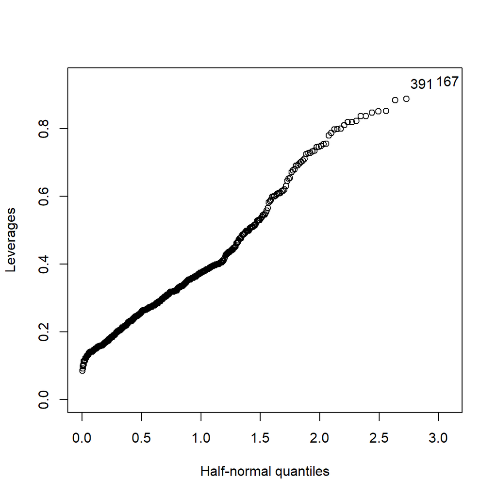

```r
library(faraway)
predictors <- row.names(data)
halfnorm(hat_val,labs=predictors,ylab="Leverages")
```

# Checking for Outliers:

Finding Studentized Residuals:

```r
r_stud <- rstudent(lmod)
r_stud
```

```
##             1             2             3             4             5
##   0.243218520   0.266556084  -0.457853245   0.690809864  -0.301922976
##             6             7             8             9            10
##  -0.293807134   0.652760374  -1.319436605  -0.098449420   0.295408509
##            11            12            13            14            15
##   0.072320275   0.366016265  -0.554834466   0.170838964   0.285307625
##            16            17            18            19            20
##  -0.575889171   0.741519895  -1.708983565   1.276846252  -0.115389698
##            21            22            23            24            25
##  -1.139614078   0.977107145   0.544150692  -1.197313954   0.226426322
##            26            27            28            29            30
##   0.877273669  -0.164287220  -0.224265422  -1.167638378   1.447574269
##            31            32            33            34            35
##  -0.232015052  -1.672549669   1.388717241  -0.005536460  -0.346789610
##            36            37            38            39            40
##  -4.701390843   2.605624233   0.051656325   0.690208921  -0.616750217
##            41            42            43            44            45
##   0.008885950  -0.833047640  -0.430103081   0.194830861  -0.634815669
##            46            47            48            49            50
##   0.659017170  -0.788531386   2.011325193  -1.223022134   0.116711236
##            51            52            53            54            55
##  -0.329009089   1.846026374  -1.359036866  -0.890159593   0.850440871
##            56            57            58            59            60
##  -0.298764156  -0.230798808  -0.124784035  -0.128149980  -0.152724350
##            61            62            63            64            65
##  -0.202254605   0.374547085   0.649787903   0.075325122  -0.357924355
##            66            67            68            69            70
##   0.420968630   0.097764409  -0.883054111  -0.392660353  -1.111238097
##            71            72            73            74            75
##   0.691900574   0.994242504  -0.937676387  -0.665676240   0.543548131
##            76            77            78            79            80
##  -0.645024749   0.132405409  -0.247800712   0.130758778   1.602934532
##            81            82            83            84            85
##   0.222207494  -0.296283702  -0.263762420  -0.674303665   0.828748903
##            86            87            88            89            90
##   0.001873044  -1.101135840   0.242892101   0.209469277   0.073936045
##            91            92            93            94            95
##   0.391837741   1.182503913  -0.120860507  -0.839955098   0.148454839
##            96            97            98            99           100
##   0.448714741  -1.648675055   1.170713273  -1.269748808   1.405120398
```

[output cut: 135 more lines]

```
##  -0.838561945  -0.599026462   0.644125987   1.361346318  -0.877842804
##           441           442           443           444           445
##   0.099335398  -0.034424185  -0.412224061   0.110455671   0.418934992
##           446           447           448           449           450
##   0.622414508  -1.186234442  -0.313859229   0.542927872  -0.612791662
##           451           452           453           454           455
##   0.508190720  -0.582344374   0.655609647  -1.724725094   0.725944922
##           456           457           458           459           460
##   1.336556131   0.579797356   0.673668895  -0.286726512  -1.881863630
##           461           462           463           464           465
##  -0.101045687   0.614799114  -1.114916616   0.697236059   0.077579674
##           466           467           468           469           470
##  -0.320378555  -1.190752747   0.465385577   0.624738789  -1.020841240
##           471           472           473           474
##   0.894152296  -0.288729136   1.098510018  -0.153608609
```

Look for the studentized residuals greater than abs(3). Those are the outliers. Based on this, it looks like the values 329, 331, 36, and 334 are outliers.

# Checking for Influential Points:

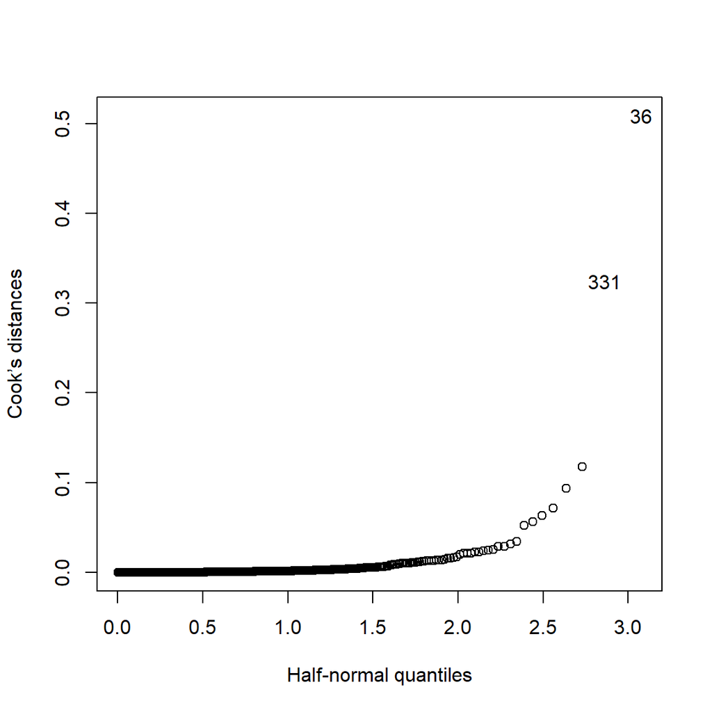

```r
library(faraway)
cook_distance = cooks.distance(lmod)
halfnorm(cook_distance, ylab="Cook’s distances")
```

Values 331 and 36 are the influential points because they are labeled.

# Check the structure of the relationship between the predictors and the response.

Making avplots with a few different predictors on the x-axis to get somewhat of an idea of the correlation between different predictors and density. I will only do a few of the predictors because there are just too many to do all of them.

```r
#install.packages("car")
library(car)
library(tidyverse)
library(carData)
```

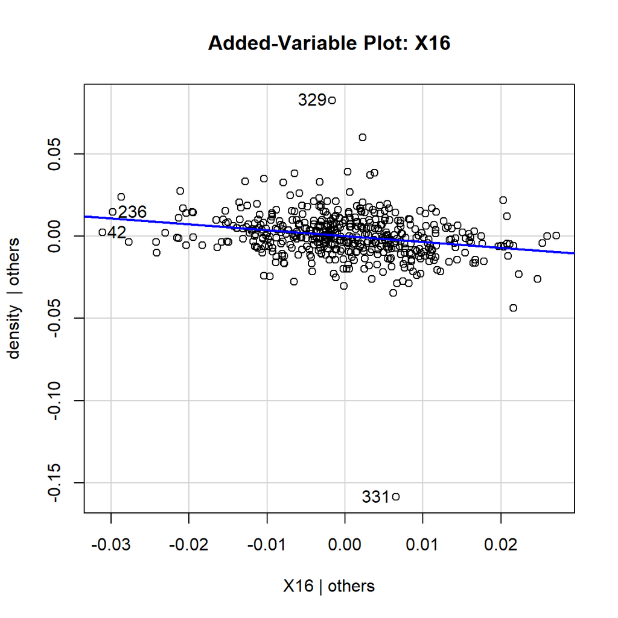

```r
avPlot(lmod,'X16')
```

There seems to be a slight negative linear relationship between the predictor X16 and the response density.

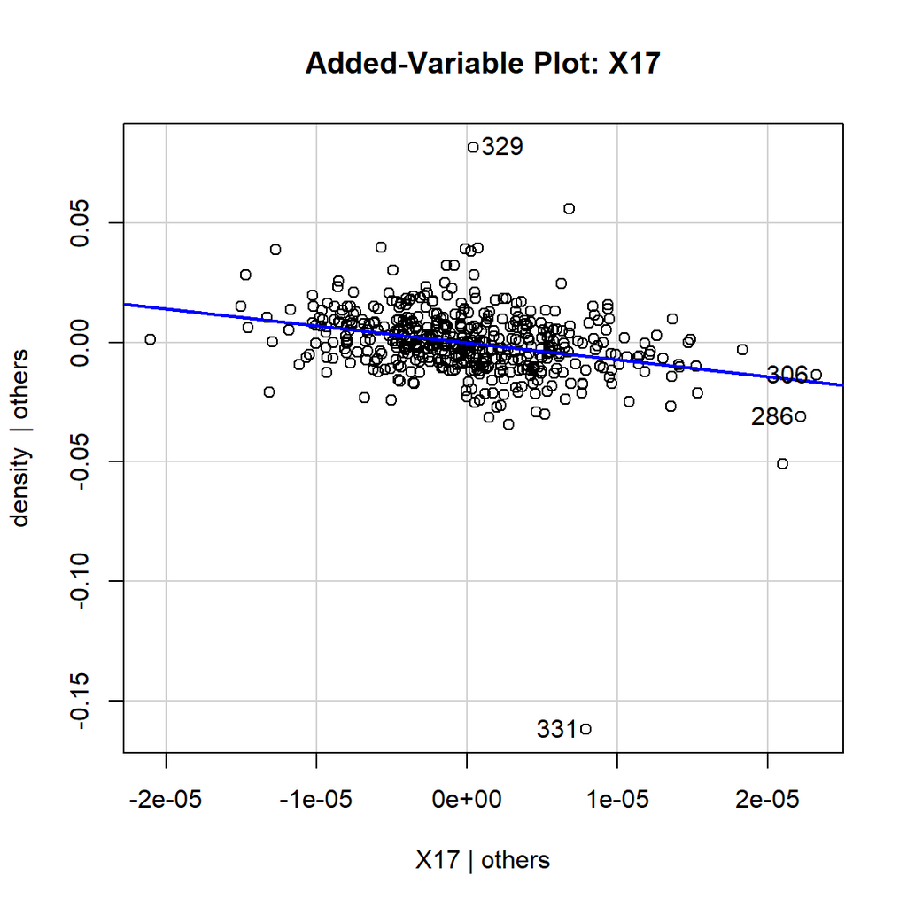

```r
avPlot(lmod,'X17')
```

There seems to be a slight negative linear relationship between the predictor X17 and the response density.

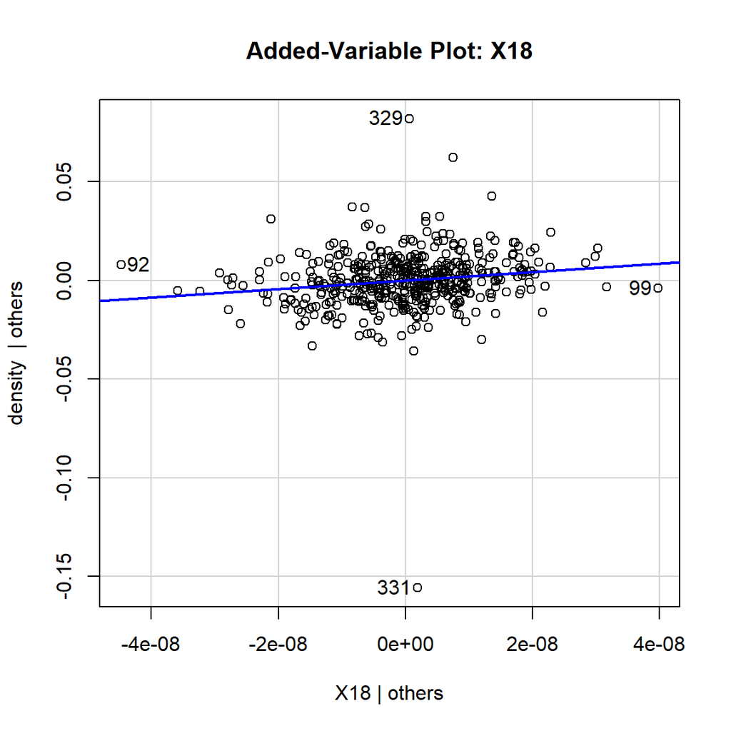

```r
avPlot(lmod,'X18')
```

There seems to be a slight positive linear relationship between the predictor X18 and the response density.

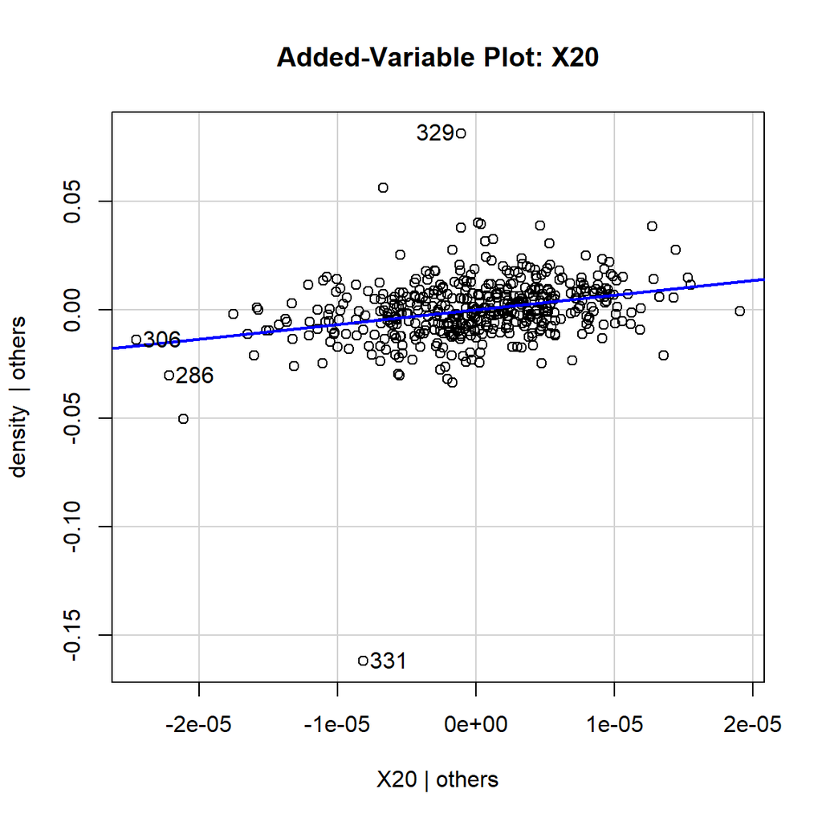

```r
avPlot(lmod,'X20')
```

There seems to be a slight positive linear relationship between the predictor X20 and the response density.

**Overall, there seems to be a slight linear relationship between each of the predictors and the response density. Maybe that’s not true for all of the predictors, but it at least holds true for some of them.**

# Checking Model Assumptions: independence of errors

Since there are so many predictors, most likely there will be collinearity issues meaning that not all of the predictors are independent.

### Checking for Collinearity

**Computing the eigenvalues and condition numbers:**

Doing eigenvalue test:

```r
x <- model.matrix(lmod)[,-1]
e <- eigen(t(x) %*% x)
e$val
```

```
##   [1]  4.357176e+20  1.754956e+18  8.552632e+17  8.865119e+16  8.474745e+15
##   [6]  3.411770e+15  1.180249e+15  1.037341e+15  3.276835e+14  1.520198e+14
##  [11]  8.433908e+13  5.782744e+13  2.308957e+13  1.045905e+13  6.296875e+12
##  [16]  2.309759e+12  1.597699e+12  1.320402e+12  7.377714e+11  5.863680e+11
##  [21]  3.529273e+11  2.938520e+11  1.009049e+11  5.807868e+10  5.363639e+10
##  [26]  4.381781e+10  3.143447e+10  1.902047e+10  1.701139e+10  1.362807e+10
##  [31]  7.973724e+09  5.119402e+09  3.451340e+09  2.586924e+09  1.935839e+09
##  [36]  1.555155e+09  9.199971e+08  6.815783e+08  4.136511e+08  3.774380e+08
##  [41]  2.722795e+08  1.441050e+08  1.036001e+08  7.787036e+07  7.063470e+07
##  [46]  4.156113e+07  3.530745e+07  2.849558e+07  1.439237e+07  1.300500e+07
##  [51]  1.140145e+07  6.165501e+06  5.556937e+06  3.696854e+06  2.405537e+06
##  [56]  1.766375e+06  1.234536e+06  7.067016e+05  5.645555e+05  3.113838e+05
##  [61]  2.779072e+05  2.067948e+05  1.531177e+05  1.241581e+05  7.932897e+04
##  [66]  4.412011e+04  4.061682e+04  3.644542e+04  2.869733e+04  2.774394e+04
##  [71]  2.666969e+04  2.403587e+04  2.032943e+04  1.769176e+04  1.346821e+04
```

[output cut: 17 more lines]

These are the condition numbers also known as ratios:

```r
sqrt(e$val[1]/e$val)
```

```
##   [1] 1.000000e+00 1.575685e+01 2.257110e+01 7.010682e+01 2.267458e+02
##   [6] 3.573656e+02 6.075973e+02 6.480996e+02 1.153122e+03 1.692982e+03
##  [11] 2.272941e+03 2.744957e+03 4.344048e+03 6.454409e+03 8.318404e+03
##  [16] 1.373470e+04 1.651411e+04 1.816559e+04 2.430198e+04 2.725947e+04
##  [21] 3.513662e+04 3.850688e+04 6.571227e+04 8.661522e+04 9.013071e+04
##  [26] 9.971885e+04 1.177334e+05 1.513533e+05 1.600415e+05 1.788074e+05
##  [31] 2.337610e+05 2.917380e+05 3.553110e+05 4.104032e+05 4.744254e+05
##  [36] 5.293169e+05 6.881916e+05 7.995483e+05 1.026326e+06 1.074434e+06
##  [41] 1.265013e+06 1.738853e+06 2.050796e+06 2.365465e+06 2.483668e+06
##  [46] 3.237866e+06 3.512929e+06 3.910334e+06 5.502200e+06 5.788252e+06
##  [51] 6.181909e+06 8.406561e+06 8.854924e+06 1.085641e+07 1.345850e+07
##  [56] 1.570584e+07 1.878670e+07 2.483045e+07 2.778109e+07 3.740714e+07
##  [61] 3.959612e+07 4.590212e+07 5.334453e+07 5.924000e+07 7.411168e+07
##  [66] 9.937664e+07 1.035737e+08 1.093405e+08 1.232202e+08 1.253194e+08
##  [71] 1.278185e+08 1.346396e+08 1.463996e+08 1.569340e+08 1.798654e+08
```

[output cut: 17 more lines]

If the eigenvalues and the condition numbers (aka ratios) are between 0 and 1 then there are no collinearity issues. If the eigenvalues are not in between 0 and 1 and the condition numbers are really big then that means that there could be collinearity issues. In this case, both the eigenvalues and the condition numbers are really big, so there could be collinearity issues.

### VIF

Vif helps also helps determine collinearity. The higher the vif numbers then the higher the correlation.

```r
library(car)
vif(lmod)
```

```
##   X16   X17   X18   X20   X22   X23   X24   X25   X26   X27   X28   X29   X30
##   NaN   NaN   NaN   NaN   NaN   NaN   NaN   NaN   NaN   NaN   NaN   NaN   NaN
##   X31   X32   X34   X35   X36   X38   X40   X41   X43   X44   X45   X46    X1
##   NaN   NaN   NaN   NaN   NaN   NaN   NaN   NaN   NaN   NaN   NaN   NaN   NaN
##    X2    X3    X4    X8   X11   X13   X14 X16.1 X18.1 X19.1 X20.1 X21.1 X22.1
##   NaN   NaN   NaN   NaN   NaN   NaN   NaN   NaN   NaN   NaN   NaN   NaN   NaN
## X25.1 X27.1 X28.1 X29.1 X31.1 X33.1 X34.1 X35.1 X37.1 X38.1 X39.1 X41.1 X42.1
##   NaN   NaN   NaN   NaN   NaN   NaN   NaN   NaN   NaN   NaN   NaN   NaN   NaN
##   X50   X51   X53   X54   X56   X57   X61   X63   X64   X68   X70   X72   X75
##   NaN   NaN   NaN   NaN   NaN   NaN   NaN   NaN   NaN   NaN   NaN   NaN   NaN
##   X78   X80   X81   X85   X86   X87   X89   X91   X93   X94   X99  X106  X109
##   NaN   NaN   NaN   NaN   NaN   NaN   NaN   NaN   NaN   NaN   NaN   NaN   NaN
##  X111  X112  X113  X114  X119  X120  X132  X135  X141  X144  X148  X149  X150
##   NaN   NaN   NaN   NaN   NaN   NaN   NaN   NaN   NaN   NaN   NaN   NaN   NaN
##  X151  X154  X157  X160  X163  X164  X165  X168  X172  X175  X178  X186  X187
##   NaN   NaN   NaN   NaN   NaN   NaN   NaN   NaN   NaN   NaN   NaN   NaN   NaN
##  X188  X189  X198  X201  X210  X213  X214  X217  X220  X223  X224  X226  X229
##   NaN   NaN   NaN   NaN   NaN   NaN   NaN   NaN   NaN   NaN   NaN   NaN   NaN
##  X233  X234  X238  X240  X241  X244  X250  X252  X253  X254  X255  X277  X280
##   NaN   NaN   NaN   NaN   NaN   NaN   NaN   NaN   NaN   NaN   NaN   NaN   NaN
##  X283  X286  X289  X293  X294  X295  X307  X309  X310  X330  X331  X340  X344
##   NaN   NaN   NaN   NaN   NaN   NaN   NaN   NaN   NaN   NaN   NaN   NaN   NaN
##  X345  X346  X349  X352  X357  X358  X376  X391  X396  X397  X421  X426  X427
##   NaN   NaN   NaN   NaN   NaN   NaN   NaN   NaN   NaN   NaN   NaN   NaN   NaN
##  X445  X464  X465
##   NaN   NaN   NaN
```

Unfortunately, for this set of predictors we can’t get any vif values.

### Principle Component Analysis (PCA)

Since there are a lot of predictors and collinearity exists, we do PCA.

```r
data_pca <- prcomp(data[,c("X16", "X17", "X18", "X20", "X22", "X23", "X24",
    "X25", "X26", "X27", "X28", "X29", "X30", "X31", "X32", "X34", "X35",
    "X36", "X38", "X40", "X41", "X43", "X44", "X45", "X46", "X1", "X2",
    "X3", "X4", "X8", "X11", "X13", "X14", "X16.1", "X18.1", "X19.1",
    "X20.1", "X21.1", "X22.1", "X25.1", "X27.1", "X28.1", "X29.1", "X31.1",
    "X33.1", "X34.1", "X35.1", "X37.1", "X38.1", "X39.1", "X41.1", "X42.1",
    "X50", "X51", "X53", "X54", "X56", "X57", "X61", "X63", "X64", "X68",
    "X70", "X72", "X75", "X78", "X80", "X81", "X85", "X86", "X87", "X89",
    "X91", "X93", "X94", "X99", "X106", "X109", "X111", "X112", "X113",
    "X114", "X119", "X120", "X132", "X135", "X141", "X144", "X148", "X149",
    "X150", "X151", "X154", "X157", "X160", "X163", "X164", "X165", "X168",
    "X172", "X175", "X178", "X186", "X187", "X188", "X189", "X198", "X201",
    "X210", "X213", "X214", "X217", "X220", "X223", "X224", "X226", "X229",
    "X233", "X234", "X238", "X240", "X241", "X244", "X250", "X252", "X253",
    "X254", "X255", "X277", "X280", "X283", "X286", "X289", "X293", "X294",
    "X295", "X307", "X309", "X310", "X330", "X331", "X340", "X344", "X345",
    "X346", "X349", "X352", "X357", "X358", "X376", "X391", "X396", "X397",
    "X421", "X426", "X427", "X445", "X464", "X465")])


summary(data_pca)
```

```
## Importance of components:
##                              PC1       PC2       PC3       PC4       PC5
## Standard deviation     6.475e+08 4.977e+07 2.066e+07 6.449e+06 3.296e+06
## Proportion of Variance 9.930e-01 5.870e-03 1.010e-03 1.000e-04 3.000e-05
## Cumulative Proportion  9.930e-01 9.988e-01 9.999e-01 1.000e+00 1.000e+00
##                              PC6       PC7    PC8    PC9   PC10   PC11   PC12
## Standard deviation     2.561e+06 1.483e+06 939033 645263 450556 350956 242046
## Proportion of Variance 2.000e-05 1.000e-05      0      0      0      0      0
## Cumulative Proportion  1.000e+00 1.000e+00      1      1      1      1      1
##                          PC13   PC14   PC15  PC16  PC17  PC18  PC19  PC20  PC21
## Standard deviation     148795 116497 100774 67130 53440 42066 38251 30356 26947
## Proportion of Variance      0      0      0     0     0     0     0     0     0
## Cumulative Proportion       1      1      1     1     1     1     1     1     1
##                         PC22  PC23  PC24 PC25 PC26 PC27 PC28 PC29 PC30 PC31
## Standard deviation     20758 13151 10835 9968 9098 6349 6155 5512 4771 3763
## Proportion of Variance     0     0     0    0    0    0    0    0    0    0
## Cumulative Proportion      1     1     1    1    1    1    1    1    1    1
##                        PC32 PC33 PC34 PC35 PC36 PC37  PC38  PC39  PC40  PC41
## Standard deviation     2743 2408 2050 1854 1429 1298 952.9 923.4 806.9 739.8
## Proportion of Variance    0    0    0    0    0    0   0.0   0.0   0.0   0.0
## Cumulative Proportion     1    1    1    1    1    1   1.0   1.0   1.0   1.0
##                         PC42  PC43  PC44  PC45  PC46  PC47  PC48  PC49  PC50
## Standard deviation     488.8 433.6 390.3 332.7 293.7 255.7 175.4 170.2 155.3
## Proportion of Variance   0.0   0.0   0.0   0.0   0.0   0.0   0.0   0.0   0.0
## Cumulative Proportion    1.0   1.0   1.0   1.0   1.0   1.0   1.0   1.0   1.0
##                         PC51  PC52  PC53  PC54  PC55  PC56  PC57  PC58 PC59
## Standard deviation     131.7 108.4 90.58 73.96 70.16 61.01 38.97 35.72 27.2
## Proportion of Variance   0.0   0.0  0.00  0.00  0.00  0.00  0.00  0.00  0.0
## Cumulative Proportion    1.0   1.0  1.00  1.00  1.00  1.00  1.00  1.00  1.0
##                         PC60  PC61  PC62  PC63  PC64  PC65  PC66 PC67  PC68
## Standard deviation     25.06 24.23 21.04 16.58 14.91 13.95 12.13 9.35 7.855
## Proportion of Variance  0.00  0.00  0.00  0.00  0.00  0.00  0.00 0.00 0.000
## Cumulative Proportion   1.00  1.00  1.00  1.00  1.00  1.00  1.00 1.00 1.000
##                         PC69  PC70  PC71  PC72  PC73  PC74  PC75  PC76  PC77
## Standard deviation     6.617 5.892 4.897 4.528 4.242 3.723 2.826 2.683 2.331
## Proportion of Variance 0.000 0.000 0.000 0.000 0.000 0.000 0.000 0.000 0.000
## Cumulative Proportion  1.000 1.000 1.000 1.000 1.000 1.000 1.000 1.000 1.000
##                         PC78  PC79  PC80  PC81  PC82   PC83   PC84   PC85
## Standard deviation     1.937 1.738 1.507 1.167 1.024 0.8663 0.7267 0.6408
## Proportion of Variance 0.000 0.000 0.000 0.000 0.000 0.0000 0.0000 0.0000
```

[output cut: 38 more lines]

```
## Standard deviation     2.611e-05 2.346e-05 1.562e-05 1.433e-05 1.264e-05
## Proportion of Variance 0.000e+00 0.000e+00 0.000e+00 0.000e+00 0.000e+00
## Cumulative Proportion  1.000e+00 1.000e+00 1.000e+00 1.000e+00 1.000e+00
##                            PC147     PC148     PC149     PC150     PC151
## Standard deviation     8.758e-06 6.418e-06 5.374e-06 3.946e-06 5.828e-07
## Proportion of Variance 0.000e+00 0.000e+00 0.000e+00 0.000e+00 0.000e+00
## Cumulative Proportion  1.000e+00 1.000e+00 1.000e+00 1.000e+00 1.000e+00
##                            PC152     PC153    PC154    PC155    PC156    PC157
## Standard deviation     3.129e-07 6.088e-08 6.04e-08 6.04e-08 6.04e-08 6.04e-08
## Proportion of Variance 0.000e+00 0.000e+00 0.00e+00 0.00e+00 0.00e+00 0.00e+00
## Cumulative Proportion  1.000e+00 1.000e+00 1.00e+00 1.00e+00 1.00e+00 1.00e+00
##                           PC158    PC159
## Standard deviation     6.04e-08 6.04e-08
## Proportion of Variance 0.00e+00 0.00e+00
## Cumulative Proportion  1.00e+00 1.00e+00
```

From this summary, it seems like the first principal component explains 99.30% of the variation in the data whereas the other components don’t explain a lot more at all about the variance. So, we could use only the first principal component (aka PC) and not bother with using the others.

But to double check, we plot the standard deviations of all of the principal components:

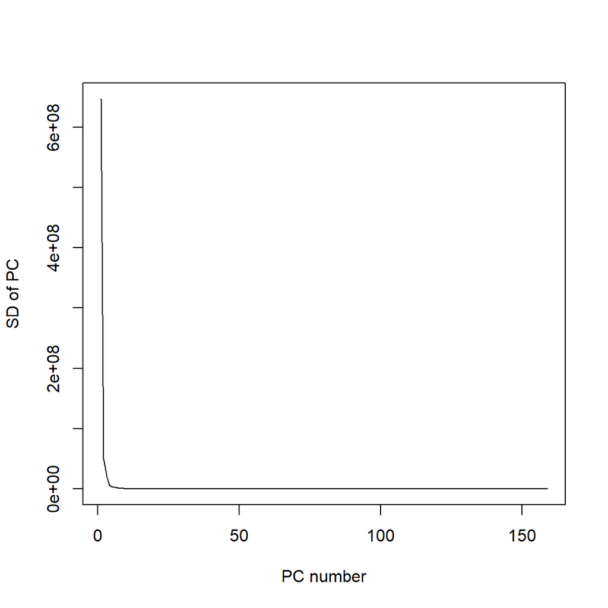

```r
#sdev and SD both represent standard deviation
plot(data_pca$sdev,type="l",ylab="SD of PC", xlab="PC number")
```

We’re looking for an “elbow” in the plot, and it’s really hard to see exactly where it happens on this plot. It should happen at the second PC because that would back up the claim that was just made above after looking at the summary. So, here is a zoomed in version of the plot:

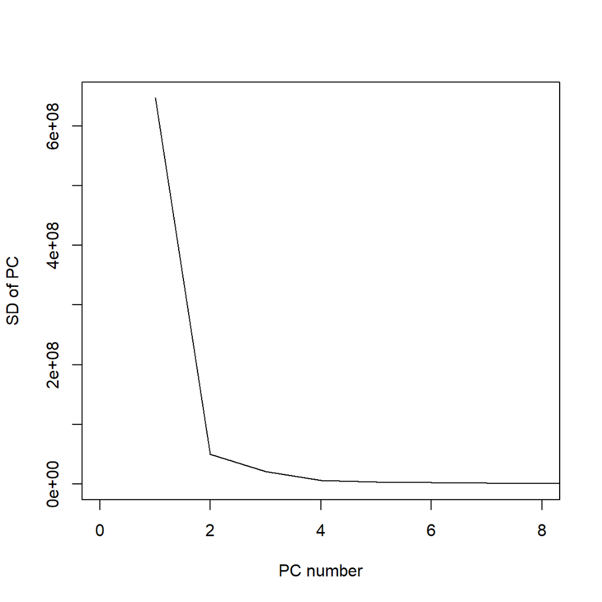

```r
#sdev and SD both represent standard deviation
plot(data_pca$sdev, xlim=c(0,8), type="l",ylab="SD of PC", xlab="PC number")
```

The “elbow” is at 2 which means that we should use only the first PC based on this plot, as well

# Checking Model Assumptions: normally distributed errors, constant variance, and linear relationship

First, let’s check for normally distributed errors by looking at the qqplots and histograms. And let’s check for constant variance by looking at the residuals vs fitted plot. And let’s check for a linear relationship between data.

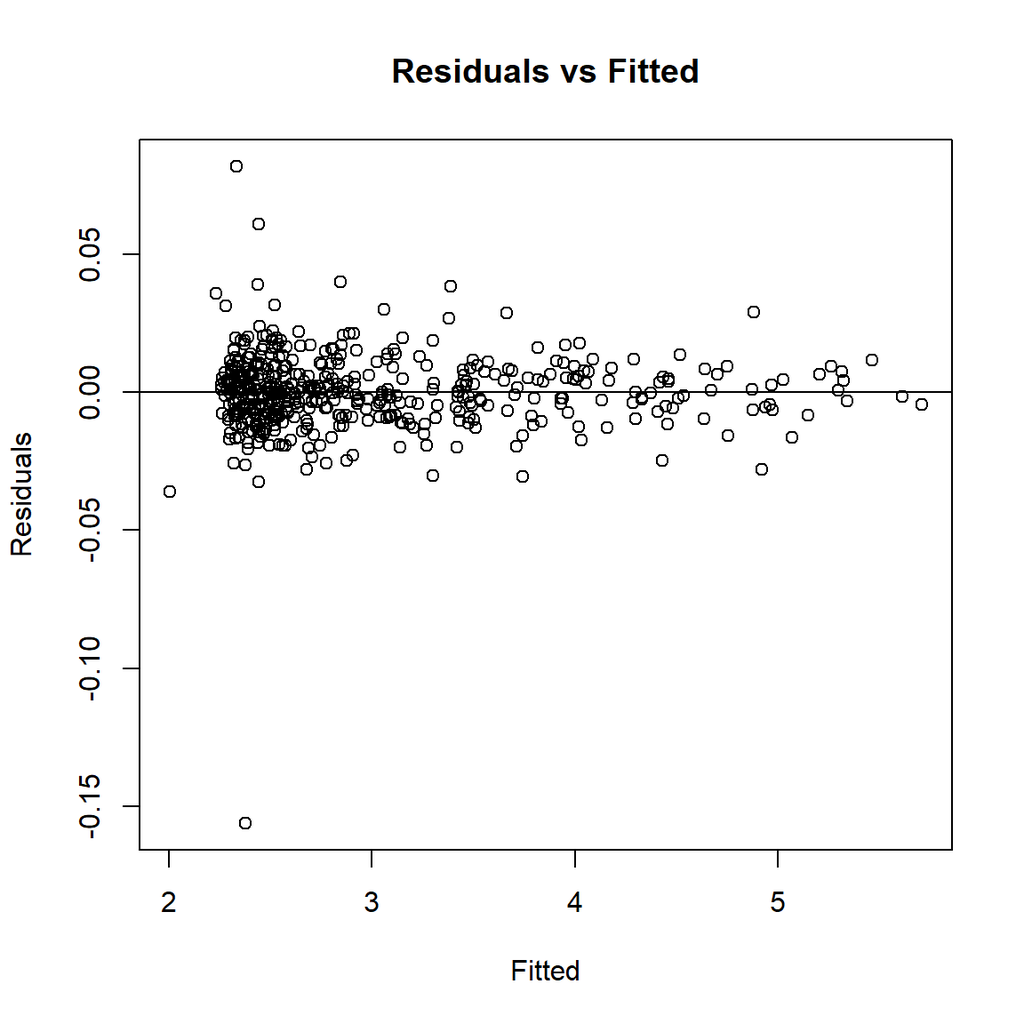

```r
plot(fitted(lmod), residuals(lmod), xlab="Fitted", ylab="Residuals",  main = "Residuals vs Fitted")
abline(h=0)
```

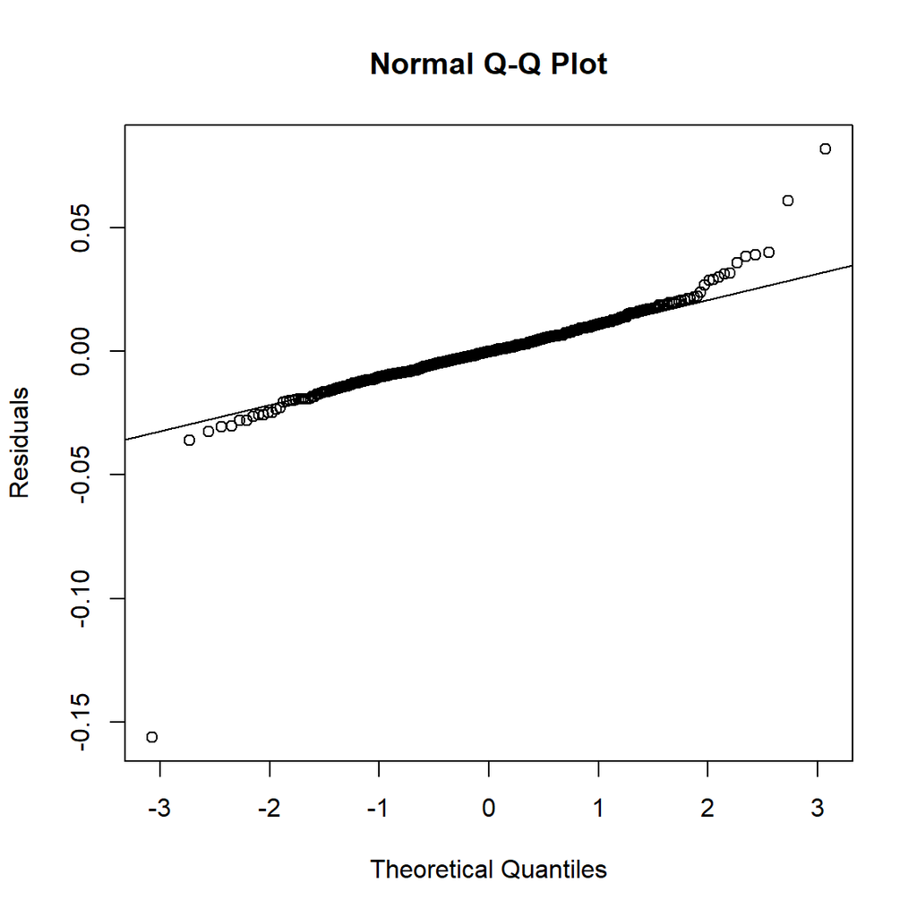

```r
#Q-Q Plot
qqnorm(residuals(lmod), ylab="Residuals", main="Normal Q-Q Plot")
qqline(residuals(lmod))
```

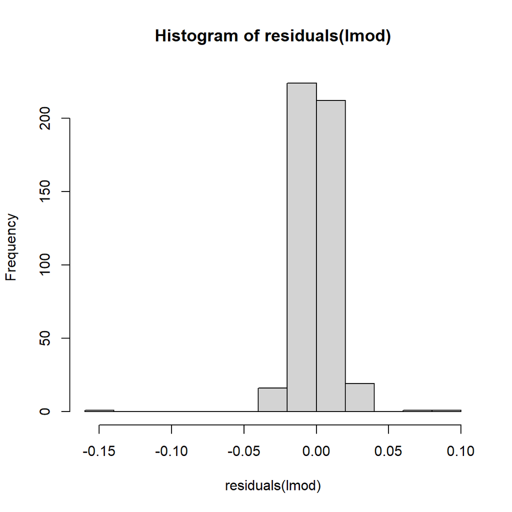

```r
#histogram
hist(residuals(lmod))
```

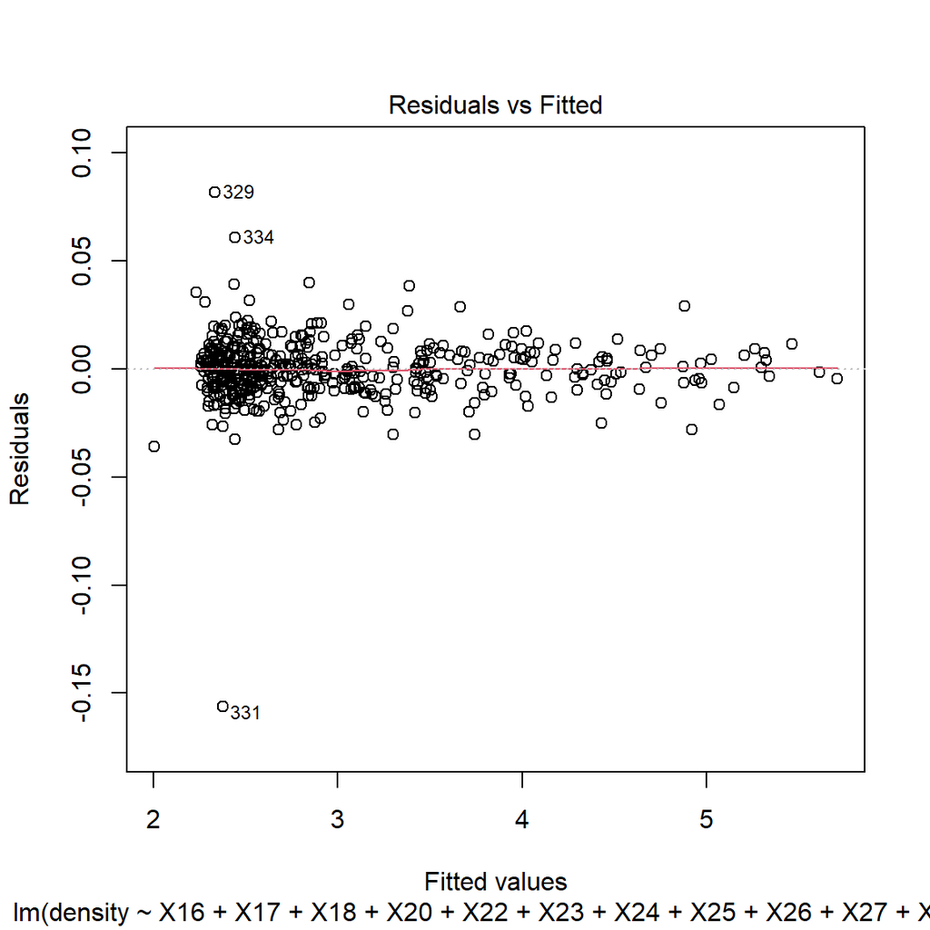

```r
#Residuals vs Fitted Plot with lowess smoother (red line)
plot(lmod, 1)
```

**Residual vs Fitted Plot:** Based on this residual vs fitted plot, it looks like the variance is not constant because there is a pattern within the data points. It seems like some of the points on the left side of the graph are spaced farther apart than the points elsewhere.

**Q-Q Plot:** Based on this Q-Q plot, the residuals don’t follow a normal distribution. In fact, they have a heavy tail distribution because of where the data points are and because the slope of the line is small.

**Histogram:** Based on this histogram, it seems like the residuals are somewhat normally distributed though because of the bell shaped curve. Although, it’s not completely in the center of the x-axis.

**Residuals vs Fitted Plot with lowess smoother (red line):** This plot tells if your data is linearly related. If the red line is pretty straight and is at Residuals = 0, then your data is linearly related. Since that is what we have, that error assumption holds true for our model. So, we don’t have to try and fix anything for this specific model assumption.

# Transformations

We can fix not normally distributed errors and non-constant variance by doing different transformations. For example, we can try different transformations of the response such as, log, inverse, square root, or boxcox.

Trying the Boxcox Transformation:

```r
#install.packages("MASS")
library(MASS)
```

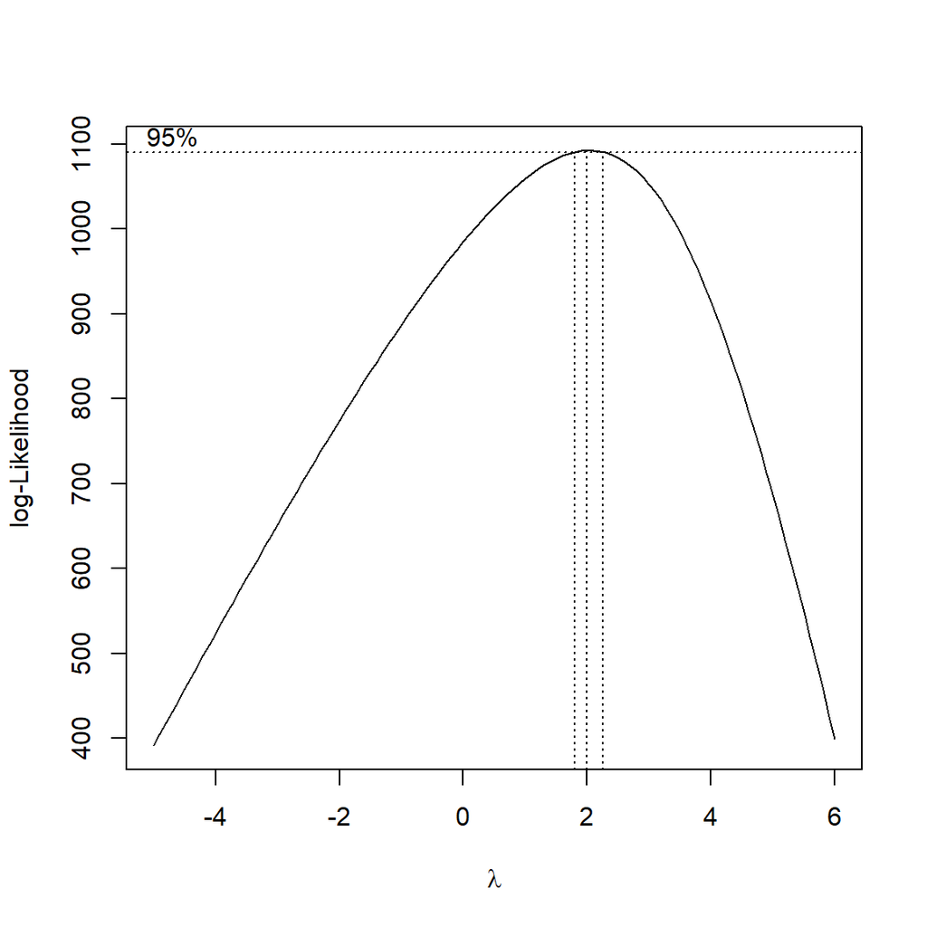

```r
box_cox <- boxcox(lmod, lambda = seq(-5, 6, by=0.1)) #lambdas by default were from -2 to 2 but the graph didn't look as good that's why lambdas are now -5 to 6
```

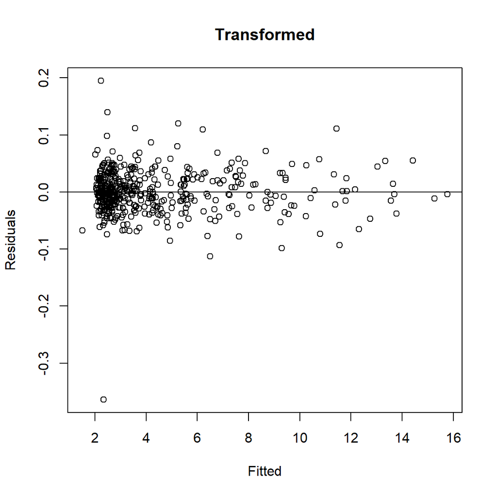

```r
#best lambda
lambda <- box_cox$x[which.max(box_cox$y)]
data$ystar <- (data$density^lambda-1)/lambda

#plotting transformed lmod
lmod_ystar <- lm(ystar ~ X16 + X17 + X18 + X20 + X22 + X23 + X24 +
    X25 + X26 + X27 + X28 + X29 + X30 + X31 + X32 + X34 + X35 +
    X36 + X38 + X40 + X41 + X43 + X44 + X45 + X46 + X1 + X2 +
    X3 + X4 + X8 + X11 + X13 + X14 + X16.1 + X18.1 + X19.1 +
    X20.1 + X21.1 + X22.1 + X25.1 + X27.1 + X28.1 + X29.1 + X31.1 +
    X33.1 + X34.1 + X35.1 + X37.1 + X38.1 + X39.1 + X41.1 + X42.1 +
    X50 + X51 + X53 + X54 + X56 + X57 + X61 + X63 + X64 + X68 +
    X70 + X72 + X75 + X78 + X80 + X81 + X85 + X86 + X87 + X89 +
    X91 + X93 + X94 + X99 + X106 + X109 + X111 + X112 + X113 +
    X114 + X119 + X120 + X132 + X135 + X141 + X144 + X148 + X149 +
    X150 + X151 + X154 + X157 + X160 + X163 + X164 + X165 + X168 +
    X172 + X175 + X178 + X186 + X187 + X188 + X189 + X198 + X201 +
    X210 + X213 + X214 + X217 + X220 + X223 + X224 + X226 + X229 +
    X233 + X234 + X238 + X240 + X241 + X244 + X250 + X252 + X253 +
    X254 + X255 + X277 + X280 + X283 + X286 + X289 + X293 + X294 +
    X295 + X307 + X309 + X310 + X330 + X331 + X340 + X344 + X345 +
    X346 + X349 + X352 + X357 + X358 + X376 + X391 + X396 + X397 +
    X421 + X426 + X427 + X445 + X464 + X465, data = data)

plot(fitted(lmod_ystar), residuals(lmod_ystar), xlab="Fitted", ylab="Residuals", main = "Transformed")
abline(h=0)
```

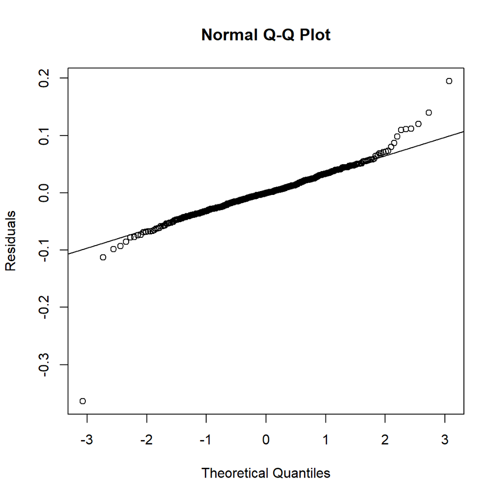

```r
#Q-Q Plot
qqnorm(residuals(lmod_ystar), ylab="Residuals", main="Normal Q-Q Plot")
qqline(residuals(lmod_ystar))
```

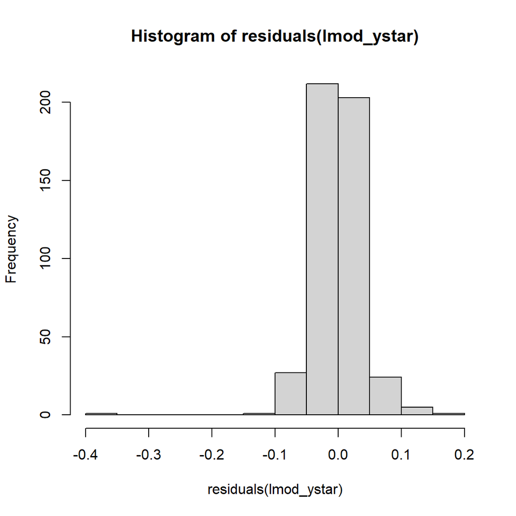

```r
#histogram
hist(residuals(lmod_ystar))
```

**Residual vs Fitted Plot:** Based on this residual vs fitted plot, it looks like the variance is still not constant because there is a pattern within the data points. It still seems like some of the points on the left side of the graph are spaced farther apart than the points elsewhere. Although, a lot of the other points seem to have spread apart a little bit.

**Q-Q Plot:** Based on this Q-Q plot, the residuals still don’t follow a normal distribution. In fact, they have a heavy tail distribution because of where the data points are and because the slope of the line is small.

**Histogram:** Based on this histogram, it seems like the residuals are somewhat normally distributed though because of the bell shaped curve. However, it’s not really in the center of the x-axis still.

Trying the log transformation on the response:

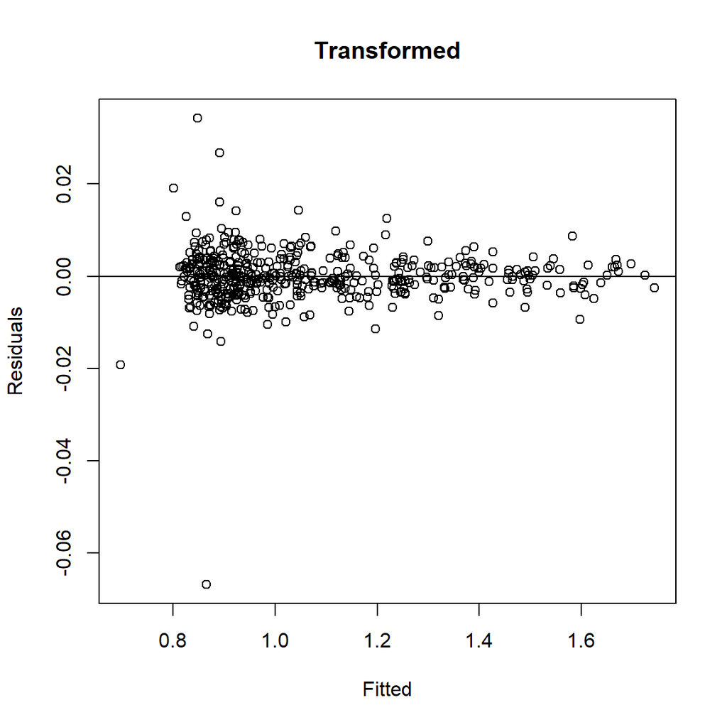

```r
lmod_log <- lm(log(density) ~ X16 + X17 + X18 + X20 + X22 + X23 + X24 +
    X25 + X26 + X27 + X28 + X29 + X30 + X31 + X32 + X34 + X35 +
    X36 + X38 + X40 + X41 + X43 + X44 + X45 + X46 + X1 + X2 +
    X3 + X4 + X8 + X11 + X13 + X14 + X16.1 + X18.1 + X19.1 +
    X20.1 + X21.1 + X22.1 + X25.1 + X27.1 + X28.1 + X29.1 + X31.1 +
    X33.1 + X34.1 + X35.1 + X37.1 + X38.1 + X39.1 + X41.1 + X42.1 +
    X50 + X51 + X53 + X54 + X56 + X57 + X61 + X63 + X64 + X68 +
    X70 + X72 + X75 + X78 + X80 + X81 + X85 + X86 + X87 + X89 +
    X91 + X93 + X94 + X99 + X106 + X109 + X111 + X112 + X113 +
    X114 + X119 + X120 + X132 + X135 + X141 + X144 + X148 + X149 +
    X150 + X151 + X154 + X157 + X160 + X163 + X164 + X165 + X168 +
    X172 + X175 + X178 + X186 + X187 + X188 + X189 + X198 + X201 +
    X210 + X213 + X214 + X217 + X220 + X223 + X224 + X226 + X229 +
    X233 + X234 + X238 + X240 + X241 + X244 + X250 + X252 + X253 +
    X254 + X255 + X277 + X280 + X283 + X286 + X289 + X293 + X294 +
    X295 + X307 + X309 + X310 + X330 + X331 + X340 + X344 + X345 +
    X346 + X349 + X352 + X357 + X358 + X376 + X391 + X396 + X397 +
    X421 + X426 + X427 + X445 + X464 + X465, data = data)

plot(fitted(lmod_log), residuals(lmod_log), xlab="Fitted", ylab="Residuals", main = "Transformed")
abline(h=0)
```

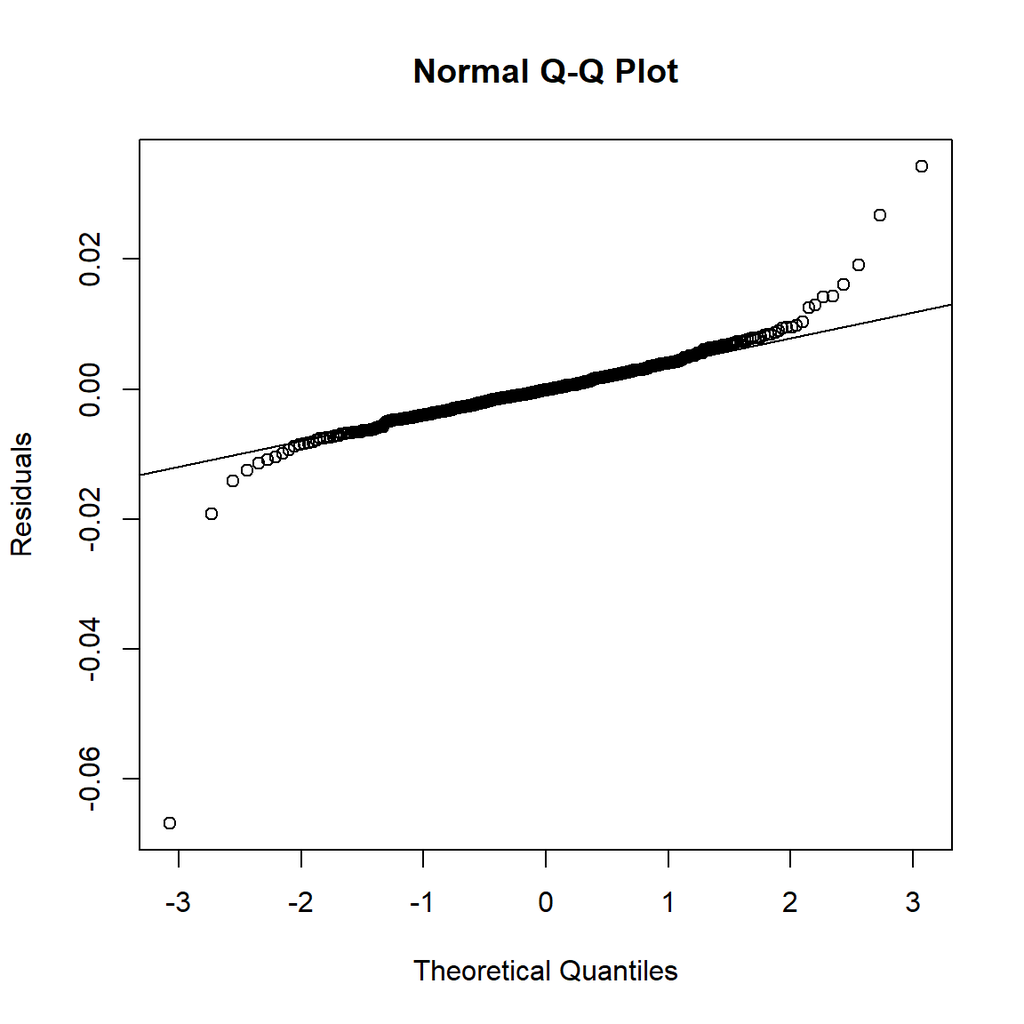

```r
#Q-Q Plot
qqnorm(residuals(lmod_log), ylab="Residuals", main="Normal Q-Q Plot")
qqline(residuals(lmod_log))
```

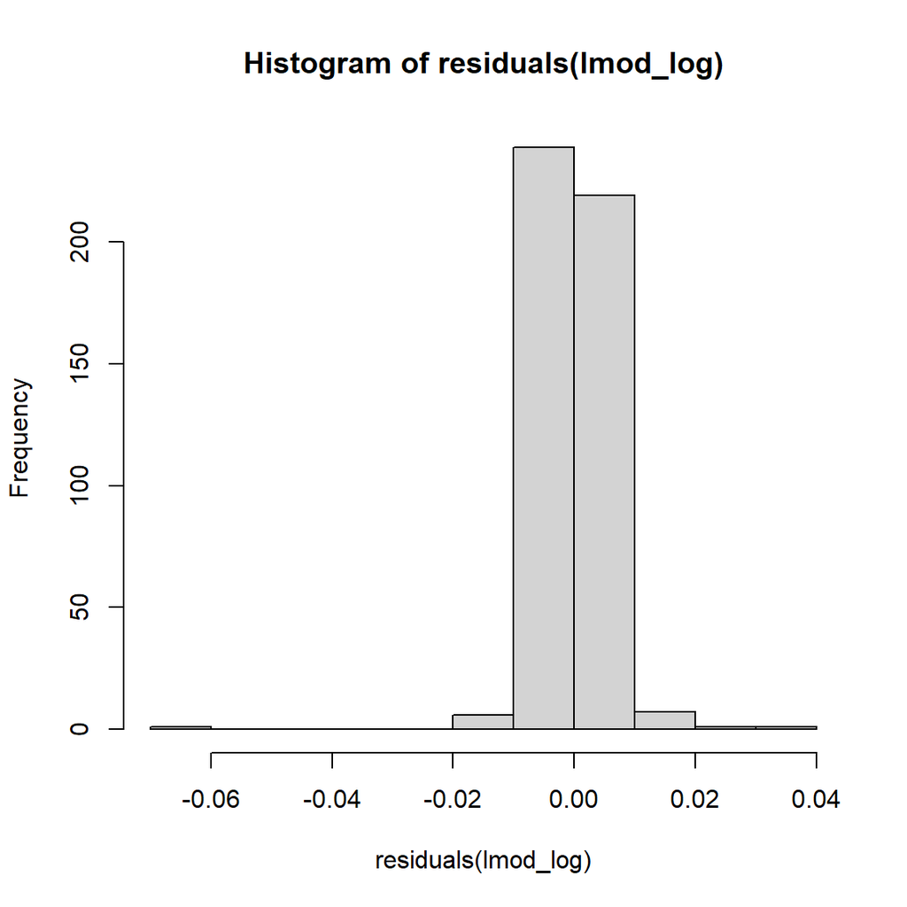

```r
#histogram
hist(residuals(lmod_log))
```

**Residual vs Fitted Plot:** Based on this residual vs fitted plot, it looks like the variance is still not constant because there is a pattern within the data points. It still seems like some of the points on the left side of the graph are spaced farther apart than the points elsewhere.

**Q-Q Plot:** Based on this Q-Q plot, the residuals still don’t follow a normal distribution. In fact, they have a heavy tail distribution because of where the data points are and because the slope of the line is small.

**Histogram:** Based on this histogram, it seems like the residuals are somewhat normally distributed though because of the bell shaped curve. However, it’s not completely in the center of the x-axis still.

Trying the sqrt transformation on the response:

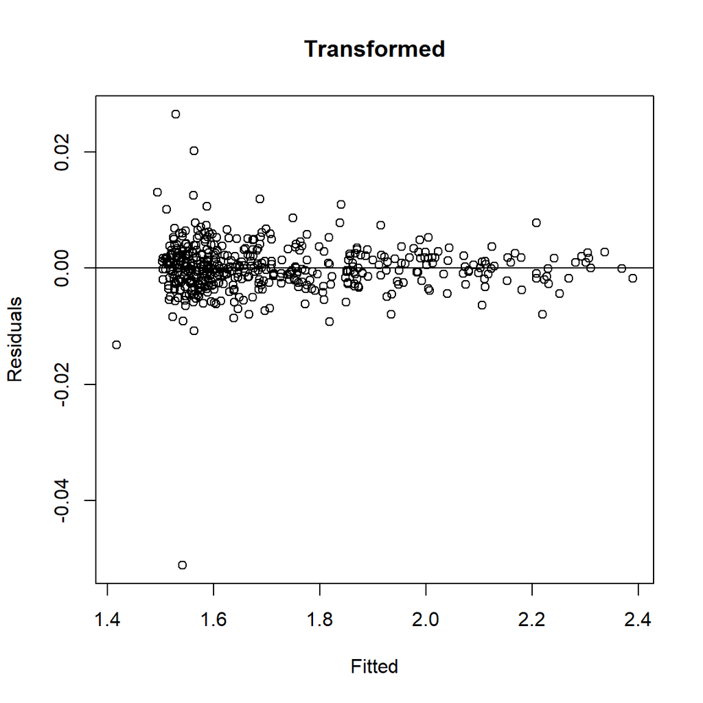

```r
lmod_sqrt <- lm(sqrt(density) ~ X16 + X17 + X18 + X20 + X22 + X23 + X24 +
    X25 + X26 + X27 + X28 + X29 + X30 + X31 + X32 + X34 + X35 +
    X36 + X38 + X40 + X41 + X43 + X44 + X45 + X46 + X1 + X2 +
    X3 + X4 + X8 + X11 + X13 + X14 + X16.1 + X18.1 + X19.1 +
    X20.1 + X21.1 + X22.1 + X25.1 + X27.1 + X28.1 + X29.1 + X31.1 +
    X33.1 + X34.1 + X35.1 + X37.1 + X38.1 + X39.1 + X41.1 + X42.1 +
    X50 + X51 + X53 + X54 + X56 + X57 + X61 + X63 + X64 + X68 +
    X70 + X72 + X75 + X78 + X80 + X81 + X85 + X86 + X87 + X89 +
    X91 + X93 + X94 + X99 + X106 + X109 + X111 + X112 + X113 +
    X114 + X119 + X120 + X132 + X135 + X141 + X144 + X148 + X149 +
    X150 + X151 + X154 + X157 + X160 + X163 + X164 + X165 + X168 +
    X172 + X175 + X178 + X186 + X187 + X188 + X189 + X198 + X201 +
    X210 + X213 + X214 + X217 + X220 + X223 + X224 + X226 + X229 +
    X233 + X234 + X238 + X240 + X241 + X244 + X250 + X252 + X253 +
    X254 + X255 + X277 + X280 + X283 + X286 + X289 + X293 + X294 +
    X295 + X307 + X309 + X310 + X330 + X331 + X340 + X344 + X345 +
    X346 + X349 + X352 + X357 + X358 + X376 + X391 + X396 + X397 +
    X421 + X426 + X427 + X445 + X464 + X465, data = data)

plot(fitted(lmod_sqrt), residuals(lmod_sqrt), xlab="Fitted", ylab="Residuals", main = "Transformed")
abline(h=0)
```

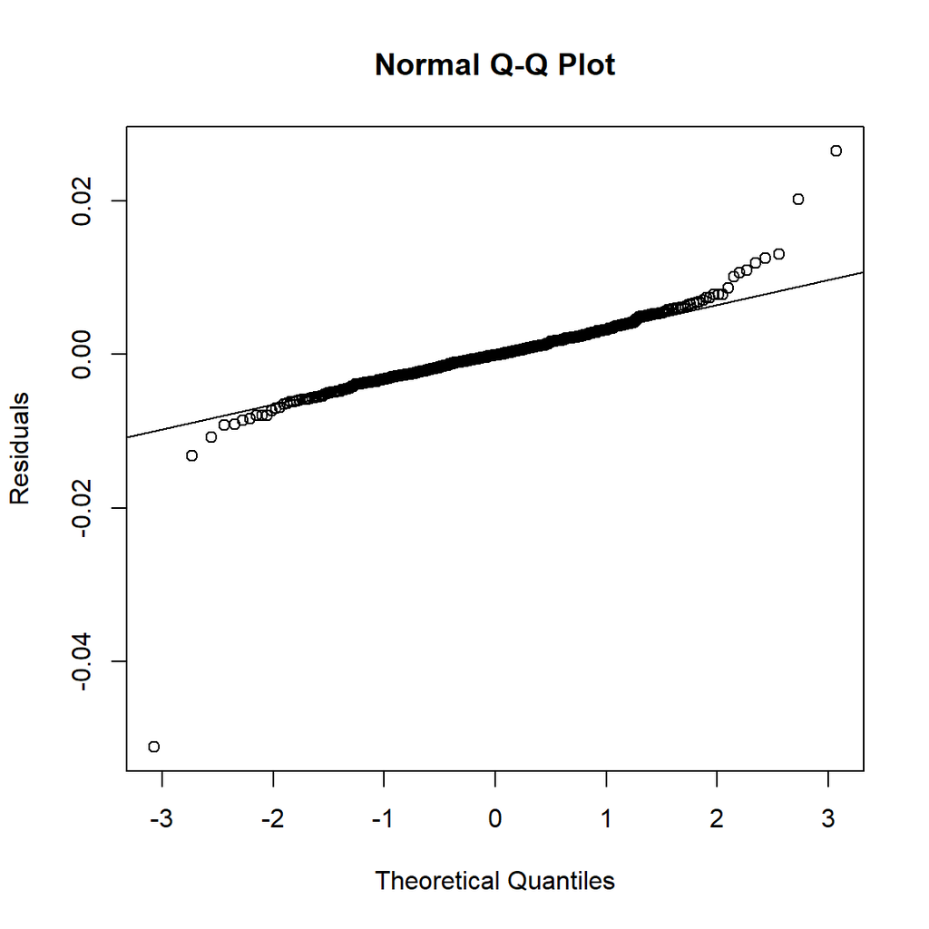

```r
#Q-Q Plot
qqnorm(residuals(lmod_sqrt), ylab="Residuals", main="Normal Q-Q Plot")
qqline(residuals(lmod_sqrt))
```

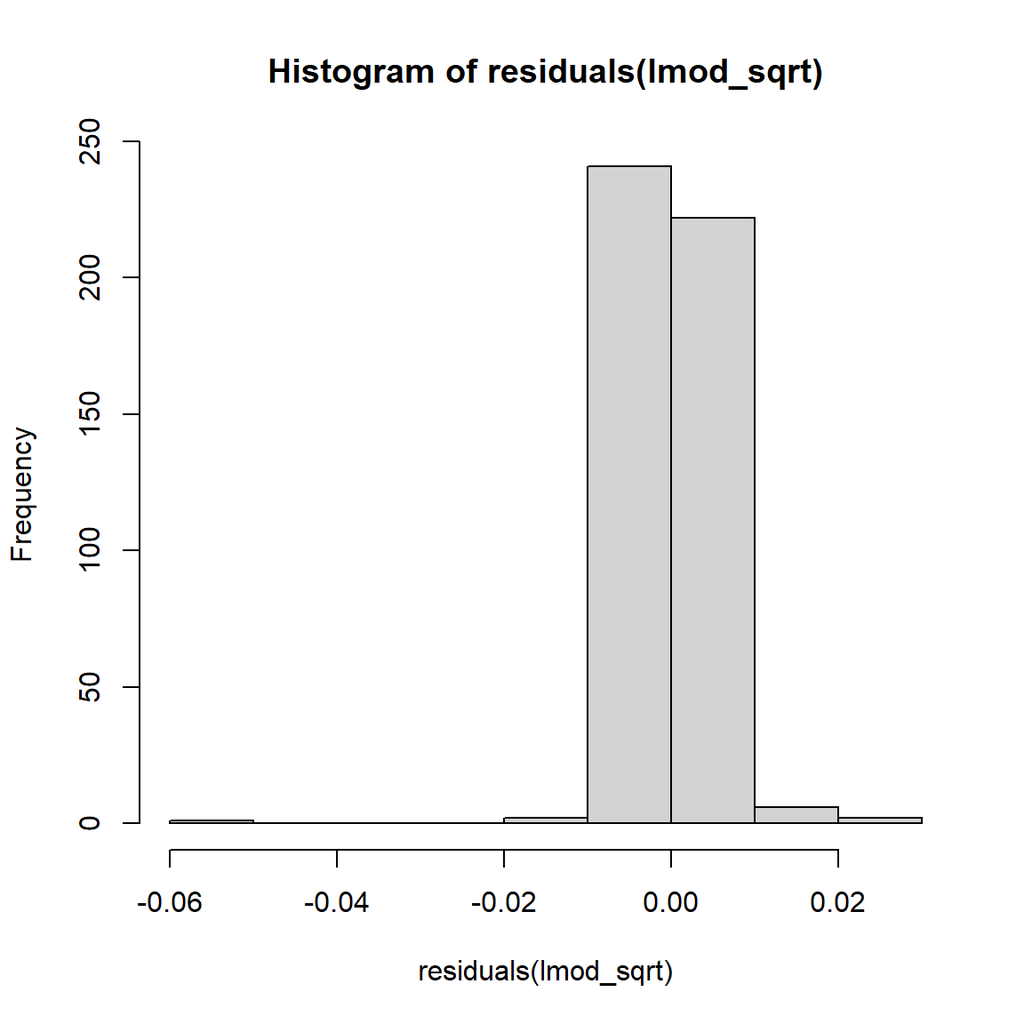

```r
#histogram
hist(residuals(lmod_sqrt))
```

**Residual vs Fitted Plot:** Based on this residual vs fitted plot, it looks like the variance is still not constant because there is a pattern within the data points. It still seems like some of the points on the left side of the graph are spaced farther apart than the points elsewhere.

**Q-Q Plot:** Based on this Q-Q plot, the residuals still don’t follow a normal distribution. In fact, they have a heavy tail distribution because of where the data points are and because the slope of the line is small.

**Histogram:** Based on this histogram, it seems like the residuals are somewhat normally distributed though because of the bell shaped curve. However, it’s still not really in the center of the x-axis.

Trying the inverse transformation on the response:

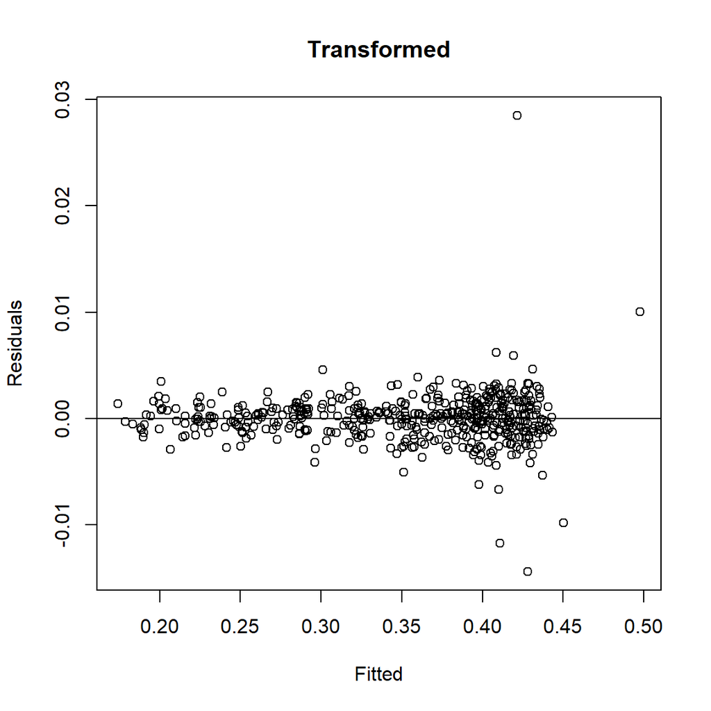

```r
lmod_inverse <- lm(1/(density) ~ X16 + X17 + X18 + X20 + X22 + X23 + X24 +
    X25 + X26 + X27 + X28 + X29 + X30 + X31 + X32 + X34 + X35 +
    X36 + X38 + X40 + X41 + X43 + X44 + X45 + X46 + X1 + X2 +
    X3 + X4 + X8 + X11 + X13 + X14 + X16.1 + X18.1 + X19.1 +
    X20.1 + X21.1 + X22.1 + X25.1 + X27.1 + X28.1 + X29.1 + X31.1 +
    X33.1 + X34.1 + X35.1 + X37.1 + X38.1 + X39.1 + X41.1 + X42.1 +
    X50 + X51 + X53 + X54 + X56 + X57 + X61 + X63 + X64 + X68 +
    X70 + X72 + X75 + X78 + X80 + X81 + X85 + X86 + X87 + X89 +
    X91 + X93 + X94 + X99 + X106 + X109 + X111 + X112 + X113 +
    X114 + X119 + X120 + X132 + X135 + X141 + X144 + X148 + X149 +
    X150 + X151 + X154 + X157 + X160 + X163 + X164 + X165 + X168 +
    X172 + X175 + X178 + X186 + X187 + X188 + X189 + X198 + X201 +
    X210 + X213 + X214 + X217 + X220 + X223 + X224 + X226 + X229 +
    X233 + X234 + X238 + X240 + X241 + X244 + X250 + X252 + X253 +
    X254 + X255 + X277 + X280 + X283 + X286 + X289 + X293 + X294 +
    X295 + X307 + X309 + X310 + X330 + X331 + X340 + X344 + X345 +
    X346 + X349 + X352 + X357 + X358 + X376 + X391 + X396 + X397 +
    X421 + X426 + X427 + X445 + X464 + X465, data = data)

plot(fitted(lmod_inverse), residuals(lmod_inverse), xlab="Fitted", ylab="Residuals", main = "Transformed")
abline(h=0)
```

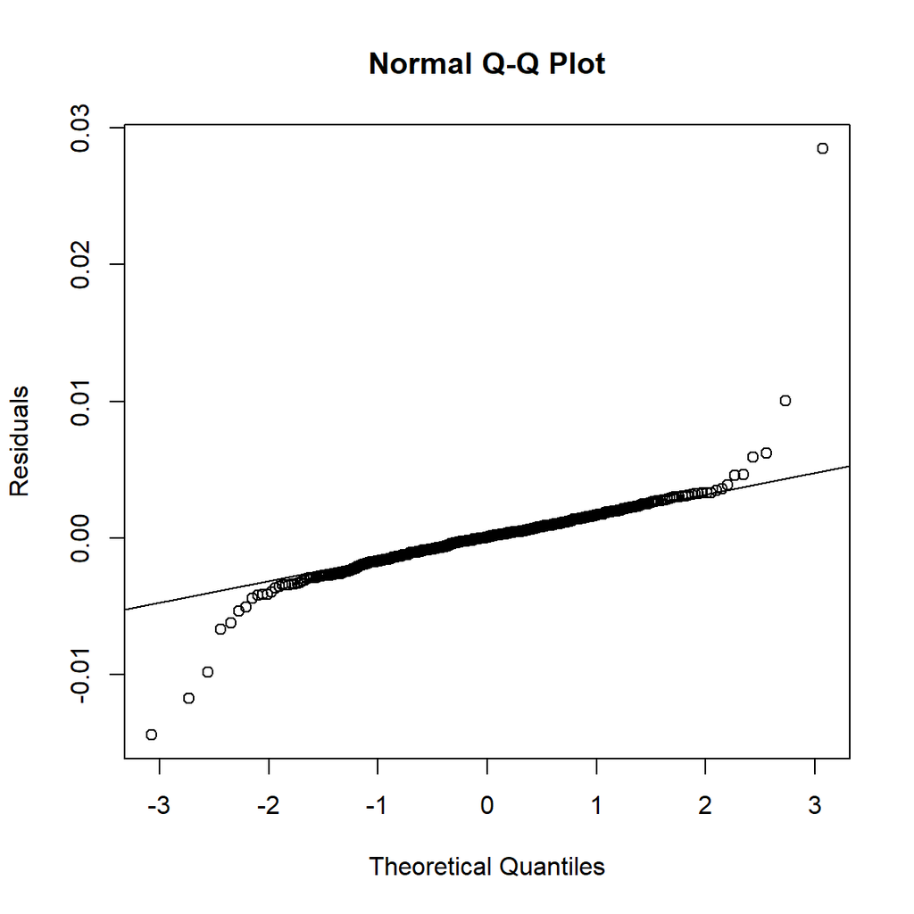

```r
#Q-Q Plot
qqnorm(residuals(lmod_inverse), ylab="Residuals", main="Normal Q-Q Plot")
qqline(residuals(lmod_inverse))
```

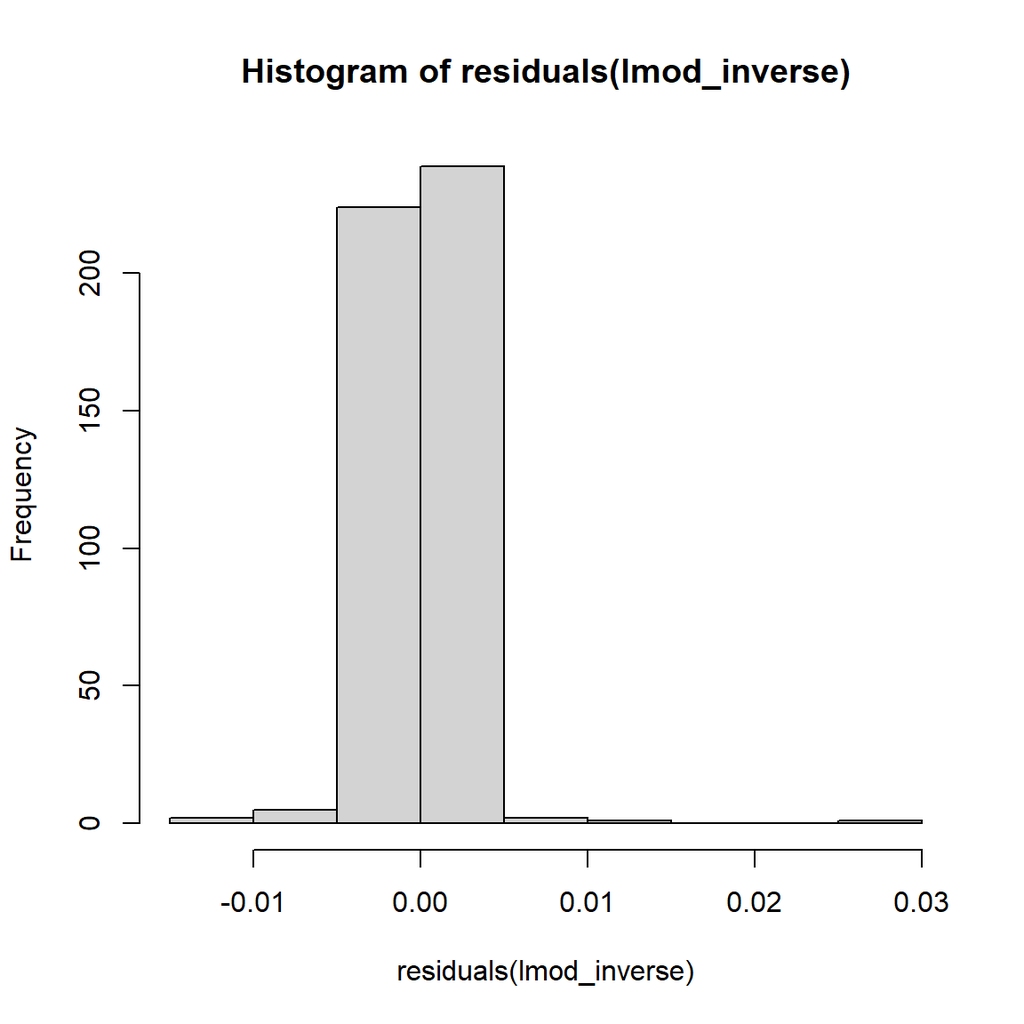

```r
#histogram
hist(residuals(lmod_inverse))
```

**Residual vs Fitted Plot:** Based on this residual vs fitted plot, it looks like the variance is still not constant because there is a pattern within the data points. It still seems like some of the points on the right side of the graph this time are spaced farther apart than the points elsewhere.

**Q-Q Plot:** Based on this Q-Q plot, the residuals still don’t follow a normal distribution. In fact, they have a heavy tail distribution because of where the data points are and because the slope of the line is small.

**Histogram:** Based on this histogram, it seems like the residuals are somewhat normally distributed though because of the bell shaped curve. However, it’s still not completely in the center of the x-axis.

I also tried doing the log and inverse transformations of all of the predictors and the response, but there were some infinity values in the transformed data, so I would get an error. However, I could do the square root transformation of all of the predictors and the response.

```r
sqrt_data <- sqrt(data)
head(sqrt_data)
```

```
##    density  X15      X16      X17       X18      X19      X20       X21
## 1 1.503688 0.80 4.475228 47.38741 0.4935499 8.469489 48.18321 0.5023687
## 2 1.514494 0.76 4.478756 47.52368 0.4943324 7.794248 48.34645 0.5029099
## 3 1.525785 0.72 4.482282 47.66357 0.4951262 7.418020 48.51365 0.5034553
## 4 1.534480 0.68 4.485805 47.80724 0.4959316 7.160365 48.68498 0.5040048
## 5 1.536880 0.64 4.489325 47.95492 0.4967490 6.965956 48.86064 0.5045586
## 6 1.547051 0.60 4.492842 48.10680 0.4975786 6.810666 49.04084 0.5051166
##        X22      X23       X24      X25      X26       X27       X28      X29
## 1 8.814510 49.71683 0.5122915 9.374924 53.23525 0.5227211 10.228753 76.94445
## 2 8.246412 49.90090 0.5125050 8.908122 53.37352 0.5225632  9.876255 76.18643
## 3 7.864126 50.08843 0.5127190 8.538400 53.51286 0.5224055  9.557856 75.42078
## 4 7.579215 50.27955 0.5129334 8.234561 53.65331 0.5222480  9.268390 74.64729
## 5 7.353788 50.47436 0.5131482 7.978093 53.79486 0.5220906  9.003726 73.86570
## 6 7.168251 50.67301 0.5133635 7.757167 53.93754 0.5219333  8.760512 73.07574
##         X30      X31      X32       X33      X34      X35       X36      X37
```

[output cut: 426 more lines]

```r
lmod_transform_sqrt <- lm(density ~ X16 + X17 + X18 + X20 + X22 + X23 + X24 +
    X25 + X26 + X27 + X28 + X29 + X30 + X31 + X32 + X34 + X35 +
    X36 + X38 + X40 + X41 + X43 + X44 + X45 + X46 + X1 + X2 +
    X3 + X4 + X8 + X11 + X13 + X14 + X16.1 + X18.1 + X19.1 +
    X20.1 + X21.1 + X22.1 + X25.1 + X27.1 + X28.1 + X29.1 + X31.1 +
    X33.1 + X34.1 + X35.1 + X37.1 + X38.1 + X39.1 + X41.1 + X42.1 +
    X50 + X51 + X53 + X54 + X56 + X57 + X61 + X63 + X64 + X68 +
    X70 + X72 + X75 + X78 + X80 + X81 + X85 + X86 + X87 + X89 +
    X91 + X93 + X94 + X99 + X106 + X109 + X111 + X112 + X113 +
    X114 + X119 + X120 + X132 + X135 + X141 + X144 + X148 + X149 +
    X150 + X151 + X154 + X157 + X160 + X163 + X164 + X165 + X168 +
    X172 + X175 + X178 + X186 + X187 + X188 + X189 + X198 + X201 +
    X210 + X213 + X214 + X217 + X220 + X223 + X224 + X226 + X229 +
    X233 + X234 + X238 + X240 + X241 + X244 + X250 + X252 + X253 +
    X254 + X255 + X277 + X280 + X283 + X286 + X289 + X293 + X294 +
    X295 + X307 + X309 + X310 + X330 + X331 + X340 + X344 + X345 +
    X346 + X349 + X352 + X357 + X358 + X376 + X391 + X396 + X397 +
    X421 + X426 + X427 + X445 + X464 + X465, data = sqrt_data)
lmod_transform_sqrt
```

```
##
## Call:
## lm(formula = density ~ X16 + X17 + X18 + X20 + X22 + X23 + X24 +
##     X25 + X26 + X27 + X28 + X29 + X30 + X31 + X32 + X34 + X35 +
##     X36 + X38 + X40 + X41 + X43 + X44 + X45 + X46 + X1 + X2 +
##     X3 + X4 + X8 + X11 + X13 + X14 + X16.1 + X18.1 + X19.1 +
##     X20.1 + X21.1 + X22.1 + X25.1 + X27.1 + X28.1 + X29.1 + X31.1 +
##     X33.1 + X34.1 + X35.1 + X37.1 + X38.1 + X39.1 + X41.1 + X42.1 +
##     X50 + X51 + X53 + X54 + X56 + X57 + X61 + X63 + X64 + X68 +
##     X70 + X72 + X75 + X78 + X80 + X81 + X85 + X86 + X87 + X89 +
##     X91 + X93 + X94 + X99 + X106 + X109 + X111 + X112 + X113 +
##     X114 + X119 + X120 + X132 + X135 + X141 + X144 + X148 + X149 +
##     X150 + X151 + X154 + X157 + X160 + X163 + X164 + X165 + X168 +
##     X172 + X175 + X178 + X186 + X187 + X188 + X189 + X198 + X201 +
##     X210 + X213 + X214 + X217 + X220 + X223 + X224 + X226 + X229 +
##     X233 + X234 + X238 + X240 + X241 + X244 + X250 + X252 + X253 +
##     X254 + X255 + X277 + X280 + X283 + X286 + X289 + X293 + X294 +
##     X295 + X307 + X309 + X310 + X330 + X331 + X340 + X344 + X345 +
##     X346 + X349 + X352 + X357 + X358 + X376 + X391 + X396 + X397 +
##     X421 + X426 + X427 + X445 + X464 + X465, data = sqrt_data)
##
## Coefficients:
## (Intercept)          X16          X17          X18          X20          X22
##   1.152e+05   -4.368e-01   -3.636e+03    6.906e+04    1.465e+03    2.687e+03
##         X23          X24          X25          X26          X27          X28
##  -1.221e+03   -2.538e+05   -4.503e+03    9.120e+02    2.385e+05    1.415e+03
##         X29          X30          X31          X32          X34          X35
##   1.268e+02   -5.915e+04   -1.758e+03   -1.203e+02    3.398e+03    1.927e+02
##         X36          X38          X40          X41          X43          X44
##   3.959e+03   -8.210e+01   -5.642e+03   -3.433e+02   -9.877e+02    1.428e+01
##         X45          X46           X1           X2           X3           X4
##   3.028e+04   -6.913e+02    3.609e+00   -4.813e+03   -5.724e+01    1.702e+01
##          X8          X11          X13          X14        X16.1        X18.1
##   8.553e+03   -5.433e+03   -8.204e+00    1.161e+03    5.644e+00   -7.529e+01
##       X19.1        X20.1        X21.1        X22.1        X25.1        X27.1
##  -9.411e+00           NA    7.798e+01    8.268e+00    2.160e+01    1.795e+02
##       X28.1        X29.1        X31.1        X33.1        X34.1        X35.1
##  -1.033e+01    9.101e+02   -1.793e+05    5.666e+03    3.854e+05   -2.789e+03
##       X37.1        X38.1        X39.1        X41.1        X42.1          X50
##  -2.108e+05    5.472e+03   -4.986e+02   -2.558e+03    7.874e+00   -3.661e+03
```

[output cut: 21 more lines]

```
##   1.178e+01    2.627e+03   -5.287e+00   -2.890e+00    2.666e+03   -8.374e+01
##        X238         X240         X241         X244         X250         X252
##  -3.472e+00   -1.783e+01    5.346e-01   -6.792e-01    4.466e+00   -1.616e+01
##        X253         X254         X255         X277         X280         X283
##   1.309e+00   -3.301e+02    7.981e+00   -6.436e+00    9.305e+00   -1.082e+01
##        X286         X289         X293         X294         X295         X307
##   5.042e+00    2.384e+00   -9.802e+02    3.168e+01   -8.148e-02    3.280e-01
##        X309         X310         X330         X331         X340         X344
##   1.737e+00    1.444e-02    1.113e+01    6.434e-01    3.839e+00   -5.548e+02
##        X345         X346         X349         X352         X357         X358
##   1.245e+01    1.929e-01   -2.466e-01    9.479e-02   -2.849e+00   -9.116e-02
##        X376         X391         X396         X397         X421         X426
##  -1.163e+00   -6.848e-03    3.760e+00    1.362e-01    6.046e-03   -1.839e+00
##        X427         X445         X464         X465
##  -6.180e-02   -7.793e-01   -1.559e+01   -3.758e-01
```

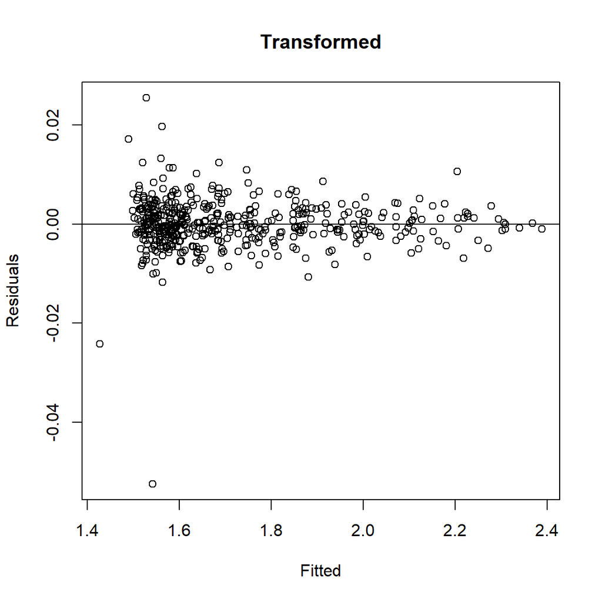

```r
plot(fitted(lmod_transform_sqrt), residuals(lmod_transform_sqrt), xlab="Fitted", ylab="Residuals", main = "Transformed")
abline(h=0)
```

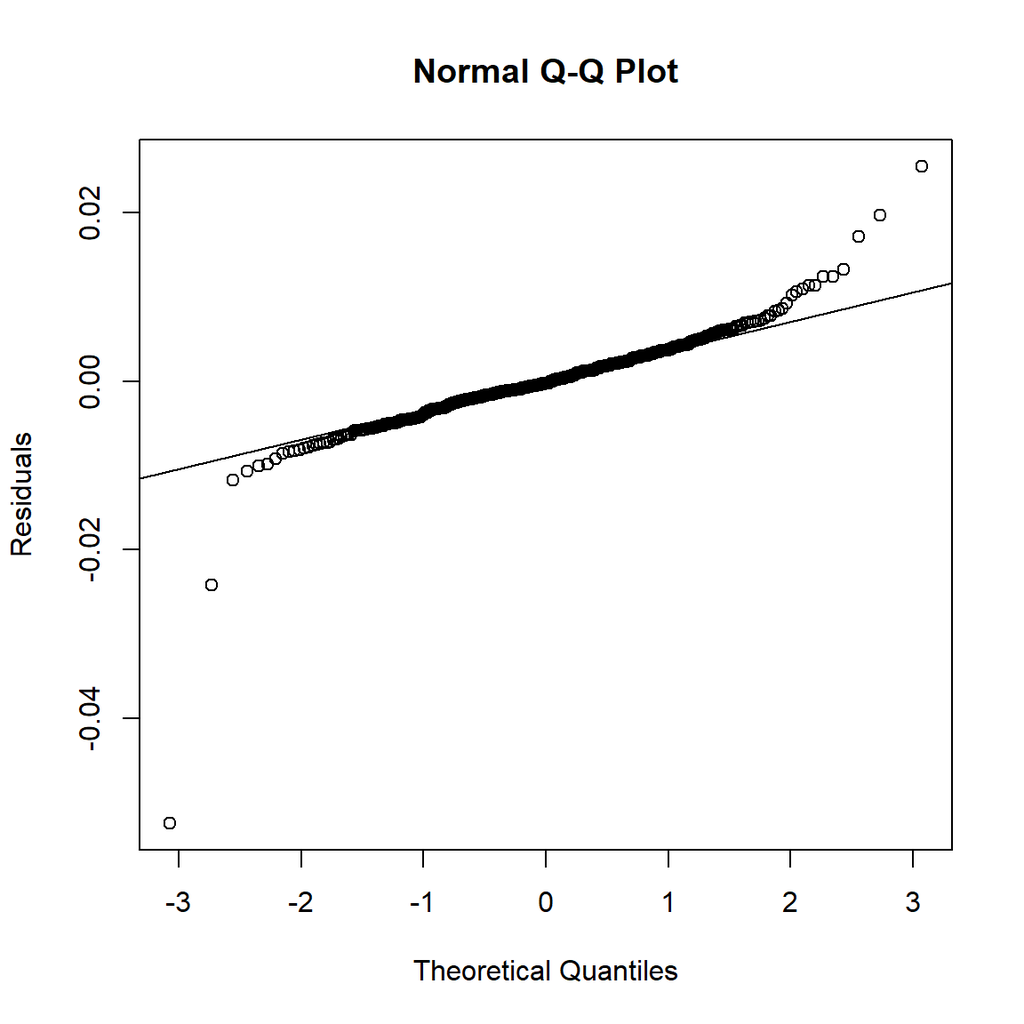

```r
#Q-Q Plot
qqnorm(residuals(lmod_transform_sqrt), ylab="Residuals", main="Normal Q-Q Plot")
qqline(residuals(lmod_transform_sqrt))
```

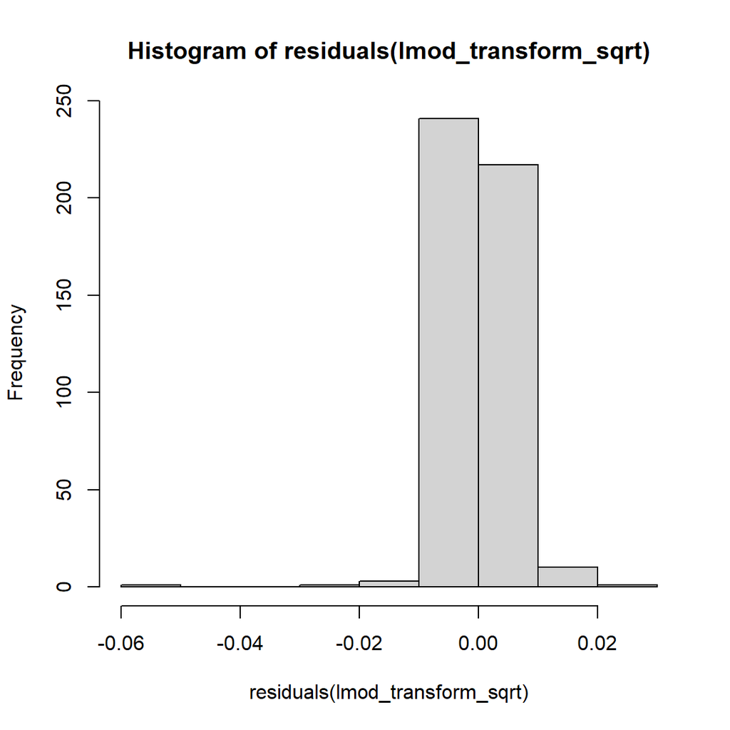

```r
#histogram
hist(residuals(lmod_transform_sqrt))
```

**Residual vs Fitted Plot:** Based on this residual vs fitted plot, it looks like the variance is still not constant because there is a pattern within the data points. It still seems like some of the points on the left side of the graph are spaced farther apart than the points elsewhere. Although, a lot of the other points seem to have spread apart a tiny bit.

**Q-Q Plot:** Based on this Q-Q plot, the residuals still don’t follow a normal distribution. In fact, they have a heavy tail distribution because of where the data points are and because the slope of the line is small.

**Histogram:** Based on this histogram, it seems like the residuals are somewhat normally distributed though because of the bell shaped curve. However, it’s still not really in the center of the x-axis.

**Unfortunately, I couldn’t transform the data to have errors that are normally distributed, constant variance, or for the errors to be independent. Although, it does seem like the data has a linear relationship. So, at least one model assumption is satisfied. Since this is complex real data, it might be harder to get all of these assumptions satisfied.**